```python
import pandas as pd
import numpy as np
import random
from roll import *
import time
```

# Define the problem & uses of roll.py

## Create the Main Roll with its defects

- The length of the roll of dough is set to 500 units.
- The roll has three classes of defects (a, b, and c). The set of defects and their positions on the roll are available in the `defects.csv` file.

All functions and definitions for the roll are in `roll.py`.

```python
#init empty roll of size 500
main_roll = Roll(500)
main_roll.display()
```

```
Total Value :  0
```

|  | 0 | 1 | 2 | 3 | 4 | 5 | 6 | 7 | 8 | 9 | 10 | 11 | 12 | 13 | 14 | 15 | 16 | 17 | 18 | 19 |
| --- | --- | --- | --- | --- | --- | --- | --- | --- | --- | --- | --- | --- | --- | --- | --- | --- | --- | --- | --- | --- |
| 0 | {'a': 0, 'b': 0, 'c': 0} | {'a': 0, 'b': 0, 'c': 0} | {'a': 0, 'b': 0, 'c': 0} | {'a': 0, 'b': 0, 'c': 0} | {'a': 0, 'b': 0, 'c': 0} | {'a': 0, 'b': 0, 'c': 0} | {'a': 0, 'b': 0, 'c': 0} | {'a': 0, 'b': 0, 'c': 0} | {'a': 0, 'b': 0, 'c': 0} | {'a': 0, 'b': 0, 'c': 0} | {'a': 0, 'b': 0, 'c': 0} | {'a': 0, 'b': 0, 'c': 0} | {'a': 0, 'b': 0, 'c': 0} | {'a': 0, 'b': 0, 'c': 0} | {'a': 0, 'b': 0, 'c': 0} | {'a': 0, 'b': 0, 'c': 0} | {'a': 0, 'b': 0, 'c': 0} | {'a': 0, 'b': 0, 'c': 0} | {'a': 0, 'b': 0, 'c': 0} | {'a': 0, 'b': 0, 'c': 0} |
| 1 | _ | _ | _ | _ | _ | _ | _ | _ | _ | _ | _ | _ | _ | _ | _ | _ | _ | _ | _ | _ |

|  | 20 | 21 | 22 | 23 | 24 | 25 | 26 | 27 | 28 | 29 | 30 | 31 | 32 | 33 | 34 | 35 | 36 | 37 | 38 | 39 |
| --- | --- | --- | --- | --- | --- | --- | --- | --- | --- | --- | --- | --- | --- | --- | --- | --- | --- | --- | --- | --- |
| 0 | {'a': 0, 'b': 0, 'c': 0} | {'a': 0, 'b': 0, 'c': 0} | {'a': 0, 'b': 0, 'c': 0} | {'a': 0, 'b': 0, 'c': 0} | {'a': 0, 'b': 0, 'c': 0} | {'a': 0, 'b': 0, 'c': 0} | {'a': 0, 'b': 0, 'c': 0} | {'a': 0, 'b': 0, 'c': 0} | {'a': 0, 'b': 0, 'c': 0} | {'a': 0, 'b': 0, 'c': 0} | {'a': 0, 'b': 0, 'c': 0} | {'a': 0, 'b': 0, 'c': 0} | {'a': 0, 'b': 0, 'c': 0} | {'a': 0, 'b': 0, 'c': 0} | {'a': 0, 'b': 0, 'c': 0} | {'a': 0, 'b': 0, 'c': 0} | {'a': 0, 'b': 0, 'c': 0} | {'a': 0, 'b': 0, 'c': 0} | {'a': 0, 'b': 0, 'c': 0} | {'a': 0, 'b': 0, 'c': 0} |
| 1 | _ | _ | _ | _ | _ | _ | _ | _ | _ | _ | _ | _ | _ | _ | _ | _ | _ | _ | _ | _ |

|  | 40 | 41 | 42 | 43 | 44 | 45 | 46 | 47 | 48 | 49 | 50 | 51 | 52 | 53 | 54 | 55 | 56 | 57 | 58 | 59 |
| --- | --- | --- | --- | --- | --- | --- | --- | --- | --- | --- | --- | --- | --- | --- | --- | --- | --- | --- | --- | --- |
| 0 | {'a': 0, 'b': 0, 'c': 0} | {'a': 0, 'b': 0, 'c': 0} | {'a': 0, 'b': 0, 'c': 0} | {'a': 0, 'b': 0, 'c': 0} | {'a': 0, 'b': 0, 'c': 0} | {'a': 0, 'b': 0, 'c': 0} | {'a': 0, 'b': 0, 'c': 0} | {'a': 0, 'b': 0, 'c': 0} | {'a': 0, 'b': 0, 'c': 0} | {'a': 0, 'b': 0, 'c': 0} | {'a': 0, 'b': 0, 'c': 0} | {'a': 0, 'b': 0, 'c': 0} | {'a': 0, 'b': 0, 'c': 0} | {'a': 0, 'b': 0, 'c': 0} | {'a': 0, 'b': 0, 'c': 0} | {'a': 0, 'b': 0, 'c': 0} | {'a': 0, 'b': 0, 'c': 0} | {'a': 0, 'b': 0, 'c': 0} | {'a': 0, 'b': 0, 'c': 0} | {'a': 0, 'b': 0, 'c': 0} |
| 1 | _ | _ | _ | _ | _ | _ | _ | _ | _ | _ | _ | _ | _ | _ | _ | _ | _ | _ | _ | _ |

|  | 60 | 61 | 62 | 63 | 64 | 65 | 66 | 67 | 68 | 69 | 70 | 71 | 72 | 73 | 74 | 75 | 76 | 77 | 78 | 79 |
| --- | --- | --- | --- | --- | --- | --- | --- | --- | --- | --- | --- | --- | --- | --- | --- | --- | --- | --- | --- | --- |
| 0 | {'a': 0, 'b': 0, 'c': 0} | {'a': 0, 'b': 0, 'c': 0} | {'a': 0, 'b': 0, 'c': 0} | {'a': 0, 'b': 0, 'c': 0} | {'a': 0, 'b': 0, 'c': 0} | {'a': 0, 'b': 0, 'c': 0} | {'a': 0, 'b': 0, 'c': 0} | {'a': 0, 'b': 0, 'c': 0} | {'a': 0, 'b': 0, 'c': 0} | {'a': 0, 'b': 0, 'c': 0} | {'a': 0, 'b': 0, 'c': 0} | {'a': 0, 'b': 0, 'c': 0} | {'a': 0, 'b': 0, 'c': 0} | {'a': 0, 'b': 0, 'c': 0} | {'a': 0, 'b': 0, 'c': 0} | {'a': 0, 'b': 0, 'c': 0} | {'a': 0, 'b': 0, 'c': 0} | {'a': 0, 'b': 0, 'c': 0} | {'a': 0, 'b': 0, 'c': 0} | {'a': 0, 'b': 0, 'c': 0} |
| 1 | _ | _ | _ | _ | _ | _ | _ | _ | _ | _ | _ | _ | _ | _ | _ | _ | _ | _ | _ | _ |

|  | 80 | 81 | 82 | 83 | 84 | 85 | 86 | 87 | 88 | 89 | 90 | 91 | 92 | 93 | 94 | 95 | 96 | 97 | 98 | 99 |
| --- | --- | --- | --- | --- | --- | --- | --- | --- | --- | --- | --- | --- | --- | --- | --- | --- | --- | --- | --- | --- |
| 0 | {'a': 0, 'b': 0, 'c': 0} | {'a': 0, 'b': 0, 'c': 0} | {'a': 0, 'b': 0, 'c': 0} | {'a': 0, 'b': 0, 'c': 0} | {'a': 0, 'b': 0, 'c': 0} | {'a': 0, 'b': 0, 'c': 0} | {'a': 0, 'b': 0, 'c': 0} | {'a': 0, 'b': 0, 'c': 0} | {'a': 0, 'b': 0, 'c': 0} | {'a': 0, 'b': 0, 'c': 0} | {'a': 0, 'b': 0, 'c': 0} | {'a': 0, 'b': 0, 'c': 0} | {'a': 0, 'b': 0, 'c': 0} | {'a': 0, 'b': 0, 'c': 0} | {'a': 0, 'b': 0, 'c': 0} | {'a': 0, 'b': 0, 'c': 0} | {'a': 0, 'b': 0, 'c': 0} | {'a': 0, 'b': 0, 'c': 0} | {'a': 0, 'b': 0, 'c': 0} | {'a': 0, 'b': 0, 'c': 0} |
| 1 | _ | _ | _ | _ | _ | _ | _ | _ | _ | _ | _ | _ | _ | _ | _ | _ | _ | _ | _ | _ |

|  | 100 | 101 | 102 | 103 | 104 | 105 | 106 | 107 | 108 | 109 | 110 | 111 | 112 | 113 | 114 | 115 | 116 | 117 | 118 | 119 |
| --- | --- | --- | --- | --- | --- | --- | --- | --- | --- | --- | --- | --- | --- | --- | --- | --- | --- | --- | --- | --- |
| 0 | {'a': 0, 'b': 0, 'c': 0} | {'a': 0, 'b': 0, 'c': 0} | {'a': 0, 'b': 0, 'c': 0} | {'a': 0, 'b': 0, 'c': 0} | {'a': 0, 'b': 0, 'c': 0} | {'a': 0, 'b': 0, 'c': 0} | {'a': 0, 'b': 0, 'c': 0} | {'a': 0, 'b': 0, 'c': 0} | {'a': 0, 'b': 0, 'c': 0} | {'a': 0, 'b': 0, 'c': 0} | {'a': 0, 'b': 0, 'c': 0} | {'a': 0, 'b': 0, 'c': 0} | {'a': 0, 'b': 0, 'c': 0} | {'a': 0, 'b': 0, 'c': 0} | {'a': 0, 'b': 0, 'c': 0} | {'a': 0, 'b': 0, 'c': 0} | {'a': 0, 'b': 0, 'c': 0} | {'a': 0, 'b': 0, 'c': 0} | {'a': 0, 'b': 0, 'c': 0} | {'a': 0, 'b': 0, 'c': 0} |
| 1 | _ | _ | _ | _ | _ | _ | _ | _ | _ | _ | _ | _ | _ | _ | _ | _ | _ | _ | _ | _ |

|  | 120 | 121 | 122 | 123 | 124 | 125 | 126 | 127 | 128 | 129 | 130 | 131 | 132 | 133 | 134 | 135 | 136 | 137 | 138 | 139 |
| --- | --- | --- | --- | --- | --- | --- | --- | --- | --- | --- | --- | --- | --- | --- | --- | --- | --- | --- | --- | --- |
| 0 | {'a': 0, 'b': 0, 'c': 0} | {'a': 0, 'b': 0, 'c': 0} | {'a': 0, 'b': 0, 'c': 0} | {'a': 0, 'b': 0, 'c': 0} | {'a': 0, 'b': 0, 'c': 0} | {'a': 0, 'b': 0, 'c': 0} | {'a': 0, 'b': 0, 'c': 0} | {'a': 0, 'b': 0, 'c': 0} | {'a': 0, 'b': 0, 'c': 0} | {'a': 0, 'b': 0, 'c': 0} | {'a': 0, 'b': 0, 'c': 0} | {'a': 0, 'b': 0, 'c': 0} | {'a': 0, 'b': 0, 'c': 0} | {'a': 0, 'b': 0, 'c': 0} | {'a': 0, 'b': 0, 'c': 0} | {'a': 0, 'b': 0, 'c': 0} | {'a': 0, 'b': 0, 'c': 0} | {'a': 0, 'b': 0, 'c': 0} | {'a': 0, 'b': 0, 'c': 0} | {'a': 0, 'b': 0, 'c': 0} |
| 1 | _ | _ | _ | _ | _ | _ | _ | _ | _ | _ | _ | _ | _ | _ | _ | _ | _ | _ | _ | _ |

|  | 140 | 141 | 142 | 143 | 144 | 145 | 146 | 147 | 148 | 149 | 150 | 151 | 152 | 153 | 154 | 155 | 156 | 157 | 158 | 159 |
| --- | --- | --- | --- | --- | --- | --- | --- | --- | --- | --- | --- | --- | --- | --- | --- | --- | --- | --- | --- | --- |
| 0 | {'a': 0, 'b': 0, 'c': 0} | {'a': 0, 'b': 0, 'c': 0} | {'a': 0, 'b': 0, 'c': 0} | {'a': 0, 'b': 0, 'c': 0} | {'a': 0, 'b': 0, 'c': 0} | {'a': 0, 'b': 0, 'c': 0} | {'a': 0, 'b': 0, 'c': 0} | {'a': 0, 'b': 0, 'c': 0} | {'a': 0, 'b': 0, 'c': 0} | {'a': 0, 'b': 0, 'c': 0} | {'a': 0, 'b': 0, 'c': 0} | {'a': 0, 'b': 0, 'c': 0} | {'a': 0, 'b': 0, 'c': 0} | {'a': 0, 'b': 0, 'c': 0} | {'a': 0, 'b': 0, 'c': 0} | {'a': 0, 'b': 0, 'c': 0} | {'a': 0, 'b': 0, 'c': 0} | {'a': 0, 'b': 0, 'c': 0} | {'a': 0, 'b': 0, 'c': 0} | {'a': 0, 'b': 0, 'c': 0} |
| 1 | _ | _ | _ | _ | _ | _ | _ | _ | _ | _ | _ | _ | _ | _ | _ | _ | _ | _ | _ | _ |

|  | 160 | 161 | 162 | 163 | 164 | 165 | 166 | 167 | 168 | 169 | 170 | 171 | 172 | 173 | 174 | 175 | 176 | 177 | 178 | 179 |
| --- | --- | --- | --- | --- | --- | --- | --- | --- | --- | --- | --- | --- | --- | --- | --- | --- | --- | --- | --- | --- |
| 0 | {'a': 0, 'b': 0, 'c': 0} | {'a': 0, 'b': 0, 'c': 0} | {'a': 0, 'b': 0, 'c': 0} | {'a': 0, 'b': 0, 'c': 0} | {'a': 0, 'b': 0, 'c': 0} | {'a': 0, 'b': 0, 'c': 0} | {'a': 0, 'b': 0, 'c': 0} | {'a': 0, 'b': 0, 'c': 0} | {'a': 0, 'b': 0, 'c': 0} | {'a': 0, 'b': 0, 'c': 0} | {'a': 0, 'b': 0, 'c': 0} | {'a': 0, 'b': 0, 'c': 0} | {'a': 0, 'b': 0, 'c': 0} | {'a': 0, 'b': 0, 'c': 0} | {'a': 0, 'b': 0, 'c': 0} | {'a': 0, 'b': 0, 'c': 0} | {'a': 0, 'b': 0, 'c': 0} | {'a': 0, 'b': 0, 'c': 0} | {'a': 0, 'b': 0, 'c': 0} | {'a': 0, 'b': 0, 'c': 0} |
| 1 | _ | _ | _ | _ | _ | _ | _ | _ | _ | _ | _ | _ | _ | _ | _ | _ | _ | _ | _ | _ |

|  | 180 | 181 | 182 | 183 | 184 | 185 | 186 | 187 | 188 | 189 | 190 | 191 | 192 | 193 | 194 | 195 | 196 | 197 | 198 | 199 |
| --- | --- | --- | --- | --- | --- | --- | --- | --- | --- | --- | --- | --- | --- | --- | --- | --- | --- | --- | --- | --- |
| 0 | {'a': 0, 'b': 0, 'c': 0} | {'a': 0, 'b': 0, 'c': 0} | {'a': 0, 'b': 0, 'c': 0} | {'a': 0, 'b': 0, 'c': 0} | {'a': 0, 'b': 0, 'c': 0} | {'a': 0, 'b': 0, 'c': 0} | {'a': 0, 'b': 0, 'c': 0} | {'a': 0, 'b': 0, 'c': 0} | {'a': 0, 'b': 0, 'c': 0} | {'a': 0, 'b': 0, 'c': 0} | {'a': 0, 'b': 0, 'c': 0} | {'a': 0, 'b': 0, 'c': 0} | {'a': 0, 'b': 0, 'c': 0} | {'a': 0, 'b': 0, 'c': 0} | {'a': 0, 'b': 0, 'c': 0} | {'a': 0, 'b': 0, 'c': 0} | {'a': 0, 'b': 0, 'c': 0} | {'a': 0, 'b': 0, 'c': 0} | {'a': 0, 'b': 0, 'c': 0} | {'a': 0, 'b': 0, 'c': 0} |
| 1 | _ | _ | _ | _ | _ | _ | _ | _ | _ | _ | _ | _ | _ | _ | _ | _ | _ | _ | _ | _ |

|  | 200 | 201 | 202 | 203 | 204 | 205 | 206 | 207 | 208 | 209 | 210 | 211 | 212 | 213 | 214 | 215 | 216 | 217 | 218 | 219 |
| --- | --- | --- | --- | --- | --- | --- | --- | --- | --- | --- | --- | --- | --- | --- | --- | --- | --- | --- | --- | --- |
| 0 | {'a': 0, 'b': 0, 'c': 0} | {'a': 0, 'b': 0, 'c': 0} | {'a': 0, 'b': 0, 'c': 0} | {'a': 0, 'b': 0, 'c': 0} | {'a': 0, 'b': 0, 'c': 0} | {'a': 0, 'b': 0, 'c': 0} | {'a': 0, 'b': 0, 'c': 0} | {'a': 0, 'b': 0, 'c': 0} | {'a': 0, 'b': 0, 'c': 0} | {'a': 0, 'b': 0, 'c': 0} | {'a': 0, 'b': 0, 'c': 0} | {'a': 0, 'b': 0, 'c': 0} | {'a': 0, 'b': 0, 'c': 0} | {'a': 0, 'b': 0, 'c': 0} | {'a': 0, 'b': 0, 'c': 0} | {'a': 0, 'b': 0, 'c': 0} | {'a': 0, 'b': 0, 'c': 0} | {'a': 0, 'b': 0, 'c': 0} | {'a': 0, 'b': 0, 'c': 0} | {'a': 0, 'b': 0, 'c': 0} |
| 1 | _ | _ | _ | _ | _ | _ | _ | _ | _ | _ | _ | _ | _ | _ | _ | _ | _ | _ | _ | _ |

|  | 220 | 221 | 222 | 223 | 224 | 225 | 226 | 227 | 228 | 229 | 230 | 231 | 232 | 233 | 234 | 235 | 236 | 237 | 238 | 239 |
| --- | --- | --- | --- | --- | --- | --- | --- | --- | --- | --- | --- | --- | --- | --- | --- | --- | --- | --- | --- | --- |
| 0 | {'a': 0, 'b': 0, 'c': 0} | {'a': 0, 'b': 0, 'c': 0} | {'a': 0, 'b': 0, 'c': 0} | {'a': 0, 'b': 0, 'c': 0} | {'a': 0, 'b': 0, 'c': 0} | {'a': 0, 'b': 0, 'c': 0} | {'a': 0, 'b': 0, 'c': 0} | {'a': 0, 'b': 0, 'c': 0} | {'a': 0, 'b': 0, 'c': 0} | {'a': 0, 'b': 0, 'c': 0} | {'a': 0, 'b': 0, 'c': 0} | {'a': 0, 'b': 0, 'c': 0} | {'a': 0, 'b': 0, 'c': 0} | {'a': 0, 'b': 0, 'c': 0} | {'a': 0, 'b': 0, 'c': 0} | {'a': 0, 'b': 0, 'c': 0} | {'a': 0, 'b': 0, 'c': 0} | {'a': 0, 'b': 0, 'c': 0} | {'a': 0, 'b': 0, 'c': 0} | {'a': 0, 'b': 0, 'c': 0} |
| 1 | _ | _ | _ | _ | _ | _ | _ | _ | _ | _ | _ | _ | _ | _ | _ | _ | _ | _ | _ | _ |

|  | 240 | 241 | 242 | 243 | 244 | 245 | 246 | 247 | 248 | 249 | 250 | 251 | 252 | 253 | 254 | 255 | 256 | 257 | 258 | 259 |
| --- | --- | --- | --- | --- | --- | --- | --- | --- | --- | --- | --- | --- | --- | --- | --- | --- | --- | --- | --- | --- |
| 0 | {'a': 0, 'b': 0, 'c': 0} | {'a': 0, 'b': 0, 'c': 0} | {'a': 0, 'b': 0, 'c': 0} | {'a': 0, 'b': 0, 'c': 0} | {'a': 0, 'b': 0, 'c': 0} | {'a': 0, 'b': 0, 'c': 0} | {'a': 0, 'b': 0, 'c': 0} | {'a': 0, 'b': 0, 'c': 0} | {'a': 0, 'b': 0, 'c': 0} | {'a': 0, 'b': 0, 'c': 0} | {'a': 0, 'b': 0, 'c': 0} | {'a': 0, 'b': 0, 'c': 0} | {'a': 0, 'b': 0, 'c': 0} | {'a': 0, 'b': 0, 'c': 0} | {'a': 0, 'b': 0, 'c': 0} | {'a': 0, 'b': 0, 'c': 0} | {'a': 0, 'b': 0, 'c': 0} | {'a': 0, 'b': 0, 'c': 0} | {'a': 0, 'b': 0, 'c': 0} | {'a': 0, 'b': 0, 'c': 0} |
| 1 | _ | _ | _ | _ | _ | _ | _ | _ | _ | _ | _ | _ | _ | _ | _ | _ | _ | _ | _ | _ |

|  | 260 | 261 | 262 | 263 | 264 | 265 | 266 | 267 | 268 | 269 | 270 | 271 | 272 | 273 | 274 | 275 | 276 | 277 | 278 | 279 |
| --- | --- | --- | --- | --- | --- | --- | --- | --- | --- | --- | --- | --- | --- | --- | --- | --- | --- | --- | --- | --- |
| 0 | {'a': 0, 'b': 0, 'c': 0} | {'a': 0, 'b': 0, 'c': 0} | {'a': 0, 'b': 0, 'c': 0} | {'a': 0, 'b': 0, 'c': 0} | {'a': 0, 'b': 0, 'c': 0} | {'a': 0, 'b': 0, 'c': 0} | {'a': 0, 'b': 0, 'c': 0} | {'a': 0, 'b': 0, 'c': 0} | {'a': 0, 'b': 0, 'c': 0} | {'a': 0, 'b': 0, 'c': 0} | {'a': 0, 'b': 0, 'c': 0} | {'a': 0, 'b': 0, 'c': 0} | {'a': 0, 'b': 0, 'c': 0} | {'a': 0, 'b': 0, 'c': 0} | {'a': 0, 'b': 0, 'c': 0} | {'a': 0, 'b': 0, 'c': 0} | {'a': 0, 'b': 0, 'c': 0} | {'a': 0, 'b': 0, 'c': 0} | {'a': 0, 'b': 0, 'c': 0} | {'a': 0, 'b': 0, 'c': 0} |
| 1 | _ | _ | _ | _ | _ | _ | _ | _ | _ | _ | _ | _ | _ | _ | _ | _ | _ | _ | _ | _ |

|  | 280 | 281 | 282 | 283 | 284 | 285 | 286 | 287 | 288 | 289 | 290 | 291 | 292 | 293 | 294 | 295 | 296 | 297 | 298 | 299 |
| --- | --- | --- | --- | --- | --- | --- | --- | --- | --- | --- | --- | --- | --- | --- | --- | --- | --- | --- | --- | --- |
| 0 | {'a': 0, 'b': 0, 'c': 0} | {'a': 0, 'b': 0, 'c': 0} | {'a': 0, 'b': 0, 'c': 0} | {'a': 0, 'b': 0, 'c': 0} | {'a': 0, 'b': 0, 'c': 0} | {'a': 0, 'b': 0, 'c': 0} | {'a': 0, 'b': 0, 'c': 0} | {'a': 0, 'b': 0, 'c': 0} | {'a': 0, 'b': 0, 'c': 0} | {'a': 0, 'b': 0, 'c': 0} | {'a': 0, 'b': 0, 'c': 0} | {'a': 0, 'b': 0, 'c': 0} | {'a': 0, 'b': 0, 'c': 0} | {'a': 0, 'b': 0, 'c': 0} | {'a': 0, 'b': 0, 'c': 0} | {'a': 0, 'b': 0, 'c': 0} | {'a': 0, 'b': 0, 'c': 0} | {'a': 0, 'b': 0, 'c': 0} | {'a': 0, 'b': 0, 'c': 0} | {'a': 0, 'b': 0, 'c': 0} |
| 1 | _ | _ | _ | _ | _ | _ | _ | _ | _ | _ | _ | _ | _ | _ | _ | _ | _ | _ | _ | _ |

|  | 300 | 301 | 302 | 303 | 304 | 305 | 306 | 307 | 308 | 309 | 310 | 311 | 312 | 313 | 314 | 315 | 316 | 317 | 318 | 319 |
| --- | --- | --- | --- | --- | --- | --- | --- | --- | --- | --- | --- | --- | --- | --- | --- | --- | --- | --- | --- | --- |
| 0 | {'a': 0, 'b': 0, 'c': 0} | {'a': 0, 'b': 0, 'c': 0} | {'a': 0, 'b': 0, 'c': 0} | {'a': 0, 'b': 0, 'c': 0} | {'a': 0, 'b': 0, 'c': 0} | {'a': 0, 'b': 0, 'c': 0} | {'a': 0, 'b': 0, 'c': 0} | {'a': 0, 'b': 0, 'c': 0} | {'a': 0, 'b': 0, 'c': 0} | {'a': 0, 'b': 0, 'c': 0} | {'a': 0, 'b': 0, 'c': 0} | {'a': 0, 'b': 0, 'c': 0} | {'a': 0, 'b': 0, 'c': 0} | {'a': 0, 'b': 0, 'c': 0} | {'a': 0, 'b': 0, 'c': 0} | {'a': 0, 'b': 0, 'c': 0} | {'a': 0, 'b': 0, 'c': 0} | {'a': 0, 'b': 0, 'c': 0} | {'a': 0, 'b': 0, 'c': 0} | {'a': 0, 'b': 0, 'c': 0} |
| 1 | _ | _ | _ | _ | _ | _ | _ | _ | _ | _ | _ | _ | _ | _ | _ | _ | _ | _ | _ | _ |

|  | 320 | 321 | 322 | 323 | 324 | 325 | 326 | 327 | 328 | 329 | 330 | 331 | 332 | 333 | 334 | 335 | 336 | 337 | 338 | 339 |
| --- | --- | --- | --- | --- | --- | --- | --- | --- | --- | --- | --- | --- | --- | --- | --- | --- | --- | --- | --- | --- |
| 0 | {'a': 0, 'b': 0, 'c': 0} | {'a': 0, 'b': 0, 'c': 0} | {'a': 0, 'b': 0, 'c': 0} | {'a': 0, 'b': 0, 'c': 0} | {'a': 0, 'b': 0, 'c': 0} | {'a': 0, 'b': 0, 'c': 0} | {'a': 0, 'b': 0, 'c': 0} | {'a': 0, 'b': 0, 'c': 0} | {'a': 0, 'b': 0, 'c': 0} | {'a': 0, 'b': 0, 'c': 0} | {'a': 0, 'b': 0, 'c': 0} | {'a': 0, 'b': 0, 'c': 0} | {'a': 0, 'b': 0, 'c': 0} | {'a': 0, 'b': 0, 'c': 0} | {'a': 0, 'b': 0, 'c': 0} | {'a': 0, 'b': 0, 'c': 0} | {'a': 0, 'b': 0, 'c': 0} | {'a': 0, 'b': 0, 'c': 0} | {'a': 0, 'b': 0, 'c': 0} | {'a': 0, 'b': 0, 'c': 0} |
| 1 | _ | _ | _ | _ | _ | _ | _ | _ | _ | _ | _ | _ | _ | _ | _ | _ | _ | _ | _ | _ |

|  | 340 | 341 | 342 | 343 | 344 | 345 | 346 | 347 | 348 | 349 | 350 | 351 | 352 | 353 | 354 | 355 | 356 | 357 | 358 | 359 |
| --- | --- | --- | --- | --- | --- | --- | --- | --- | --- | --- | --- | --- | --- | --- | --- | --- | --- | --- | --- | --- |
| 0 | {'a': 0, 'b': 0, 'c': 0} | {'a': 0, 'b': 0, 'c': 0} | {'a': 0, 'b': 0, 'c': 0} | {'a': 0, 'b': 0, 'c': 0} | {'a': 0, 'b': 0, 'c': 0} | {'a': 0, 'b': 0, 'c': 0} | {'a': 0, 'b': 0, 'c': 0} | {'a': 0, 'b': 0, 'c': 0} | {'a': 0, 'b': 0, 'c': 0} | {'a': 0, 'b': 0, 'c': 0} | {'a': 0, 'b': 0, 'c': 0} | {'a': 0, 'b': 0, 'c': 0} | {'a': 0, 'b': 0, 'c': 0} | {'a': 0, 'b': 0, 'c': 0} | {'a': 0, 'b': 0, 'c': 0} | {'a': 0, 'b': 0, 'c': 0} | {'a': 0, 'b': 0, 'c': 0} | {'a': 0, 'b': 0, 'c': 0} | {'a': 0, 'b': 0, 'c': 0} | {'a': 0, 'b': 0, 'c': 0} |
| 1 | _ | _ | _ | _ | _ | _ | _ | _ | _ | _ | _ | _ | _ | _ | _ | _ | _ | _ | _ | _ |

|  | 360 | 361 | 362 | 363 | 364 | 365 | 366 | 367 | 368 | 369 | 370 | 371 | 372 | 373 | 374 | 375 | 376 | 377 | 378 | 379 |
| --- | --- | --- | --- | --- | --- | --- | --- | --- | --- | --- | --- | --- | --- | --- | --- | --- | --- | --- | --- | --- |
| 0 | {'a': 0, 'b': 0, 'c': 0} | {'a': 0, 'b': 0, 'c': 0} | {'a': 0, 'b': 0, 'c': 0} | {'a': 0, 'b': 0, 'c': 0} | {'a': 0, 'b': 0, 'c': 0} | {'a': 0, 'b': 0, 'c': 0} | {'a': 0, 'b': 0, 'c': 0} | {'a': 0, 'b': 0, 'c': 0} | {'a': 0, 'b': 0, 'c': 0} | {'a': 0, 'b': 0, 'c': 0} | {'a': 0, 'b': 0, 'c': 0} | {'a': 0, 'b': 0, 'c': 0} | {'a': 0, 'b': 0, 'c': 0} | {'a': 0, 'b': 0, 'c': 0} | {'a': 0, 'b': 0, 'c': 0} | {'a': 0, 'b': 0, 'c': 0} | {'a': 0, 'b': 0, 'c': 0} | {'a': 0, 'b': 0, 'c': 0} | {'a': 0, 'b': 0, 'c': 0} | {'a': 0, 'b': 0, 'c': 0} |
| 1 | _ | _ | _ | _ | _ | _ | _ | _ | _ | _ | _ | _ | _ | _ | _ | _ | _ | _ | _ | _ |

|  | 380 | 381 | 382 | 383 | 384 | 385 | 386 | 387 | 388 | 389 | 390 | 391 | 392 | 393 | 394 | 395 | 396 | 397 | 398 | 399 |
| --- | --- | --- | --- | --- | --- | --- | --- | --- | --- | --- | --- | --- | --- | --- | --- | --- | --- | --- | --- | --- |
| 0 | {'a': 0, 'b': 0, 'c': 0} | {'a': 0, 'b': 0, 'c': 0} | {'a': 0, 'b': 0, 'c': 0} | {'a': 0, 'b': 0, 'c': 0} | {'a': 0, 'b': 0, 'c': 0} | {'a': 0, 'b': 0, 'c': 0} | {'a': 0, 'b': 0, 'c': 0} | {'a': 0, 'b': 0, 'c': 0} | {'a': 0, 'b': 0, 'c': 0} | {'a': 0, 'b': 0, 'c': 0} | {'a': 0, 'b': 0, 'c': 0} | {'a': 0, 'b': 0, 'c': 0} | {'a': 0, 'b': 0, 'c': 0} | {'a': 0, 'b': 0, 'c': 0} | {'a': 0, 'b': 0, 'c': 0} | {'a': 0, 'b': 0, 'c': 0} | {'a': 0, 'b': 0, 'c': 0} | {'a': 0, 'b': 0, 'c': 0} | {'a': 0, 'b': 0, 'c': 0} | {'a': 0, 'b': 0, 'c': 0} |
| 1 | _ | _ | _ | _ | _ | _ | _ | _ | _ | _ | _ | _ | _ | _ | _ | _ | _ | _ | _ | _ |

|  | 400 | 401 | 402 | 403 | 404 | 405 | 406 | 407 | 408 | 409 | 410 | 411 | 412 | 413 | 414 | 415 | 416 | 417 | 418 | 419 |
| --- | --- | --- | --- | --- | --- | --- | --- | --- | --- | --- | --- | --- | --- | --- | --- | --- | --- | --- | --- | --- |
| 0 | {'a': 0, 'b': 0, 'c': 0} | {'a': 0, 'b': 0, 'c': 0} | {'a': 0, 'b': 0, 'c': 0} | {'a': 0, 'b': 0, 'c': 0} | {'a': 0, 'b': 0, 'c': 0} | {'a': 0, 'b': 0, 'c': 0} | {'a': 0, 'b': 0, 'c': 0} | {'a': 0, 'b': 0, 'c': 0} | {'a': 0, 'b': 0, 'c': 0} | {'a': 0, 'b': 0, 'c': 0} | {'a': 0, 'b': 0, 'c': 0} | {'a': 0, 'b': 0, 'c': 0} | {'a': 0, 'b': 0, 'c': 0} | {'a': 0, 'b': 0, 'c': 0} | {'a': 0, 'b': 0, 'c': 0} | {'a': 0, 'b': 0, 'c': 0} | {'a': 0, 'b': 0, 'c': 0} | {'a': 0, 'b': 0, 'c': 0} | {'a': 0, 'b': 0, 'c': 0} | {'a': 0, 'b': 0, 'c': 0} |
| 1 | _ | _ | _ | _ | _ | _ | _ | _ | _ | _ | _ | _ | _ | _ | _ | _ | _ | _ | _ | _ |

|  | 420 | 421 | 422 | 423 | 424 | 425 | 426 | 427 | 428 | 429 | 430 | 431 | 432 | 433 | 434 | 435 | 436 | 437 | 438 | 439 |
| --- | --- | --- | --- | --- | --- | --- | --- | --- | --- | --- | --- | --- | --- | --- | --- | --- | --- | --- | --- | --- |
| 0 | {'a': 0, 'b': 0, 'c': 0} | {'a': 0, 'b': 0, 'c': 0} | {'a': 0, 'b': 0, 'c': 0} | {'a': 0, 'b': 0, 'c': 0} | {'a': 0, 'b': 0, 'c': 0} | {'a': 0, 'b': 0, 'c': 0} | {'a': 0, 'b': 0, 'c': 0} | {'a': 0, 'b': 0, 'c': 0} | {'a': 0, 'b': 0, 'c': 0} | {'a': 0, 'b': 0, 'c': 0} | {'a': 0, 'b': 0, 'c': 0} | {'a': 0, 'b': 0, 'c': 0} | {'a': 0, 'b': 0, 'c': 0} | {'a': 0, 'b': 0, 'c': 0} | {'a': 0, 'b': 0, 'c': 0} | {'a': 0, 'b': 0, 'c': 0} | {'a': 0, 'b': 0, 'c': 0} | {'a': 0, 'b': 0, 'c': 0} | {'a': 0, 'b': 0, 'c': 0} | {'a': 0, 'b': 0, 'c': 0} |
| 1 | _ | _ | _ | _ | _ | _ | _ | _ | _ | _ | _ | _ | _ | _ | _ | _ | _ | _ | _ | _ |

|  | 440 | 441 | 442 | 443 | 444 | 445 | 446 | 447 | 448 | 449 | 450 | 451 | 452 | 453 | 454 | 455 | 456 | 457 | 458 | 459 |
| --- | --- | --- | --- | --- | --- | --- | --- | --- | --- | --- | --- | --- | --- | --- | --- | --- | --- | --- | --- | --- |
| 0 | {'a': 0, 'b': 0, 'c': 0} | {'a': 0, 'b': 0, 'c': 0} | {'a': 0, 'b': 0, 'c': 0} | {'a': 0, 'b': 0, 'c': 0} | {'a': 0, 'b': 0, 'c': 0} | {'a': 0, 'b': 0, 'c': 0} | {'a': 0, 'b': 0, 'c': 0} | {'a': 0, 'b': 0, 'c': 0} | {'a': 0, 'b': 0, 'c': 0} | {'a': 0, 'b': 0, 'c': 0} | {'a': 0, 'b': 0, 'c': 0} | {'a': 0, 'b': 0, 'c': 0} | {'a': 0, 'b': 0, 'c': 0} | {'a': 0, 'b': 0, 'c': 0} | {'a': 0, 'b': 0, 'c': 0} | {'a': 0, 'b': 0, 'c': 0} | {'a': 0, 'b': 0, 'c': 0} | {'a': 0, 'b': 0, 'c': 0} | {'a': 0, 'b': 0, 'c': 0} | {'a': 0, 'b': 0, 'c': 0} |
| 1 | _ | _ | _ | _ | _ | _ | _ | _ | _ | _ | _ | _ | _ | _ | _ | _ | _ | _ | _ | _ |

|  | 460 | 461 | 462 | 463 | 464 | 465 | 466 | 467 | 468 | 469 | 470 | 471 | 472 | 473 | 474 | 475 | 476 | 477 | 478 | 479 |
| --- | --- | --- | --- | --- | --- | --- | --- | --- | --- | --- | --- | --- | --- | --- | --- | --- | --- | --- | --- | --- |
| 0 | {'a': 0, 'b': 0, 'c': 0} | {'a': 0, 'b': 0, 'c': 0} | {'a': 0, 'b': 0, 'c': 0} | {'a': 0, 'b': 0, 'c': 0} | {'a': 0, 'b': 0, 'c': 0} | {'a': 0, 'b': 0, 'c': 0} | {'a': 0, 'b': 0, 'c': 0} | {'a': 0, 'b': 0, 'c': 0} | {'a': 0, 'b': 0, 'c': 0} | {'a': 0, 'b': 0, 'c': 0} | {'a': 0, 'b': 0, 'c': 0} | {'a': 0, 'b': 0, 'c': 0} | {'a': 0, 'b': 0, 'c': 0} | {'a': 0, 'b': 0, 'c': 0} | {'a': 0, 'b': 0, 'c': 0} | {'a': 0, 'b': 0, 'c': 0} | {'a': 0, 'b': 0, 'c': 0} | {'a': 0, 'b': 0, 'c': 0} | {'a': 0, 'b': 0, 'c': 0} | {'a': 0, 'b': 0, 'c': 0} |
| 1 | _ | _ | _ | _ | _ | _ | _ | _ | _ | _ | _ | _ | _ | _ | _ | _ | _ | _ | _ | _ |

|  | 480 | 481 | 482 | 483 | 484 | 485 | 486 | 487 | 488 | 489 | 490 | 491 | 492 | 493 | 494 | 495 | 496 | 497 | 498 | 499 |
| --- | --- | --- | --- | --- | --- | --- | --- | --- | --- | --- | --- | --- | --- | --- | --- | --- | --- | --- | --- | --- |
| 0 | {'a': 0, 'b': 0, 'c': 0} | {'a': 0, 'b': 0, 'c': 0} | {'a': 0, 'b': 0, 'c': 0} | {'a': 0, 'b': 0, 'c': 0} | {'a': 0, 'b': 0, 'c': 0} | {'a': 0, 'b': 0, 'c': 0} | {'a': 0, 'b': 0, 'c': 0} | {'a': 0, 'b': 0, 'c': 0} | {'a': 0, 'b': 0, 'c': 0} | {'a': 0, 'b': 0, 'c': 0} | {'a': 0, 'b': 0, 'c': 0} | {'a': 0, 'b': 0, 'c': 0} | {'a': 0, 'b': 0, 'c': 0} | {'a': 0, 'b': 0, 'c': 0} | {'a': 0, 'b': 0, 'c': 0} | {'a': 0, 'b': 0, 'c': 0} | {'a': 0, 'b': 0, 'c': 0} | {'a': 0, 'b': 0, 'c': 0} | {'a': 0, 'b': 0, 'c': 0} | {'a': 0, 'b': 0, 'c': 0} |
| 1 | _ | _ | _ | _ | _ | _ | _ | _ | _ | _ | _ | _ | _ | _ | _ | _ | _ | _ | _ | _ |

Just to understand the displaying:

- total values is just the sum of value of each biscuits in the roll.
- index 0 is for the defects, '_' means no defects at this position.
- index 1 is for the biscuits, '_' means no biscuits at this position.

```python
#get the defects of the roll of dough
defect = pd.read_csv('defects.csv')
defect.head()
```

|  | x | class |
| --- | --- | --- |
| 0 | 355.449335 | c |
| 1 | 92.496236 | a |
| 2 | 141.876795 | c |
| 3 | 431.833902 | c |
| 4 | 435.028461 | c |

Actually, pos x of defects can be a float.

But in our case, because positions of biscuits are integer,

we can simplify the problem by taking the integral part of the positions x of defects :

```python
defect['x'] = defect['x'].astype(int)
defect.head()
```

|  | x | class |
| --- | --- | --- |
| 0 | 355 | c |
| 1 | 92 | a |
| 2 | 141 | c |
| 3 | 431 | c |
| 4 | 435 | c |

```python
#Now we can place defects in our main roll
for i in range(defect.shape[0]):
    main_roll.addDefect(defect['class'].iloc[i], defect['x'].iloc[i])
main_roll.display()
```

```
Total Value :  0
```

|  | 0 | 1 | 2 | 3 | 4 | 5 | 6 | 7 | 8 | 9 | 10 | 11 | 12 | 13 | 14 | 15 | 16 | 17 | 18 | 19 |
| --- | --- | --- | --- | --- | --- | --- | --- | --- | --- | --- | --- | --- | --- | --- | --- | --- | --- | --- | --- | --- |
| 0 | {'a': 2, 'b': 0, 'c': 0} | {'a': 1, 'b': 0, 'c': 0} | {'a': 1, 'b': 1, 'c': 0} | {'a': 1, 'b': 1, 'c': 0} | {'a': 0, 'b': 0, 'c': 0} | {'a': 0, 'b': 0, 'c': 0} | {'a': 0, 'b': 0, 'c': 0} | {'a': 0, 'b': 0, 'c': 0} | {'a': 0, 'b': 0, 'c': 1} | {'a': 0, 'b': 0, 'c': 2} | {'a': 0, 'b': 1, 'c': 1} | {'a': 0, 'b': 0, 'c': 0} | {'a': 1, 'b': 0, 'c': 0} | {'a': 0, 'b': 0, 'c': 0} | {'a': 1, 'b': 0, 'c': 0} | {'a': 0, 'b': 0, 'c': 0} | {'a': 1, 'b': 0, 'c': 1} | {'a': 0, 'b': 0, 'c': 0} | {'a': 0, 'b': 0, 'c': 0} | {'a': 0, 'b': 1, 'c': 0} |
| 1 | _ | _ | _ | _ | _ | _ | _ | _ | _ | _ | _ | _ | _ | _ | _ | _ | _ | _ | _ | _ |

|  | 20 | 21 | 22 | 23 | 24 | 25 | 26 | 27 | 28 | 29 | 30 | 31 | 32 | 33 | 34 | 35 | 36 | 37 | 38 | 39 |
| --- | --- | --- | --- | --- | --- | --- | --- | --- | --- | --- | --- | --- | --- | --- | --- | --- | --- | --- | --- | --- |
| 0 | {'a': 0, 'b': 0, 'c': 0} | {'a': 0, 'b': 1, 'c': 0} | {'a': 1, 'b': 1, 'c': 0} | {'a': 2, 'b': 0, 'c': 0} | {'a': 0, 'b': 0, 'c': 0} | {'a': 1, 'b': 0, 'c': 0} | {'a': 1, 'b': 0, 'c': 1} | {'a': 0, 'b': 0, 'c': 0} | {'a': 0, 'b': 0, 'c': 0} | {'a': 1, 'b': 0, 'c': 0} | {'a': 0, 'b': 1, 'c': 0} | {'a': 0, 'b': 0, 'c': 0} | {'a': 1, 'b': 0, 'c': 0} | {'a': 0, 'b': 1, 'c': 0} | {'a': 0, 'b': 1, 'c': 0} | {'a': 0, 'b': 1, 'c': 1} | {'a': 1, 'b': 1, 'c': 0} | {'a': 0, 'b': 1, 'c': 0} | {'a': 1, 'b': 0, 'c': 0} | {'a': 0, 'b': 0, 'c': 2} |
| 1 | _ | _ | _ | _ | _ | _ | _ | _ | _ | _ | _ | _ | _ | _ | _ | _ | _ | _ | _ | _ |

|  | 40 | 41 | 42 | 43 | 44 | 45 | 46 | 47 | 48 | 49 | 50 | 51 | 52 | 53 | 54 | 55 | 56 | 57 | 58 | 59 |
| --- | --- | --- | --- | --- | --- | --- | --- | --- | --- | --- | --- | --- | --- | --- | --- | --- | --- | --- | --- | --- |
| 0 | {'a': 0, 'b': 0, 'c': 2} | {'a': 0, 'b': 0, 'c': 1} | {'a': 0, 'b': 0, 'c': 0} | {'a': 0, 'b': 0, 'c': 0} | {'a': 1, 'b': 1, 'c': 0} | {'a': 0, 'b': 0, 'c': 0} | {'a': 1, 'b': 1, 'c': 0} | {'a': 0, 'b': 0, 'c': 1} | {'a': 1, 'b': 1, 'c': 0} | {'a': 0, 'b': 0, 'c': 1} | {'a': 0, 'b': 0, 'c': 1} | {'a': 1, 'b': 1, 'c': 2} | {'a': 0, 'b': 0, 'c': 0} | {'a': 1, 'b': 0, 'c': 0} | {'a': 0, 'b': 1, 'c': 0} | {'a': 1, 'b': 0, 'c': 1} | {'a': 0, 'b': 0, 'c': 0} | {'a': 0, 'b': 0, 'c': 1} | {'a': 1, 'b': 0, 'c': 0} | {'a': 1, 'b': 1, 'c': 2} |
| 1 | _ | _ | _ | _ | _ | _ | _ | _ | _ | _ | _ | _ | _ | _ | _ | _ | _ | _ | _ | _ |

|  | 60 | 61 | 62 | 63 | 64 | 65 | 66 | 67 | 68 | 69 | 70 | 71 | 72 | 73 | 74 | 75 | 76 | 77 | 78 | 79 |
| --- | --- | --- | --- | --- | --- | --- | --- | --- | --- | --- | --- | --- | --- | --- | --- | --- | --- | --- | --- | --- |
| 0 | {'a': 0, 'b': 0, 'c': 0} | {'a': 0, 'b': 0, 'c': 0} | {'a': 0, 'b': 0, 'c': 0} | {'a': 0, 'b': 0, 'c': 0} | {'a': 0, 'b': 0, 'c': 1} | {'a': 0, 'b': 0, 'c': 1} | {'a': 0, 'b': 0, 'c': 0} | {'a': 0, 'b': 0, 'c': 0} | {'a': 0, 'b': 1, 'c': 1} | {'a': 1, 'b': 0, 'c': 0} | {'a': 0, 'b': 0, 'c': 0} | {'a': 0, 'b': 0, 'c': 0} | {'a': 0, 'b': 2, 'c': 1} | {'a': 1, 'b': 0, 'c': 0} | {'a': 0, 'b': 0, 'c': 2} | {'a': 0, 'b': 0, 'c': 0} | {'a': 1, 'b': 0, 'c': 0} | {'a': 2, 'b': 0, 'c': 0} | {'a': 0, 'b': 0, 'c': 0} | {'a': 0, 'b': 0, 'c': 0} |
| 1 | _ | _ | _ | _ | _ | _ | _ | _ | _ | _ | _ | _ | _ | _ | _ | _ | _ | _ | _ | _ |

|  | 80 | 81 | 82 | 83 | 84 | 85 | 86 | 87 | 88 | 89 | 90 | 91 | 92 | 93 | 94 | 95 | 96 | 97 | 98 | 99 |
| --- | --- | --- | --- | --- | --- | --- | --- | --- | --- | --- | --- | --- | --- | --- | --- | --- | --- | --- | --- | --- |
| 0 | {'a': 0, 'b': 0, 'c': 0} | {'a': 0, 'b': 0, 'c': 0} | {'a': 0, 'b': 2, 'c': 1} | {'a': 1, 'b': 1, 'c': 1} | {'a': 0, 'b': 0, 'c': 1} | {'a': 2, 'b': 0, 'c': 0} | {'a': 0, 'b': 0, 'c': 0} | {'a': 0, 'b': 0, 'c': 0} | {'a': 0, 'b': 0, 'c': 0} | {'a': 0, 'b': 0, 'c': 1} | {'a': 0, 'b': 0, 'c': 0} | {'a': 0, 'b': 0, 'c': 1} | {'a': 1, 'b': 0, 'c': 0} | {'a': 2, 'b': 0, 'c': 0} | {'a': 0, 'b': 0, 'c': 1} | {'a': 1, 'b': 0, 'c': 1} | {'a': 0, 'b': 1, 'c': 0} | {'a': 0, 'b': 0, 'c': 3} | {'a': 0, 'b': 0, 'c': 2} | {'a': 0, 'b': 0, 'c': 0} |
| 1 | _ | _ | _ | _ | _ | _ | _ | _ | _ | _ | _ | _ | _ | _ | _ | _ | _ | _ | _ | _ |

|  | 100 | 101 | 102 | 103 | 104 | 105 | 106 | 107 | 108 | 109 | 110 | 111 | 112 | 113 | 114 | 115 | 116 | 117 | 118 | 119 |
| --- | --- | --- | --- | --- | --- | --- | --- | --- | --- | --- | --- | --- | --- | --- | --- | --- | --- | --- | --- | --- |
| 0 | {'a': 0, 'b': 0, 'c': 0} | {'a': 0, 'b': 0, 'c': 0} | {'a': 0, 'b': 0, 'c': 1} | {'a': 1, 'b': 0, 'c': 0} | {'a': 0, 'b': 0, 'c': 0} | {'a': 0, 'b': 0, 'c': 0} | {'a': 0, 'b': 0, 'c': 0} | {'a': 1, 'b': 1, 'c': 1} | {'a': 1, 'b': 0, 'c': 0} | {'a': 0, 'b': 0, 'c': 0} | {'a': 0, 'b': 0, 'c': 2} | {'a': 0, 'b': 0, 'c': 0} | {'a': 1, 'b': 0, 'c': 0} | {'a': 0, 'b': 0, 'c': 2} | {'a': 0, 'b': 0, 'c': 0} | {'a': 0, 'b': 0, 'c': 1} | {'a': 1, 'b': 1, 'c': 1} | {'a': 2, 'b': 1, 'c': 0} | {'a': 2, 'b': 0, 'c': 0} | {'a': 1, 'b': 0, 'c': 0} |
| 1 | _ | _ | _ | _ | _ | _ | _ | _ | _ | _ | _ | _ | _ | _ | _ | _ | _ | _ | _ | _ |

|  | 120 | 121 | 122 | 123 | 124 | 125 | 126 | 127 | 128 | 129 | 130 | 131 | 132 | 133 | 134 | 135 | 136 | 137 | 138 | 139 |
| --- | --- | --- | --- | --- | --- | --- | --- | --- | --- | --- | --- | --- | --- | --- | --- | --- | --- | --- | --- | --- |
| 0 | {'a': 0, 'b': 0, 'c': 1} | {'a': 0, 'b': 0, 'c': 1} | {'a': 0, 'b': 1, 'c': 0} | {'a': 0, 'b': 1, 'c': 1} | {'a': 1, 'b': 0, 'c': 0} | {'a': 3, 'b': 0, 'c': 1} | {'a': 0, 'b': 0, 'c': 0} | {'a': 0, 'b': 1, 'c': 0} | {'a': 0, 'b': 0, 'c': 1} | {'a': 0, 'b': 1, 'c': 1} | {'a': 0, 'b': 0, 'c': 0} | {'a': 0, 'b': 0, 'c': 0} | {'a': 0, 'b': 0, 'c': 0} | {'a': 0, 'b': 0, 'c': 0} | {'a': 0, 'b': 0, 'c': 0} | {'a': 0, 'b': 0, 'c': 0} | {'a': 0, 'b': 0, 'c': 1} | {'a': 0, 'b': 0, 'c': 1} | {'a': 0, 'b': 0, 'c': 0} | {'a': 0, 'b': 1, 'c': 1} |
| 1 | _ | _ | _ | _ | _ | _ | _ | _ | _ | _ | _ | _ | _ | _ | _ | _ | _ | _ | _ | _ |

|  | 140 | 141 | 142 | 143 | 144 | 145 | 146 | 147 | 148 | 149 | 150 | 151 | 152 | 153 | 154 | 155 | 156 | 157 | 158 | 159 |
| --- | --- | --- | --- | --- | --- | --- | --- | --- | --- | --- | --- | --- | --- | --- | --- | --- | --- | --- | --- | --- |
| 0 | {'a': 1, 'b': 0, 'c': 0} | {'a': 0, 'b': 1, 'c': 1} | {'a': 0, 'b': 0, 'c': 1} | {'a': 2, 'b': 0, 'c': 1} | {'a': 1, 'b': 0, 'c': 0} | {'a': 0, 'b': 0, 'c': 1} | {'a': 0, 'b': 1, 'c': 1} | {'a': 0, 'b': 0, 'c': 0} | {'a': 0, 'b': 1, 'c': 0} | {'a': 0, 'b': 0, 'c': 1} | {'a': 0, 'b': 0, 'c': 1} | {'a': 0, 'b': 0, 'c': 0} | {'a': 0, 'b': 0, 'c': 0} | {'a': 0, 'b': 1, 'c': 0} | {'a': 1, 'b': 1, 'c': 1} | {'a': 0, 'b': 0, 'c': 0} | {'a': 1, 'b': 1, 'c': 0} | {'a': 0, 'b': 3, 'c': 0} | {'a': 1, 'b': 0, 'c': 0} | {'a': 1, 'b': 0, 'c': 1} |
| 1 | _ | _ | _ | _ | _ | _ | _ | _ | _ | _ | _ | _ | _ | _ | _ | _ | _ | _ | _ | _ |

|  | 160 | 161 | 162 | 163 | 164 | 165 | 166 | 167 | 168 | 169 | 170 | 171 | 172 | 173 | 174 | 175 | 176 | 177 | 178 | 179 |
| --- | --- | --- | --- | --- | --- | --- | --- | --- | --- | --- | --- | --- | --- | --- | --- | --- | --- | --- | --- | --- |
| 0 | {'a': 0, 'b': 0, 'c': 0} | {'a': 0, 'b': 1, 'c': 0} | {'a': 0, 'b': 0, 'c': 0} | {'a': 3, 'b': 1, 'c': 1} | {'a': 0, 'b': 0, 'c': 0} | {'a': 0, 'b': 0, 'c': 1} | {'a': 1, 'b': 3, 'c': 0} | {'a': 0, 'b': 0, 'c': 0} | {'a': 0, 'b': 2, 'c': 0} | {'a': 1, 'b': 0, 'c': 0} | {'a': 0, 'b': 0, 'c': 0} | {'a': 1, 'b': 1, 'c': 1} | {'a': 1, 'b': 0, 'c': 1} | {'a': 0, 'b': 1, 'c': 0} | {'a': 0, 'b': 0, 'c': 1} | {'a': 0, 'b': 0, 'c': 0} | {'a': 0, 'b': 1, 'c': 0} | {'a': 0, 'b': 0, 'c': 0} | {'a': 0, 'b': 0, 'c': 2} | {'a': 0, 'b': 2, 'c': 1} |
| 1 | _ | _ | _ | _ | _ | _ | _ | _ | _ | _ | _ | _ | _ | _ | _ | _ | _ | _ | _ | _ |

|  | 180 | 181 | 182 | 183 | 184 | 185 | 186 | 187 | 188 | 189 | 190 | 191 | 192 | 193 | 194 | 195 | 196 | 197 | 198 | 199 |
| --- | --- | --- | --- | --- | --- | --- | --- | --- | --- | --- | --- | --- | --- | --- | --- | --- | --- | --- | --- | --- |
| 0 | {'a': 0, 'b': 0, 'c': 0} | {'a': 0, 'b': 0, 'c': 0} | {'a': 0, 'b': 0, 'c': 0} | {'a': 0, 'b': 0, 'c': 1} | {'a': 0, 'b': 3, 'c': 3} | {'a': 0, 'b': 1, 'c': 0} | {'a': 0, 'b': 1, 'c': 0} | {'a': 0, 'b': 1, 'c': 0} | {'a': 3, 'b': 0, 'c': 0} | {'a': 1, 'b': 0, 'c': 0} | {'a': 1, 'b': 1, 'c': 0} | {'a': 0, 'b': 1, 'c': 1} | {'a': 0, 'b': 1, 'c': 0} | {'a': 0, 'b': 0, 'c': 0} | {'a': 0, 'b': 0, 'c': 1} | {'a': 0, 'b': 0, 'c': 0} | {'a': 0, 'b': 0, 'c': 1} | {'a': 0, 'b': 0, 'c': 0} | {'a': 0, 'b': 0, 'c': 1} | {'a': 0, 'b': 0, 'c': 0} |
| 1 | _ | _ | _ | _ | _ | _ | _ | _ | _ | _ | _ | _ | _ | _ | _ | _ | _ | _ | _ | _ |

|  | 200 | 201 | 202 | 203 | 204 | 205 | 206 | 207 | 208 | 209 | 210 | 211 | 212 | 213 | 214 | 215 | 216 | 217 | 218 | 219 |
| --- | --- | --- | --- | --- | --- | --- | --- | --- | --- | --- | --- | --- | --- | --- | --- | --- | --- | --- | --- | --- |
| 0 | {'a': 0, 'b': 1, 'c': 0} | {'a': 0, 'b': 0, 'c': 1} | {'a': 0, 'b': 0, 'c': 0} | {'a': 1, 'b': 0, 'c': 1} | {'a': 0, 'b': 0, 'c': 0} | {'a': 2, 'b': 0, 'c': 0} | {'a': 0, 'b': 0, 'c': 1} | {'a': 0, 'b': 0, 'c': 0} | {'a': 0, 'b': 0, 'c': 0} | {'a': 0, 'b': 1, 'c': 1} | {'a': 0, 'b': 0, 'c': 1} | {'a': 0, 'b': 0, 'c': 0} | {'a': 1, 'b': 0, 'c': 0} | {'a': 0, 'b': 1, 'c': 0} | {'a': 1, 'b': 1, 'c': 1} | {'a': 0, 'b': 0, 'c': 0} | {'a': 1, 'b': 1, 'c': 1} | {'a': 0, 'b': 0, 'c': 0} | {'a': 1, 'b': 0, 'c': 0} | {'a': 0, 'b': 0, 'c': 0} |
| 1 | _ | _ | _ | _ | _ | _ | _ | _ | _ | _ | _ | _ | _ | _ | _ | _ | _ | _ | _ | _ |

|  | 220 | 221 | 222 | 223 | 224 | 225 | 226 | 227 | 228 | 229 | 230 | 231 | 232 | 233 | 234 | 235 | 236 | 237 | 238 | 239 |
| --- | --- | --- | --- | --- | --- | --- | --- | --- | --- | --- | --- | --- | --- | --- | --- | --- | --- | --- | --- | --- |
| 0 | {'a': 0, 'b': 0, 'c': 0} | {'a': 0, 'b': 1, 'c': 0} | {'a': 0, 'b': 0, 'c': 0} | {'a': 1, 'b': 0, 'c': 0} | {'a': 0, 'b': 0, 'c': 0} | {'a': 0, 'b': 0, 'c': 0} | {'a': 0, 'b': 0, 'c': 0} | {'a': 1, 'b': 1, 'c': 0} | {'a': 0, 'b': 0, 'c': 1} | {'a': 0, 'b': 0, 'c': 0} | {'a': 1, 'b': 0, 'c': 0} | {'a': 0, 'b': 0, 'c': 1} | {'a': 0, 'b': 0, 'c': 0} | {'a': 0, 'b': 0, 'c': 0} | {'a': 0, 'b': 1, 'c': 1} | {'a': 0, 'b': 1, 'c': 0} | {'a': 0, 'b': 0, 'c': 0} | {'a': 0, 'b': 0, 'c': 0} | {'a': 0, 'b': 0, 'c': 0} | {'a': 0, 'b': 0, 'c': 0} |
| 1 | _ | _ | _ | _ | _ | _ | _ | _ | _ | _ | _ | _ | _ | _ | _ | _ | _ | _ | _ | _ |

|  | 240 | 241 | 242 | 243 | 244 | 245 | 246 | 247 | 248 | 249 | 250 | 251 | 252 | 253 | 254 | 255 | 256 | 257 | 258 | 259 |
| --- | --- | --- | --- | --- | --- | --- | --- | --- | --- | --- | --- | --- | --- | --- | --- | --- | --- | --- | --- | --- |
| 0 | {'a': 0, 'b': 0, 'c': 1} | {'a': 0, 'b': 3, 'c': 1} | {'a': 3, 'b': 1, 'c': 0} | {'a': 0, 'b': 0, 'c': 0} | {'a': 0, 'b': 0, 'c': 1} | {'a': 0, 'b': 1, 'c': 0} | {'a': 1, 'b': 0, 'c': 1} | {'a': 0, 'b': 0, 'c': 1} | {'a': 0, 'b': 1, 'c': 1} | {'a': 0, 'b': 0, 'c': 0} | {'a': 0, 'b': 0, 'c': 0} | {'a': 1, 'b': 1, 'c': 0} | {'a': 0, 'b': 0, 'c': 0} | {'a': 1, 'b': 0, 'c': 1} | {'a': 0, 'b': 0, 'c': 0} | {'a': 0, 'b': 0, 'c': 1} | {'a': 0, 'b': 0, 'c': 0} | {'a': 0, 'b': 1, 'c': 1} | {'a': 0, 'b': 1, 'c': 0} | {'a': 0, 'b': 1, 'c': 0} |
| 1 | _ | _ | _ | _ | _ | _ | _ | _ | _ | _ | _ | _ | _ | _ | _ | _ | _ | _ | _ | _ |

|  | 260 | 261 | 262 | 263 | 264 | 265 | 266 | 267 | 268 | 269 | 270 | 271 | 272 | 273 | 274 | 275 | 276 | 277 | 278 | 279 |
| --- | --- | --- | --- | --- | --- | --- | --- | --- | --- | --- | --- | --- | --- | --- | --- | --- | --- | --- | --- | --- |
| 0 | {'a': 0, 'b': 0, 'c': 1} | {'a': 0, 'b': 0, 'c': 0} | {'a': 0, 'b': 0, 'c': 0} | {'a': 0, 'b': 0, 'c': 0} | {'a': 0, 'b': 0, 'c': 1} | {'a': 0, 'b': 0, 'c': 1} | {'a': 0, 'b': 0, 'c': 0} | {'a': 0, 'b': 1, 'c': 0} | {'a': 0, 'b': 0, 'c': 0} | {'a': 0, 'b': 1, 'c': 0} | {'a': 1, 'b': 1, 'c': 0} | {'a': 0, 'b': 0, 'c': 0} | {'a': 0, 'b': 1, 'c': 0} | {'a': 0, 'b': 0, 'c': 1} | {'a': 0, 'b': 0, 'c': 0} | {'a': 2, 'b': 2, 'c': 0} | {'a': 1, 'b': 0, 'c': 0} | {'a': 1, 'b': 0, 'c': 1} | {'a': 0, 'b': 0, 'c': 0} | {'a': 1, 'b': 0, 'c': 1} |
| 1 | _ | _ | _ | _ | _ | _ | _ | _ | _ | _ | _ | _ | _ | _ | _ | _ | _ | _ | _ | _ |

|  | 280 | 281 | 282 | 283 | 284 | 285 | 286 | 287 | 288 | 289 | 290 | 291 | 292 | 293 | 294 | 295 | 296 | 297 | 298 | 299 |
| --- | --- | --- | --- | --- | --- | --- | --- | --- | --- | --- | --- | --- | --- | --- | --- | --- | --- | --- | --- | --- |
| 0 | {'a': 2, 'b': 0, 'c': 0} | {'a': 0, 'b': 1, 'c': 0} | {'a': 0, 'b': 0, 'c': 1} | {'a': 0, 'b': 0, 'c': 1} | {'a': 1, 'b': 1, 'c': 0} | {'a': 0, 'b': 1, 'c': 0} | {'a': 0, 'b': 0, 'c': 0} | {'a': 0, 'b': 0, 'c': 0} | {'a': 1, 'b': 0, 'c': 0} | {'a': 1, 'b': 1, 'c': 0} | {'a': 0, 'b': 0, 'c': 0} | {'a': 0, 'b': 1, 'c': 0} | {'a': 0, 'b': 1, 'c': 1} | {'a': 0, 'b': 1, 'c': 1} | {'a': 1, 'b': 2, 'c': 0} | {'a': 0, 'b': 0, 'c': 0} | {'a': 0, 'b': 1, 'c': 0} | {'a': 0, 'b': 0, 'c': 0} | {'a': 0, 'b': 0, 'c': 0} | {'a': 0, 'b': 0, 'c': 1} |
| 1 | _ | _ | _ | _ | _ | _ | _ | _ | _ | _ | _ | _ | _ | _ | _ | _ | _ | _ | _ | _ |

|  | 300 | 301 | 302 | 303 | 304 | 305 | 306 | 307 | 308 | 309 | 310 | 311 | 312 | 313 | 314 | 315 | 316 | 317 | 318 | 319 |
| --- | --- | --- | --- | --- | --- | --- | --- | --- | --- | --- | --- | --- | --- | --- | --- | --- | --- | --- | --- | --- |
| 0 | {'a': 0, 'b': 0, 'c': 1} | {'a': 1, 'b': 1, 'c': 1} | {'a': 1, 'b': 1, 'c': 0} | {'a': 0, 'b': 0, 'c': 0} | {'a': 1, 'b': 1, 'c': 1} | {'a': 0, 'b': 0, 'c': 0} | {'a': 0, 'b': 0, 'c': 1} | {'a': 0, 'b': 0, 'c': 0} | {'a': 0, 'b': 0, 'c': 1} | {'a': 0, 'b': 0, 'c': 0} | {'a': 0, 'b': 1, 'c': 0} | {'a': 0, 'b': 0, 'c': 1} | {'a': 0, 'b': 0, 'c': 1} | {'a': 1, 'b': 0, 'c': 0} | {'a': 2, 'b': 0, 'c': 0} | {'a': 0, 'b': 1, 'c': 0} | {'a': 0, 'b': 0, 'c': 1} | {'a': 0, 'b': 0, 'c': 1} | {'a': 0, 'b': 0, 'c': 1} | {'a': 0, 'b': 0, 'c': 0} |
| 1 | _ | _ | _ | _ | _ | _ | _ | _ | _ | _ | _ | _ | _ | _ | _ | _ | _ | _ | _ | _ |

|  | 320 | 321 | 322 | 323 | 324 | 325 | 326 | 327 | 328 | 329 | 330 | 331 | 332 | 333 | 334 | 335 | 336 | 337 | 338 | 339 |
| --- | --- | --- | --- | --- | --- | --- | --- | --- | --- | --- | --- | --- | --- | --- | --- | --- | --- | --- | --- | --- |
| 0 | {'a': 0, 'b': 0, 'c': 0} | {'a': 0, 'b': 1, 'c': 0} | {'a': 0, 'b': 0, 'c': 0} | {'a': 0, 'b': 0, 'c': 0} | {'a': 0, 'b': 1, 'c': 0} | {'a': 0, 'b': 0, 'c': 0} | {'a': 0, 'b': 0, 'c': 0} | {'a': 0, 'b': 0, 'c': 0} | {'a': 0, 'b': 0, 'c': 1} | {'a': 1, 'b': 0, 'c': 0} | {'a': 1, 'b': 0, 'c': 0} | {'a': 0, 'b': 0, 'c': 0} | {'a': 1, 'b': 2, 'c': 0} | {'a': 0, 'b': 0, 'c': 0} | {'a': 1, 'b': 1, 'c': 0} | {'a': 0, 'b': 1, 'c': 0} | {'a': 0, 'b': 0, 'c': 0} | {'a': 0, 'b': 0, 'c': 0} | {'a': 0, 'b': 1, 'c': 0} | {'a': 0, 'b': 0, 'c': 0} |
| 1 | _ | _ | _ | _ | _ | _ | _ | _ | _ | _ | _ | _ | _ | _ | _ | _ | _ | _ | _ | _ |

|  | 340 | 341 | 342 | 343 | 344 | 345 | 346 | 347 | 348 | 349 | 350 | 351 | 352 | 353 | 354 | 355 | 356 | 357 | 358 | 359 |
| --- | --- | --- | --- | --- | --- | --- | --- | --- | --- | --- | --- | --- | --- | --- | --- | --- | --- | --- | --- | --- |
| 0 | {'a': 1, 'b': 0, 'c': 0} | {'a': 0, 'b': 0, 'c': 0} | {'a': 0, 'b': 0, 'c': 2} | {'a': 0, 'b': 0, 'c': 0} | {'a': 0, 'b': 1, 'c': 0} | {'a': 0, 'b': 0, 'c': 1} | {'a': 0, 'b': 0, 'c': 0} | {'a': 0, 'b': 1, 'c': 1} | {'a': 1, 'b': 0, 'c': 0} | {'a': 0, 'b': 0, 'c': 0} | {'a': 0, 'b': 0, 'c': 1} | {'a': 0, 'b': 1, 'c': 1} | {'a': 0, 'b': 1, 'c': 0} | {'a': 0, 'b': 1, 'c': 0} | {'a': 0, 'b': 0, 'c': 1} | {'a': 0, 'b': 1, 'c': 2} | {'a': 1, 'b': 0, 'c': 0} | {'a': 0, 'b': 1, 'c': 1} | {'a': 0, 'b': 1, 'c': 0} | {'a': 0, 'b': 0, 'c': 0} |
| 1 | _ | _ | _ | _ | _ | _ | _ | _ | _ | _ | _ | _ | _ | _ | _ | _ | _ | _ | _ | _ |

|  | 360 | 361 | 362 | 363 | 364 | 365 | 366 | 367 | 368 | 369 | 370 | 371 | 372 | 373 | 374 | 375 | 376 | 377 | 378 | 379 |
| --- | --- | --- | --- | --- | --- | --- | --- | --- | --- | --- | --- | --- | --- | --- | --- | --- | --- | --- | --- | --- |
| 0 | {'a': 0, 'b': 1, 'c': 0} | {'a': 0, 'b': 0, 'c': 0} | {'a': 1, 'b': 0, 'c': 1} | {'a': 0, 'b': 1, 'c': 0} | {'a': 1, 'b': 0, 'c': 0} | {'a': 1, 'b': 0, 'c': 0} | {'a': 0, 'b': 0, 'c': 0} | {'a': 1, 'b': 0, 'c': 1} | {'a': 2, 'b': 0, 'c': 0} | {'a': 1, 'b': 0, 'c': 0} | {'a': 0, 'b': 0, 'c': 1} | {'a': 1, 'b': 1, 'c': 0} | {'a': 0, 'b': 0, 'c': 1} | {'a': 1, 'b': 0, 'c': 1} | {'a': 0, 'b': 0, 'c': 1} | {'a': 0, 'b': 0, 'c': 1} | {'a': 0, 'b': 0, 'c': 1} | {'a': 0, 'b': 1, 'c': 0} | {'a': 0, 'b': 0, 'c': 0} | {'a': 0, 'b': 1, 'c': 0} |
| 1 | _ | _ | _ | _ | _ | _ | _ | _ | _ | _ | _ | _ | _ | _ | _ | _ | _ | _ | _ | _ |

|  | 380 | 381 | 382 | 383 | 384 | 385 | 386 | 387 | 388 | 389 | 390 | 391 | 392 | 393 | 394 | 395 | 396 | 397 | 398 | 399 |
| --- | --- | --- | --- | --- | --- | --- | --- | --- | --- | --- | --- | --- | --- | --- | --- | --- | --- | --- | --- | --- |
| 0 | {'a': 1, 'b': 0, 'c': 0} | {'a': 0, 'b': 1, 'c': 1} | {'a': 0, 'b': 1, 'c': 0} | {'a': 0, 'b': 1, 'c': 2} | {'a': 0, 'b': 0, 'c': 0} | {'a': 1, 'b': 0, 'c': 0} | {'a': 0, 'b': 2, 'c': 0} | {'a': 0, 'b': 0, 'c': 0} | {'a': 0, 'b': 0, 'c': 0} | {'a': 0, 'b': 0, 'c': 0} | {'a': 0, 'b': 0, 'c': 1} | {'a': 1, 'b': 1, 'c': 0} | {'a': 1, 'b': 0, 'c': 0} | {'a': 0, 'b': 0, 'c': 0} | {'a': 0, 'b': 0, 'c': 0} | {'a': 0, 'b': 1, 'c': 1} | {'a': 0, 'b': 0, 'c': 0} | {'a': 0, 'b': 0, 'c': 0} | {'a': 0, 'b': 1, 'c': 0} | {'a': 0, 'b': 0, 'c': 0} |
| 1 | _ | _ | _ | _ | _ | _ | _ | _ | _ | _ | _ | _ | _ | _ | _ | _ | _ | _ | _ | _ |

|  | 400 | 401 | 402 | 403 | 404 | 405 | 406 | 407 | 408 | 409 | 410 | 411 | 412 | 413 | 414 | 415 | 416 | 417 | 418 | 419 |
| --- | --- | --- | --- | --- | --- | --- | --- | --- | --- | --- | --- | --- | --- | --- | --- | --- | --- | --- | --- | --- |
| 0 | {'a': 0, 'b': 0, 'c': 0} | {'a': 0, 'b': 1, 'c': 2} | {'a': 0, 'b': 0, 'c': 1} | {'a': 0, 'b': 1, 'c': 0} | {'a': 0, 'b': 0, 'c': 0} | {'a': 1, 'b': 1, 'c': 0} | {'a': 1, 'b': 0, 'c': 1} | {'a': 0, 'b': 0, 'c': 0} | {'a': 1, 'b': 0, 'c': 1} | {'a': 1, 'b': 0, 'c': 0} | {'a': 0, 'b': 2, 'c': 0} | {'a': 0, 'b': 0, 'c': 0} | {'a': 0, 'b': 1, 'c': 1} | {'a': 0, 'b': 1, 'c': 0} | {'a': 1, 'b': 0, 'c': 0} | {'a': 0, 'b': 0, 'c': 1} | {'a': 1, 'b': 0, 'c': 0} | {'a': 0, 'b': 0, 'c': 0} | {'a': 0, 'b': 1, 'c': 0} | {'a': 0, 'b': 0, 'c': 0} |
| 1 | _ | _ | _ | _ | _ | _ | _ | _ | _ | _ | _ | _ | _ | _ | _ | _ | _ | _ | _ | _ |

|  | 420 | 421 | 422 | 423 | 424 | 425 | 426 | 427 | 428 | 429 | 430 | 431 | 432 | 433 | 434 | 435 | 436 | 437 | 438 | 439 |
| --- | --- | --- | --- | --- | --- | --- | --- | --- | --- | --- | --- | --- | --- | --- | --- | --- | --- | --- | --- | --- |
| 0 | {'a': 0, 'b': 0, 'c': 0} | {'a': 0, 'b': 2, 'c': 0} | {'a': 0, 'b': 0, 'c': 1} | {'a': 0, 'b': 0, 'c': 0} | {'a': 0, 'b': 0, 'c': 1} | {'a': 0, 'b': 0, 'c': 0} | {'a': 2, 'b': 1, 'c': 0} | {'a': 0, 'b': 0, 'c': 2} | {'a': 0, 'b': 0, 'c': 0} | {'a': 1, 'b': 1, 'c': 0} | {'a': 1, 'b': 0, 'c': 0} | {'a': 1, 'b': 0, 'c': 1} | {'a': 0, 'b': 0, 'c': 0} | {'a': 0, 'b': 0, 'c': 2} | {'a': 0, 'b': 0, 'c': 0} | {'a': 0, 'b': 0, 'c': 1} | {'a': 0, 'b': 1, 'c': 0} | {'a': 1, 'b': 0, 'c': 1} | {'a': 2, 'b': 0, 'c': 0} | {'a': 0, 'b': 1, 'c': 0} |
| 1 | _ | _ | _ | _ | _ | _ | _ | _ | _ | _ | _ | _ | _ | _ | _ | _ | _ | _ | _ | _ |

|  | 440 | 441 | 442 | 443 | 444 | 445 | 446 | 447 | 448 | 449 | 450 | 451 | 452 | 453 | 454 | 455 | 456 | 457 | 458 | 459 |
| --- | --- | --- | --- | --- | --- | --- | --- | --- | --- | --- | --- | --- | --- | --- | --- | --- | --- | --- | --- | --- |
| 0 | {'a': 1, 'b': 0, 'c': 0} | {'a': 0, 'b': 0, 'c': 0} | {'a': 0, 'b': 0, 'c': 0} | {'a': 1, 'b': 0, 'c': 0} | {'a': 0, 'b': 1, 'c': 1} | {'a': 1, 'b': 0, 'c': 0} | {'a': 2, 'b': 1, 'c': 0} | {'a': 0, 'b': 0, 'c': 1} | {'a': 0, 'b': 0, 'c': 0} | {'a': 1, 'b': 0, 'c': 0} | {'a': 0, 'b': 0, 'c': 0} | {'a': 0, 'b': 0, 'c': 1} | {'a': 0, 'b': 0, 'c': 0} | {'a': 1, 'b': 0, 'c': 0} | {'a': 0, 'b': 0, 'c': 0} | {'a': 0, 'b': 0, 'c': 0} | {'a': 1, 'b': 1, 'c': 1} | {'a': 1, 'b': 0, 'c': 0} | {'a': 0, 'b': 0, 'c': 0} | {'a': 0, 'b': 0, 'c': 0} |
| 1 | _ | _ | _ | _ | _ | _ | _ | _ | _ | _ | _ | _ | _ | _ | _ | _ | _ | _ | _ | _ |

|  | 460 | 461 | 462 | 463 | 464 | 465 | 466 | 467 | 468 | 469 | 470 | 471 | 472 | 473 | 474 | 475 | 476 | 477 | 478 | 479 |
| --- | --- | --- | --- | --- | --- | --- | --- | --- | --- | --- | --- | --- | --- | --- | --- | --- | --- | --- | --- | --- |
| 0 | {'a': 0, 'b': 0, 'c': 1} | {'a': 0, 'b': 0, 'c': 0} | {'a': 1, 'b': 0, 'c': 0} | {'a': 0, 'b': 0, 'c': 0} | {'a': 1, 'b': 0, 'c': 0} | {'a': 0, 'b': 0, 'c': 0} | {'a': 0, 'b': 0, 'c': 0} | {'a': 0, 'b': 0, 'c': 0} | {'a': 0, 'b': 0, 'c': 0} | {'a': 1, 'b': 1, 'c': 1} | {'a': 0, 'b': 0, 'c': 0} | {'a': 0, 'b': 0, 'c': 1} | {'a': 0, 'b': 1, 'c': 0} | {'a': 0, 'b': 0, 'c': 0} | {'a': 0, 'b': 0, 'c': 0} | {'a': 1, 'b': 1, 'c': 0} | {'a': 0, 'b': 0, 'c': 1} | {'a': 1, 'b': 0, 'c': 0} | {'a': 2, 'b': 0, 'c': 0} | {'a': 0, 'b': 0, 'c': 1} |
| 1 | _ | _ | _ | _ | _ | _ | _ | _ | _ | _ | _ | _ | _ | _ | _ | _ | _ | _ | _ | _ |

|  | 480 | 481 | 482 | 483 | 484 | 485 | 486 | 487 | 488 | 489 | 490 | 491 | 492 | 493 | 494 | 495 | 496 | 497 | 498 | 499 |
| --- | --- | --- | --- | --- | --- | --- | --- | --- | --- | --- | --- | --- | --- | --- | --- | --- | --- | --- | --- | --- |
| 0 | {'a': 0, 'b': 1, 'c': 1} | {'a': 1, 'b': 0, 'c': 0} | {'a': 1, 'b': 1, 'c': 0} | {'a': 1, 'b': 0, 'c': 2} | {'a': 2, 'b': 2, 'c': 0} | {'a': 0, 'b': 0, 'c': 0} | {'a': 0, 'b': 0, 'c': 0} | {'a': 0, 'b': 0, 'c': 1} | {'a': 1, 'b': 0, 'c': 0} | {'a': 1, 'b': 0, 'c': 0} | {'a': 0, 'b': 0, 'c': 1} | {'a': 0, 'b': 1, 'c': 0} | {'a': 0, 'b': 1, 'c': 0} | {'a': 0, 'b': 1, 'c': 0} | {'a': 0, 'b': 0, 'c': 0} | {'a': 0, 'b': 0, 'c': 0} | {'a': 1, 'b': 1, 'c': 0} | {'a': 1, 'b': 0, 'c': 0} | {'a': 0, 'b': 0, 'c': 1} | {'a': 0, 'b': 0, 'c': 1} |
| 1 | _ | _ | _ | _ | _ | _ | _ | _ | _ | _ | _ | _ | _ | _ | _ | _ | _ | _ | _ | _ |

```python
main_roll.getNumbersDefects()
```

```
{'a': 164, 'b': 159, 'c': 177}
```

No we can see defects in the roll, for example at pos 51 we have the defect 'c'.

Now have a view of all possible biscuits of our problem:

```python
for biscuit in BISCUITS:
    print("biscuit{} : {}".format(biscuit['symbol'], biscuit))
```

```
biscuit0 : {'symbol': '0', 'value': 6, 'length': 4, 'a': 4, 'b': 2, 'c': 3}
biscuit1 : {'symbol': '1', 'value': 12, 'length': 8, 'a': 5, 'b': 4, 'c': 4}
biscuit2 : {'symbol': '2', 'value': 1, 'length': 2, 'a': 1, 'b': 2, 'c': 1}
biscuit3 : {'symbol': '3', 'value': 8, 'length': 5, 'a': 2, 'b': 3, 'c': 2}
```

## Play with functions of roll.py

```python
#create a partition of the main roll
#the partition starts at pos 5 and end at 13 of the main roll
partition = main_roll.partition(5,13)
partition.display()
```

```
Total Value :  0
```

|  | 0 | 1 | 2 | 3 | 4 | 5 | 6 | 7 | 8 |
| --- | --- | --- | --- | --- | --- | --- | --- | --- | --- |
| 0 | {'a': 0, 'b': 0, 'c': 0} | {'a': 0, 'b': 0, 'c': 0} | {'a': 0, 'b': 0, 'c': 0} | {'a': 0, 'b': 0, 'c': 1} | {'a': 0, 'b': 0, 'c': 2} | {'a': 0, 'b': 1, 'c': 1} | {'a': 0, 'b': 0, 'c': 0} | {'a': 1, 'b': 0, 'c': 0} | {'a': 0, 'b': 0, 'c': 0} |
| 1 | _ | _ | _ | _ | _ | _ | _ | _ | _ |

```python
#add a biscuit which doesn't respect the constraints
partition.addBiscuit(biscuit2, 3)
```

```
False
```

```python
#add a biscuit which doesn't have any place at the current position
partition.addBiscuit(biscuit1, 3)
```

```
False
```

```python
#add a biscuit
partition.addBiscuit(biscuit1, 1)
partition.display()
```

```
Total Value :  12
```

|  | 0 | 1 | 2 | 3 | 4 | 5 | 6 | 7 | 8 |
| --- | --- | --- | --- | --- | --- | --- | --- | --- | --- |
| 0 | {'a': 0, 'b': 0, 'c': 0} | {'a': 0, 'b': 0, 'c': 0} | {'a': 0, 'b': 0, 'c': 0} | {'a': 0, 'b': 0, 'c': 1} | {'a': 0, 'b': 0, 'c': 2} | {'a': 0, 'b': 1, 'c': 1} | {'a': 0, 'b': 0, 'c': 0} | {'a': 1, 'b': 0, 'c': 0} | {'a': 0, 'b': 0, 'c': 0} |
| 1 | _ | [1 | 1 | 1 | 1 | 1 | 1 | 1 | 1] |

So last adding worked, at the index 1, we can see the biscuit 1 with symbol 1 and its length is 8.

```python
#can't overlapping
partition.addBiscuit(biscuit2, 1)
```

```
False
```

```python
#delete the biscuit2 which start at the position 1
partition.deleteBiscuit(biscuit1, 1)
partition.display()
#attention this function doesn't take in consideration if the biscuit is currently exists at the position
```

```
Total Value :  0
```

|  | 0 | 1 | 2 | 3 | 4 | 5 | 6 | 7 | 8 |
| --- | --- | --- | --- | --- | --- | --- | --- | --- | --- |
| 0 | {'a': 0, 'b': 0, 'c': 0} | {'a': 0, 'b': 0, 'c': 0} | {'a': 0, 'b': 0, 'c': 0} | {'a': 0, 'b': 0, 'c': 1} | {'a': 0, 'b': 0, 'c': 2} | {'a': 0, 'b': 1, 'c': 1} | {'a': 0, 'b': 0, 'c': 0} | {'a': 1, 'b': 0, 'c': 0} | {'a': 0, 'b': 0, 'c': 0} |
| 1 | _ | _ | _ | _ | _ | _ | _ | _ | 1] |

Place biscuits randomly:

```python
partition.randomized_roll_rec()
partition.display()
```

```
Total Value :  7
```

|  | 0 | 1 | 2 | 3 | 4 | 5 | 6 | 7 | 8 |
| --- | --- | --- | --- | --- | --- | --- | --- | --- | --- |
| 0 | {'a': 0, 'b': 0, 'c': 0} | {'a': 0, 'b': 0, 'c': 0} | {'a': 0, 'b': 0, 'c': 0} | {'a': 0, 'b': 0, 'c': 1} | {'a': 0, 'b': 0, 'c': 2} | {'a': 0, 'b': 1, 'c': 1} | {'a': 0, 'b': 0, 'c': 0} | {'a': 1, 'b': 0, 'c': 0} | {'a': 0, 'b': 0, 'c': 0} |
| 1 | [0 | 0 | 0 | 0] | _ | [2 | 2] | _ | 1] |

# Random method

Our first method, is to place the biscuits on the roll randomly, and to see the mean score we can have with this method.

This mean will be our landmark, objective to move with uses of other algorithms.

## Testing

```python
start = time.time()
main_roll.randomized_roll_rec()
end = time.time()
elapsed_time = end-start
print('Time to place the biscuits randomly : {}s'.format(round(elapsed_time, 4)))
main_roll.display()
```

```
Time to place the biscuits randomly : 0.003s
Total Value :  670
```

|  | 0 | 1 | 2 | 3 | 4 | 5 | 6 | 7 | 8 | 9 | 10 | 11 | 12 | 13 | 14 | 15 | 16 | 17 | 18 | 19 |
| --- | --- | --- | --- | --- | --- | --- | --- | --- | --- | --- | --- | --- | --- | --- | --- | --- | --- | --- | --- | --- |
| 0 | {'a': 2, 'b': 0, 'c': 0} | {'a': 1, 'b': 0, 'c': 0} | {'a': 1, 'b': 1, 'c': 0} | {'a': 1, 'b': 1, 'c': 0} | {'a': 0, 'b': 0, 'c': 0} | {'a': 0, 'b': 0, 'c': 0} | {'a': 0, 'b': 0, 'c': 0} | {'a': 0, 'b': 0, 'c': 0} | {'a': 0, 'b': 0, 'c': 1} | {'a': 0, 'b': 0, 'c': 2} | {'a': 0, 'b': 1, 'c': 1} | {'a': 0, 'b': 0, 'c': 0} | {'a': 1, 'b': 0, 'c': 0} | {'a': 0, 'b': 0, 'c': 0} | {'a': 1, 'b': 0, 'c': 0} | {'a': 0, 'b': 0, 'c': 0} | {'a': 1, 'b': 0, 'c': 1} | {'a': 0, 'b': 0, 'c': 0} | {'a': 0, 'b': 0, 'c': 0} | {'a': 0, 'b': 1, 'c': 0} |
| 1 | _ | [1 | 1 | 1 | 1 | 1 | 1 | 1 | 1] | [1 | 1 | 1 | 1 | 1 | 1 | 1 | 1] | [3 | 3 | 3 |

|  | 20 | 21 | 22 | 23 | 24 | 25 | 26 | 27 | 28 | 29 | 30 | 31 | 32 | 33 | 34 | 35 | 36 | 37 | 38 | 39 |
| --- | --- | --- | --- | --- | --- | --- | --- | --- | --- | --- | --- | --- | --- | --- | --- | --- | --- | --- | --- | --- |
| 0 | {'a': 0, 'b': 0, 'c': 0} | {'a': 0, 'b': 1, 'c': 0} | {'a': 1, 'b': 1, 'c': 0} | {'a': 2, 'b': 0, 'c': 0} | {'a': 0, 'b': 0, 'c': 0} | {'a': 1, 'b': 0, 'c': 0} | {'a': 1, 'b': 0, 'c': 1} | {'a': 0, 'b': 0, 'c': 0} | {'a': 0, 'b': 0, 'c': 0} | {'a': 1, 'b': 0, 'c': 0} | {'a': 0, 'b': 1, 'c': 0} | {'a': 0, 'b': 0, 'c': 0} | {'a': 1, 'b': 0, 'c': 0} | {'a': 0, 'b': 1, 'c': 0} | {'a': 0, 'b': 1, 'c': 0} | {'a': 0, 'b': 1, 'c': 1} | {'a': 1, 'b': 1, 'c': 0} | {'a': 0, 'b': 1, 'c': 0} | {'a': 1, 'b': 0, 'c': 0} | {'a': 0, 'b': 0, 'c': 2} |
| 1 | 3 | 3] | [0 | 0 | 0 | 0] | [3 | 3 | 3 | 3 | 3] | [0 | 0 | 0 | 0] | [2 | 2] | _ | _ | _ |

|  | 40 | 41 | 42 | 43 | 44 | 45 | 46 | 47 | 48 | 49 | 50 | 51 | 52 | 53 | 54 | 55 | 56 | 57 | 58 | 59 |
| --- | --- | --- | --- | --- | --- | --- | --- | --- | --- | --- | --- | --- | --- | --- | --- | --- | --- | --- | --- | --- |
| 0 | {'a': 0, 'b': 0, 'c': 2} | {'a': 0, 'b': 0, 'c': 1} | {'a': 0, 'b': 0, 'c': 0} | {'a': 0, 'b': 0, 'c': 0} | {'a': 1, 'b': 1, 'c': 0} | {'a': 0, 'b': 0, 'c': 0} | {'a': 1, 'b': 1, 'c': 0} | {'a': 0, 'b': 0, 'c': 1} | {'a': 1, 'b': 1, 'c': 0} | {'a': 0, 'b': 0, 'c': 1} | {'a': 0, 'b': 0, 'c': 1} | {'a': 1, 'b': 1, 'c': 2} | {'a': 0, 'b': 0, 'c': 0} | {'a': 1, 'b': 0, 'c': 0} | {'a': 0, 'b': 1, 'c': 0} | {'a': 1, 'b': 0, 'c': 1} | {'a': 0, 'b': 0, 'c': 0} | {'a': 0, 'b': 0, 'c': 1} | {'a': 1, 'b': 0, 'c': 0} | {'a': 1, 'b': 1, 'c': 2} |
| 1 | [1 | 1 | 1 | 1 | 1 | 1 | 1 | 1] | [2 | 2] | [0 | 0 | 0 | 0] | [1 | 1 | 1 | 1 | 1 | 1 |

|  | 60 | 61 | 62 | 63 | 64 | 65 | 66 | 67 | 68 | 69 | 70 | 71 | 72 | 73 | 74 | 75 | 76 | 77 | 78 | 79 |
| --- | --- | --- | --- | --- | --- | --- | --- | --- | --- | --- | --- | --- | --- | --- | --- | --- | --- | --- | --- | --- |
| 0 | {'a': 0, 'b': 0, 'c': 0} | {'a': 0, 'b': 0, 'c': 0} | {'a': 0, 'b': 0, 'c': 0} | {'a': 0, 'b': 0, 'c': 0} | {'a': 0, 'b': 0, 'c': 1} | {'a': 0, 'b': 0, 'c': 1} | {'a': 0, 'b': 0, 'c': 0} | {'a': 0, 'b': 0, 'c': 0} | {'a': 0, 'b': 1, 'c': 1} | {'a': 1, 'b': 0, 'c': 0} | {'a': 0, 'b': 0, 'c': 0} | {'a': 0, 'b': 0, 'c': 0} | {'a': 0, 'b': 2, 'c': 1} | {'a': 1, 'b': 0, 'c': 0} | {'a': 0, 'b': 0, 'c': 2} | {'a': 0, 'b': 0, 'c': 0} | {'a': 1, 'b': 0, 'c': 0} | {'a': 2, 'b': 0, 'c': 0} | {'a': 0, 'b': 0, 'c': 0} | {'a': 0, 'b': 0, 'c': 0} |
| 1 | 1 | 1] | [0 | 0 | 0 | 0] | [2 | 2] | [1 | 1 | 1 | 1 | 1 | 1 | 1 | 1] | [1 | 1 | 1 | 1 |

|  | 80 | 81 | 82 | 83 | 84 | 85 | 86 | 87 | 88 | 89 | 90 | 91 | 92 | 93 | 94 | 95 | 96 | 97 | 98 | 99 |
| --- | --- | --- | --- | --- | --- | --- | --- | --- | --- | --- | --- | --- | --- | --- | --- | --- | --- | --- | --- | --- |
| 0 | {'a': 0, 'b': 0, 'c': 0} | {'a': 0, 'b': 0, 'c': 0} | {'a': 0, 'b': 2, 'c': 1} | {'a': 1, 'b': 1, 'c': 1} | {'a': 0, 'b': 0, 'c': 1} | {'a': 2, 'b': 0, 'c': 0} | {'a': 0, 'b': 0, 'c': 0} | {'a': 0, 'b': 0, 'c': 0} | {'a': 0, 'b': 0, 'c': 0} | {'a': 0, 'b': 0, 'c': 1} | {'a': 0, 'b': 0, 'c': 0} | {'a': 0, 'b': 0, 'c': 1} | {'a': 1, 'b': 0, 'c': 0} | {'a': 2, 'b': 0, 'c': 0} | {'a': 0, 'b': 0, 'c': 1} | {'a': 1, 'b': 0, 'c': 1} | {'a': 0, 'b': 1, 'c': 0} | {'a': 0, 'b': 0, 'c': 3} | {'a': 0, 'b': 0, 'c': 2} | {'a': 0, 'b': 0, 'c': 0} |
| 1 | 1 | 1 | 1 | 1] | [1 | 1 | 1 | 1 | 1 | 1 | 1 | 1] | _ | [0 | 0 | 0 | 0] | _ | [1 | 1 |

|  | 100 | 101 | 102 | 103 | 104 | 105 | 106 | 107 | 108 | 109 | 110 | 111 | 112 | 113 | 114 | 115 | 116 | 117 | 118 | 119 |
| --- | --- | --- | --- | --- | --- | --- | --- | --- | --- | --- | --- | --- | --- | --- | --- | --- | --- | --- | --- | --- |
| 0 | {'a': 0, 'b': 0, 'c': 0} | {'a': 0, 'b': 0, 'c': 0} | {'a': 0, 'b': 0, 'c': 1} | {'a': 1, 'b': 0, 'c': 0} | {'a': 0, 'b': 0, 'c': 0} | {'a': 0, 'b': 0, 'c': 0} | {'a': 0, 'b': 0, 'c': 0} | {'a': 1, 'b': 1, 'c': 1} | {'a': 1, 'b': 0, 'c': 0} | {'a': 0, 'b': 0, 'c': 0} | {'a': 0, 'b': 0, 'c': 2} | {'a': 0, 'b': 0, 'c': 0} | {'a': 1, 'b': 0, 'c': 0} | {'a': 0, 'b': 0, 'c': 2} | {'a': 0, 'b': 0, 'c': 0} | {'a': 0, 'b': 0, 'c': 1} | {'a': 1, 'b': 1, 'c': 1} | {'a': 2, 'b': 1, 'c': 0} | {'a': 2, 'b': 0, 'c': 0} | {'a': 1, 'b': 0, 'c': 0} |
| 1 | 1 | 1 | 1 | 1 | 1 | 1] | [0 | 0 | 0 | 0] | _ | [2 | 2] | _ | [0 | 0 | 0 | 0] | [0 | 0 |

|  | 120 | 121 | 122 | 123 | 124 | 125 | 126 | 127 | 128 | 129 | 130 | 131 | 132 | 133 | 134 | 135 | 136 | 137 | 138 | 139 |
| --- | --- | --- | --- | --- | --- | --- | --- | --- | --- | --- | --- | --- | --- | --- | --- | --- | --- | --- | --- | --- |
| 0 | {'a': 0, 'b': 0, 'c': 1} | {'a': 0, 'b': 0, 'c': 1} | {'a': 0, 'b': 1, 'c': 0} | {'a': 0, 'b': 1, 'c': 1} | {'a': 1, 'b': 0, 'c': 0} | {'a': 3, 'b': 0, 'c': 1} | {'a': 0, 'b': 0, 'c': 0} | {'a': 0, 'b': 1, 'c': 0} | {'a': 0, 'b': 0, 'c': 1} | {'a': 0, 'b': 1, 'c': 1} | {'a': 0, 'b': 0, 'c': 0} | {'a': 0, 'b': 0, 'c': 0} | {'a': 0, 'b': 0, 'c': 0} | {'a': 0, 'b': 0, 'c': 0} | {'a': 0, 'b': 0, 'c': 0} | {'a': 0, 'b': 0, 'c': 0} | {'a': 0, 'b': 0, 'c': 1} | {'a': 0, 'b': 0, 'c': 1} | {'a': 0, 'b': 0, 'c': 0} | {'a': 0, 'b': 1, 'c': 1} |
| 1 | 0 | 0] | [1 | 1 | 1 | 1 | 1 | 1 | 1 | 1] | [1 | 1 | 1 | 1 | 1 | 1 | 1 | 1] | [0 | 0 |

|  | 140 | 141 | 142 | 143 | 144 | 145 | 146 | 147 | 148 | 149 | 150 | 151 | 152 | 153 | 154 | 155 | 156 | 157 | 158 | 159 |
| --- | --- | --- | --- | --- | --- | --- | --- | --- | --- | --- | --- | --- | --- | --- | --- | --- | --- | --- | --- | --- |
| 0 | {'a': 1, 'b': 0, 'c': 0} | {'a': 0, 'b': 1, 'c': 1} | {'a': 0, 'b': 0, 'c': 1} | {'a': 2, 'b': 0, 'c': 1} | {'a': 1, 'b': 0, 'c': 0} | {'a': 0, 'b': 0, 'c': 1} | {'a': 0, 'b': 1, 'c': 1} | {'a': 0, 'b': 0, 'c': 0} | {'a': 0, 'b': 1, 'c': 0} | {'a': 0, 'b': 0, 'c': 1} | {'a': 0, 'b': 0, 'c': 1} | {'a': 0, 'b': 0, 'c': 0} | {'a': 0, 'b': 0, 'c': 0} | {'a': 0, 'b': 1, 'c': 0} | {'a': 1, 'b': 1, 'c': 1} | {'a': 0, 'b': 0, 'c': 0} | {'a': 1, 'b': 1, 'c': 0} | {'a': 0, 'b': 3, 'c': 0} | {'a': 1, 'b': 0, 'c': 0} | {'a': 1, 'b': 0, 'c': 1} |
| 1 | 0 | 0] | [0 | 0 | 0 | 0] | [2 | 2] | [2 | 2] | [3 | 3 | 3 | 3 | 3] | [2 | 2] | _ | [0 | 0 |

|  | 160 | 161 | 162 | 163 | 164 | 165 | 166 | 167 | 168 | 169 | 170 | 171 | 172 | 173 | 174 | 175 | 176 | 177 | 178 | 179 |
| --- | --- | --- | --- | --- | --- | --- | --- | --- | --- | --- | --- | --- | --- | --- | --- | --- | --- | --- | --- | --- |
| 0 | {'a': 0, 'b': 0, 'c': 0} | {'a': 0, 'b': 1, 'c': 0} | {'a': 0, 'b': 0, 'c': 0} | {'a': 3, 'b': 1, 'c': 1} | {'a': 0, 'b': 0, 'c': 0} | {'a': 0, 'b': 0, 'c': 1} | {'a': 1, 'b': 3, 'c': 0} | {'a': 0, 'b': 0, 'c': 0} | {'a': 0, 'b': 2, 'c': 0} | {'a': 1, 'b': 0, 'c': 0} | {'a': 0, 'b': 0, 'c': 0} | {'a': 1, 'b': 1, 'c': 1} | {'a': 1, 'b': 0, 'c': 1} | {'a': 0, 'b': 1, 'c': 0} | {'a': 0, 'b': 0, 'c': 1} | {'a': 0, 'b': 0, 'c': 0} | {'a': 0, 'b': 1, 'c': 0} | {'a': 0, 'b': 0, 'c': 0} | {'a': 0, 'b': 0, 'c': 2} | {'a': 0, 'b': 2, 'c': 1} |
| 1 | 0 | 0] | [0 | 0 | 0 | 0] | _ | [1 | 1 | 1 | 1 | 1 | 1 | 1 | 1] | [1 | 1 | 1 | 1 | 1 |

|  | 180 | 181 | 182 | 183 | 184 | 185 | 186 | 187 | 188 | 189 | 190 | 191 | 192 | 193 | 194 | 195 | 196 | 197 | 198 | 199 |
| --- | --- | --- | --- | --- | --- | --- | --- | --- | --- | --- | --- | --- | --- | --- | --- | --- | --- | --- | --- | --- |
| 0 | {'a': 0, 'b': 0, 'c': 0} | {'a': 0, 'b': 0, 'c': 0} | {'a': 0, 'b': 0, 'c': 0} | {'a': 0, 'b': 0, 'c': 1} | {'a': 0, 'b': 3, 'c': 3} | {'a': 0, 'b': 1, 'c': 0} | {'a': 0, 'b': 1, 'c': 0} | {'a': 0, 'b': 1, 'c': 0} | {'a': 3, 'b': 0, 'c': 0} | {'a': 1, 'b': 0, 'c': 0} | {'a': 1, 'b': 1, 'c': 0} | {'a': 0, 'b': 1, 'c': 1} | {'a': 0, 'b': 1, 'c': 0} | {'a': 0, 'b': 0, 'c': 0} | {'a': 0, 'b': 0, 'c': 1} | {'a': 0, 'b': 0, 'c': 0} | {'a': 0, 'b': 0, 'c': 1} | {'a': 0, 'b': 0, 'c': 0} | {'a': 0, 'b': 0, 'c': 1} | {'a': 0, 'b': 0, 'c': 0} |
| 1 | 1 | 1 | 1] | _ | _ | _ | [2 | 2] | [1 | 1 | 1 | 1 | 1 | 1 | 1 | 1] | [0 | 0 | 0 | 0] |

|  | 200 | 201 | 202 | 203 | 204 | 205 | 206 | 207 | 208 | 209 | 210 | 211 | 212 | 213 | 214 | 215 | 216 | 217 | 218 | 219 |
| --- | --- | --- | --- | --- | --- | --- | --- | --- | --- | --- | --- | --- | --- | --- | --- | --- | --- | --- | --- | --- |
| 0 | {'a': 0, 'b': 1, 'c': 0} | {'a': 0, 'b': 0, 'c': 1} | {'a': 0, 'b': 0, 'c': 0} | {'a': 1, 'b': 0, 'c': 1} | {'a': 0, 'b': 0, 'c': 0} | {'a': 2, 'b': 0, 'c': 0} | {'a': 0, 'b': 0, 'c': 1} | {'a': 0, 'b': 0, 'c': 0} | {'a': 0, 'b': 0, 'c': 0} | {'a': 0, 'b': 1, 'c': 1} | {'a': 0, 'b': 0, 'c': 1} | {'a': 0, 'b': 0, 'c': 0} | {'a': 1, 'b': 0, 'c': 0} | {'a': 0, 'b': 1, 'c': 0} | {'a': 1, 'b': 1, 'c': 1} | {'a': 0, 'b': 0, 'c': 0} | {'a': 1, 'b': 1, 'c': 1} | {'a': 0, 'b': 0, 'c': 0} | {'a': 1, 'b': 0, 'c': 0} | {'a': 0, 'b': 0, 'c': 0} |
| 1 | [2 | 2] | [0 | 0 | 0 | 0] | [0 | 0 | 0 | 0] | [3 | 3 | 3 | 3 | 3] | [0 | 0 | 0 | 0] | [1 |

|  | 220 | 221 | 222 | 223 | 224 | 225 | 226 | 227 | 228 | 229 | 230 | 231 | 232 | 233 | 234 | 235 | 236 | 237 | 238 | 239 |
| --- | --- | --- | --- | --- | --- | --- | --- | --- | --- | --- | --- | --- | --- | --- | --- | --- | --- | --- | --- | --- |
| 0 | {'a': 0, 'b': 0, 'c': 0} | {'a': 0, 'b': 1, 'c': 0} | {'a': 0, 'b': 0, 'c': 0} | {'a': 1, 'b': 0, 'c': 0} | {'a': 0, 'b': 0, 'c': 0} | {'a': 0, 'b': 0, 'c': 0} | {'a': 0, 'b': 0, 'c': 0} | {'a': 1, 'b': 1, 'c': 0} | {'a': 0, 'b': 0, 'c': 1} | {'a': 0, 'b': 0, 'c': 0} | {'a': 1, 'b': 0, 'c': 0} | {'a': 0, 'b': 0, 'c': 1} | {'a': 0, 'b': 0, 'c': 0} | {'a': 0, 'b': 0, 'c': 0} | {'a': 0, 'b': 1, 'c': 1} | {'a': 0, 'b': 1, 'c': 0} | {'a': 0, 'b': 0, 'c': 0} | {'a': 0, 'b': 0, 'c': 0} | {'a': 0, 'b': 0, 'c': 0} | {'a': 0, 'b': 0, 'c': 0} |
| 1 | 1 | 1 | 1 | 1 | 1 | 1 | 1] | [2 | 2] | [0 | 0 | 0 | 0] | [3 | 3 | 3 | 3 | 3] | _ | [2 |

|  | 240 | 241 | 242 | 243 | 244 | 245 | 246 | 247 | 248 | 249 | 250 | 251 | 252 | 253 | 254 | 255 | 256 | 257 | 258 | 259 |
| --- | --- | --- | --- | --- | --- | --- | --- | --- | --- | --- | --- | --- | --- | --- | --- | --- | --- | --- | --- | --- |
| 0 | {'a': 0, 'b': 0, 'c': 1} | {'a': 0, 'b': 3, 'c': 1} | {'a': 3, 'b': 1, 'c': 0} | {'a': 0, 'b': 0, 'c': 0} | {'a': 0, 'b': 0, 'c': 1} | {'a': 0, 'b': 1, 'c': 0} | {'a': 1, 'b': 0, 'c': 1} | {'a': 0, 'b': 0, 'c': 1} | {'a': 0, 'b': 1, 'c': 1} | {'a': 0, 'b': 0, 'c': 0} | {'a': 0, 'b': 0, 'c': 0} | {'a': 1, 'b': 1, 'c': 0} | {'a': 0, 'b': 0, 'c': 0} | {'a': 1, 'b': 0, 'c': 1} | {'a': 0, 'b': 0, 'c': 0} | {'a': 0, 'b': 0, 'c': 1} | {'a': 0, 'b': 0, 'c': 0} | {'a': 0, 'b': 1, 'c': 1} | {'a': 0, 'b': 1, 'c': 0} | {'a': 0, 'b': 1, 'c': 0} |
| 1 | 2] | _ | [0 | 0 | 0 | 0] | [1 | 1 | 1 | 1 | 1 | 1 | 1 | 1] | [1 | 1 | 1 | 1 | 1 | 1 |

|  | 260 | 261 | 262 | 263 | 264 | 265 | 266 | 267 | 268 | 269 | 270 | 271 | 272 | 273 | 274 | 275 | 276 | 277 | 278 | 279 |
| --- | --- | --- | --- | --- | --- | --- | --- | --- | --- | --- | --- | --- | --- | --- | --- | --- | --- | --- | --- | --- |
| 0 | {'a': 0, 'b': 0, 'c': 1} | {'a': 0, 'b': 0, 'c': 0} | {'a': 0, 'b': 0, 'c': 0} | {'a': 0, 'b': 0, 'c': 0} | {'a': 0, 'b': 0, 'c': 1} | {'a': 0, 'b': 0, 'c': 1} | {'a': 0, 'b': 0, 'c': 0} | {'a': 0, 'b': 1, 'c': 0} | {'a': 0, 'b': 0, 'c': 0} | {'a': 0, 'b': 1, 'c': 0} | {'a': 1, 'b': 1, 'c': 0} | {'a': 0, 'b': 0, 'c': 0} | {'a': 0, 'b': 1, 'c': 0} | {'a': 0, 'b': 0, 'c': 1} | {'a': 0, 'b': 0, 'c': 0} | {'a': 2, 'b': 2, 'c': 0} | {'a': 1, 'b': 0, 'c': 0} | {'a': 1, 'b': 0, 'c': 1} | {'a': 0, 'b': 0, 'c': 0} | {'a': 1, 'b': 0, 'c': 1} |
| 1 | 1 | 1] | [3 | 3 | 3 | 3 | 3] | [3 | 3 | 3 | 3 | 3] | [2 | 2] | [0 | 0 | 0 | 0] | [2 | 2] |

|  | 280 | 281 | 282 | 283 | 284 | 285 | 286 | 287 | 288 | 289 | 290 | 291 | 292 | 293 | 294 | 295 | 296 | 297 | 298 | 299 |
| --- | --- | --- | --- | --- | --- | --- | --- | --- | --- | --- | --- | --- | --- | --- | --- | --- | --- | --- | --- | --- |
| 0 | {'a': 2, 'b': 0, 'c': 0} | {'a': 0, 'b': 1, 'c': 0} | {'a': 0, 'b': 0, 'c': 1} | {'a': 0, 'b': 0, 'c': 1} | {'a': 1, 'b': 1, 'c': 0} | {'a': 0, 'b': 1, 'c': 0} | {'a': 0, 'b': 0, 'c': 0} | {'a': 0, 'b': 0, 'c': 0} | {'a': 1, 'b': 0, 'c': 0} | {'a': 1, 'b': 1, 'c': 0} | {'a': 0, 'b': 0, 'c': 0} | {'a': 0, 'b': 1, 'c': 0} | {'a': 0, 'b': 1, 'c': 1} | {'a': 0, 'b': 1, 'c': 1} | {'a': 1, 'b': 2, 'c': 0} | {'a': 0, 'b': 0, 'c': 0} | {'a': 0, 'b': 1, 'c': 0} | {'a': 0, 'b': 0, 'c': 0} | {'a': 0, 'b': 0, 'c': 0} | {'a': 0, 'b': 0, 'c': 1} |
| 1 | [1 | 1 | 1 | 1 | 1 | 1 | 1 | 1] | [3 | 3 | 3 | 3 | 3] | _ | [1 | 1 | 1 | 1 | 1 | 1 |

|  | 300 | 301 | 302 | 303 | 304 | 305 | 306 | 307 | 308 | 309 | 310 | 311 | 312 | 313 | 314 | 315 | 316 | 317 | 318 | 319 |
| --- | --- | --- | --- | --- | --- | --- | --- | --- | --- | --- | --- | --- | --- | --- | --- | --- | --- | --- | --- | --- |
| 0 | {'a': 0, 'b': 0, 'c': 1} | {'a': 1, 'b': 1, 'c': 1} | {'a': 1, 'b': 1, 'c': 0} | {'a': 0, 'b': 0, 'c': 0} | {'a': 1, 'b': 1, 'c': 1} | {'a': 0, 'b': 0, 'c': 0} | {'a': 0, 'b': 0, 'c': 1} | {'a': 0, 'b': 0, 'c': 0} | {'a': 0, 'b': 0, 'c': 1} | {'a': 0, 'b': 0, 'c': 0} | {'a': 0, 'b': 1, 'c': 0} | {'a': 0, 'b': 0, 'c': 1} | {'a': 0, 'b': 0, 'c': 1} | {'a': 1, 'b': 0, 'c': 0} | {'a': 2, 'b': 0, 'c': 0} | {'a': 0, 'b': 1, 'c': 0} | {'a': 0, 'b': 0, 'c': 1} | {'a': 0, 'b': 0, 'c': 1} | {'a': 0, 'b': 0, 'c': 1} | {'a': 0, 'b': 0, 'c': 0} |
| 1 | 1 | 1] | [2 | 2] | [1 | 1 | 1 | 1 | 1 | 1 | 1 | 1] | [0 | 0 | 0 | 0] | [1 | 1 | 1 | 1 |

|  | 320 | 321 | 322 | 323 | 324 | 325 | 326 | 327 | 328 | 329 | 330 | 331 | 332 | 333 | 334 | 335 | 336 | 337 | 338 | 339 |
| --- | --- | --- | --- | --- | --- | --- | --- | --- | --- | --- | --- | --- | --- | --- | --- | --- | --- | --- | --- | --- |
| 0 | {'a': 0, 'b': 0, 'c': 0} | {'a': 0, 'b': 1, 'c': 0} | {'a': 0, 'b': 0, 'c': 0} | {'a': 0, 'b': 0, 'c': 0} | {'a': 0, 'b': 1, 'c': 0} | {'a': 0, 'b': 0, 'c': 0} | {'a': 0, 'b': 0, 'c': 0} | {'a': 0, 'b': 0, 'c': 0} | {'a': 0, 'b': 0, 'c': 1} | {'a': 1, 'b': 0, 'c': 0} | {'a': 1, 'b': 0, 'c': 0} | {'a': 0, 'b': 0, 'c': 0} | {'a': 1, 'b': 2, 'c': 0} | {'a': 0, 'b': 0, 'c': 0} | {'a': 1, 'b': 1, 'c': 0} | {'a': 0, 'b': 1, 'c': 0} | {'a': 0, 'b': 0, 'c': 0} | {'a': 0, 'b': 0, 'c': 0} | {'a': 0, 'b': 1, 'c': 0} | {'a': 0, 'b': 0, 'c': 0} |
| 1 | 1 | 1 | 1 | 1] | [3 | 3 | 3 | 3 | 3] | [0 | 0 | 0 | 0] | [0 | 0 | 0 | 0] | [1 | 1 | 1 |

|  | 340 | 341 | 342 | 343 | 344 | 345 | 346 | 347 | 348 | 349 | 350 | 351 | 352 | 353 | 354 | 355 | 356 | 357 | 358 | 359 |
| --- | --- | --- | --- | --- | --- | --- | --- | --- | --- | --- | --- | --- | --- | --- | --- | --- | --- | --- | --- | --- |
| 0 | {'a': 1, 'b': 0, 'c': 0} | {'a': 0, 'b': 0, 'c': 0} | {'a': 0, 'b': 0, 'c': 2} | {'a': 0, 'b': 0, 'c': 0} | {'a': 0, 'b': 1, 'c': 0} | {'a': 0, 'b': 0, 'c': 1} | {'a': 0, 'b': 0, 'c': 0} | {'a': 0, 'b': 1, 'c': 1} | {'a': 1, 'b': 0, 'c': 0} | {'a': 0, 'b': 0, 'c': 0} | {'a': 0, 'b': 0, 'c': 1} | {'a': 0, 'b': 1, 'c': 1} | {'a': 0, 'b': 1, 'c': 0} | {'a': 0, 'b': 1, 'c': 0} | {'a': 0, 'b': 0, 'c': 1} | {'a': 0, 'b': 1, 'c': 2} | {'a': 1, 'b': 0, 'c': 0} | {'a': 0, 'b': 1, 'c': 1} | {'a': 0, 'b': 1, 'c': 0} | {'a': 0, 'b': 0, 'c': 0} |
| 1 | 1 | 1 | 1 | 1 | 1] | [2 | 2] | [2 | 2] | [0 | 0 | 0 | 0] | [2 | 2] | _ | [0 | 0 | 0 | 0] |

|  | 360 | 361 | 362 | 363 | 364 | 365 | 366 | 367 | 368 | 369 | 370 | 371 | 372 | 373 | 374 | 375 | 376 | 377 | 378 | 379 |
| --- | --- | --- | --- | --- | --- | --- | --- | --- | --- | --- | --- | --- | --- | --- | --- | --- | --- | --- | --- | --- |
| 0 | {'a': 0, 'b': 1, 'c': 0} | {'a': 0, 'b': 0, 'c': 0} | {'a': 1, 'b': 0, 'c': 1} | {'a': 0, 'b': 1, 'c': 0} | {'a': 1, 'b': 0, 'c': 0} | {'a': 1, 'b': 0, 'c': 0} | {'a': 0, 'b': 0, 'c': 0} | {'a': 1, 'b': 0, 'c': 1} | {'a': 2, 'b': 0, 'c': 0} | {'a': 1, 'b': 0, 'c': 0} | {'a': 0, 'b': 0, 'c': 1} | {'a': 1, 'b': 1, 'c': 0} | {'a': 0, 'b': 0, 'c': 1} | {'a': 1, 'b': 0, 'c': 1} | {'a': 0, 'b': 0, 'c': 1} | {'a': 0, 'b': 0, 'c': 1} | {'a': 0, 'b': 0, 'c': 1} | {'a': 0, 'b': 1, 'c': 0} | {'a': 0, 'b': 0, 'c': 0} | {'a': 0, 'b': 1, 'c': 0} |
| 1 | [0 | 0 | 0 | 0] | [0 | 0 | 0 | 0] | [0 | 0 | 0 | 0] | _ | [1 | 1 | 1 | 1 | 1 | 1 | 1 |

|  | 380 | 381 | 382 | 383 | 384 | 385 | 386 | 387 | 388 | 389 | 390 | 391 | 392 | 393 | 394 | 395 | 396 | 397 | 398 | 399 |
| --- | --- | --- | --- | --- | --- | --- | --- | --- | --- | --- | --- | --- | --- | --- | --- | --- | --- | --- | --- | --- |
| 0 | {'a': 1, 'b': 0, 'c': 0} | {'a': 0, 'b': 1, 'c': 1} | {'a': 0, 'b': 1, 'c': 0} | {'a': 0, 'b': 1, 'c': 2} | {'a': 0, 'b': 0, 'c': 0} | {'a': 1, 'b': 0, 'c': 0} | {'a': 0, 'b': 2, 'c': 0} | {'a': 0, 'b': 0, 'c': 0} | {'a': 0, 'b': 0, 'c': 0} | {'a': 0, 'b': 0, 'c': 0} | {'a': 0, 'b': 0, 'c': 1} | {'a': 1, 'b': 1, 'c': 0} | {'a': 1, 'b': 0, 'c': 0} | {'a': 0, 'b': 0, 'c': 0} | {'a': 0, 'b': 0, 'c': 0} | {'a': 0, 'b': 1, 'c': 1} | {'a': 0, 'b': 0, 'c': 0} | {'a': 0, 'b': 0, 'c': 0} | {'a': 0, 'b': 1, 'c': 0} | {'a': 0, 'b': 0, 'c': 0} |
| 1 | 1] | [2 | 2] | [3 | 3 | 3 | 3 | 3] | [3 | 3 | 3 | 3 | 3] | [1 | 1 | 1 | 1 | 1 | 1 | 1 |

|  | 400 | 401 | 402 | 403 | 404 | 405 | 406 | 407 | 408 | 409 | 410 | 411 | 412 | 413 | 414 | 415 | 416 | 417 | 418 | 419 |
| --- | --- | --- | --- | --- | --- | --- | --- | --- | --- | --- | --- | --- | --- | --- | --- | --- | --- | --- | --- | --- |
| 0 | {'a': 0, 'b': 0, 'c': 0} | {'a': 0, 'b': 1, 'c': 2} | {'a': 0, 'b': 0, 'c': 1} | {'a': 0, 'b': 1, 'c': 0} | {'a': 0, 'b': 0, 'c': 0} | {'a': 1, 'b': 1, 'c': 0} | {'a': 1, 'b': 0, 'c': 1} | {'a': 0, 'b': 0, 'c': 0} | {'a': 1, 'b': 0, 'c': 1} | {'a': 1, 'b': 0, 'c': 0} | {'a': 0, 'b': 2, 'c': 0} | {'a': 0, 'b': 0, 'c': 0} | {'a': 0, 'b': 1, 'c': 1} | {'a': 0, 'b': 1, 'c': 0} | {'a': 1, 'b': 0, 'c': 0} | {'a': 0, 'b': 0, 'c': 1} | {'a': 1, 'b': 0, 'c': 0} | {'a': 0, 'b': 0, 'c': 0} | {'a': 0, 'b': 1, 'c': 0} | {'a': 0, 'b': 0, 'c': 0} |
| 1 | 1] | [0 | 0 | 0 | 0] | [0 | 0 | 0 | 0] | _ | [2 | 2] | [2 | 2] | [2 | 2] | [2 | 2] | [3 | 3 |

|  | 420 | 421 | 422 | 423 | 424 | 425 | 426 | 427 | 428 | 429 | 430 | 431 | 432 | 433 | 434 | 435 | 436 | 437 | 438 | 439 |
| --- | --- | --- | --- | --- | --- | --- | --- | --- | --- | --- | --- | --- | --- | --- | --- | --- | --- | --- | --- | --- |
| 0 | {'a': 0, 'b': 0, 'c': 0} | {'a': 0, 'b': 2, 'c': 0} | {'a': 0, 'b': 0, 'c': 1} | {'a': 0, 'b': 0, 'c': 0} | {'a': 0, 'b': 0, 'c': 1} | {'a': 0, 'b': 0, 'c': 0} | {'a': 2, 'b': 1, 'c': 0} | {'a': 0, 'b': 0, 'c': 2} | {'a': 0, 'b': 0, 'c': 0} | {'a': 1, 'b': 1, 'c': 0} | {'a': 1, 'b': 0, 'c': 0} | {'a': 1, 'b': 0, 'c': 1} | {'a': 0, 'b': 0, 'c': 0} | {'a': 0, 'b': 0, 'c': 2} | {'a': 0, 'b': 0, 'c': 0} | {'a': 0, 'b': 0, 'c': 1} | {'a': 0, 'b': 1, 'c': 0} | {'a': 1, 'b': 0, 'c': 1} | {'a': 2, 'b': 0, 'c': 0} | {'a': 0, 'b': 1, 'c': 0} |
| 1 | 3 | 3 | 3] | [0 | 0 | 0 | 0] | _ | [2 | 2] | [0 | 0 | 0 | 0] | [1 | 1 | 1 | 1 | 1 | 1 |

|  | 440 | 441 | 442 | 443 | 444 | 445 | 446 | 447 | 448 | 449 | 450 | 451 | 452 | 453 | 454 | 455 | 456 | 457 | 458 | 459 |
| --- | --- | --- | --- | --- | --- | --- | --- | --- | --- | --- | --- | --- | --- | --- | --- | --- | --- | --- | --- | --- |
| 0 | {'a': 1, 'b': 0, 'c': 0} | {'a': 0, 'b': 0, 'c': 0} | {'a': 0, 'b': 0, 'c': 0} | {'a': 1, 'b': 0, 'c': 0} | {'a': 0, 'b': 1, 'c': 1} | {'a': 1, 'b': 0, 'c': 0} | {'a': 2, 'b': 1, 'c': 0} | {'a': 0, 'b': 0, 'c': 1} | {'a': 0, 'b': 0, 'c': 0} | {'a': 1, 'b': 0, 'c': 0} | {'a': 0, 'b': 0, 'c': 0} | {'a': 0, 'b': 0, 'c': 1} | {'a': 0, 'b': 0, 'c': 0} | {'a': 1, 'b': 0, 'c': 0} | {'a': 0, 'b': 0, 'c': 0} | {'a': 0, 'b': 0, 'c': 0} | {'a': 1, 'b': 1, 'c': 1} | {'a': 1, 'b': 0, 'c': 0} | {'a': 0, 'b': 0, 'c': 0} | {'a': 0, 'b': 0, 'c': 0} |
| 1 | 1 | 1] | [2 | 2] | [1 | 1 | 1 | 1 | 1 | 1 | 1 | 1] | [1 | 1 | 1 | 1 | 1 | 1 | 1 | 1] |

|  | 460 | 461 | 462 | 463 | 464 | 465 | 466 | 467 | 468 | 469 | 470 | 471 | 472 | 473 | 474 | 475 | 476 | 477 | 478 | 479 |
| --- | --- | --- | --- | --- | --- | --- | --- | --- | --- | --- | --- | --- | --- | --- | --- | --- | --- | --- | --- | --- |
| 0 | {'a': 0, 'b': 0, 'c': 1} | {'a': 0, 'b': 0, 'c': 0} | {'a': 1, 'b': 0, 'c': 0} | {'a': 0, 'b': 0, 'c': 0} | {'a': 1, 'b': 0, 'c': 0} | {'a': 0, 'b': 0, 'c': 0} | {'a': 0, 'b': 0, 'c': 0} | {'a': 0, 'b': 0, 'c': 0} | {'a': 0, 'b': 0, 'c': 0} | {'a': 1, 'b': 1, 'c': 1} | {'a': 0, 'b': 0, 'c': 0} | {'a': 0, 'b': 0, 'c': 1} | {'a': 0, 'b': 1, 'c': 0} | {'a': 0, 'b': 0, 'c': 0} | {'a': 0, 'b': 0, 'c': 0} | {'a': 1, 'b': 1, 'c': 0} | {'a': 0, 'b': 0, 'c': 1} | {'a': 1, 'b': 0, 'c': 0} | {'a': 2, 'b': 0, 'c': 0} | {'a': 0, 'b': 0, 'c': 1} |
| 1 | [0 | 0 | 0 | 0] | [2 | 2] | [0 | 0 | 0 | 0] | [3 | 3 | 3 | 3 | 3] | [2 | 2] | _ | _ | [1 |

|  | 480 | 481 | 482 | 483 | 484 | 485 | 486 | 487 | 488 | 489 | 490 | 491 | 492 | 493 | 494 | 495 | 496 | 497 | 498 | 499 |
| --- | --- | --- | --- | --- | --- | --- | --- | --- | --- | --- | --- | --- | --- | --- | --- | --- | --- | --- | --- | --- |
| 0 | {'a': 0, 'b': 1, 'c': 1} | {'a': 1, 'b': 0, 'c': 0} | {'a': 1, 'b': 1, 'c': 0} | {'a': 1, 'b': 0, 'c': 2} | {'a': 2, 'b': 2, 'c': 0} | {'a': 0, 'b': 0, 'c': 0} | {'a': 0, 'b': 0, 'c': 0} | {'a': 0, 'b': 0, 'c': 1} | {'a': 1, 'b': 0, 'c': 0} | {'a': 1, 'b': 0, 'c': 0} | {'a': 0, 'b': 0, 'c': 1} | {'a': 0, 'b': 1, 'c': 0} | {'a': 0, 'b': 1, 'c': 0} | {'a': 0, 'b': 1, 'c': 0} | {'a': 0, 'b': 0, 'c': 0} | {'a': 0, 'b': 0, 'c': 0} | {'a': 1, 'b': 1, 'c': 0} | {'a': 1, 'b': 0, 'c': 0} | {'a': 0, 'b': 0, 'c': 1} | {'a': 0, 'b': 0, 'c': 1} |
| 1 | 1 | 1 | 1 | 1 | 1 | 1 | 1] | [1 | 1 | 1 | 1 | 1 | 1 | 1 | 1] | [0 | 0 | 0 | 0] | _ |

```python
from IPython.display import clear_output
from IPython.display import display, HTML
```

```python
max_iter = 1000

values = []
times = []
for i in range(1, max_iter+1):
        main_roll.reset()
        display(HTML(f'<h2>Current Iteration: {i + 1}</h2>'))
        start = time.time()
        main_roll.randomized_roll_rec()
        end = time.time()
        times.append(end-start)
        values.append(main_roll.value)
        clear_output(wait=True)

analysis_random_method = pd.DataFrame({
    'iteration' : [i for i in range(1, max_iter+1)],
    'score' : values,
    'time (s)' : times})
```

Current Iteration: 1001

```python
analysis_random_method.head(10)
```

|  | iteration | score | time (s) |
| --- | --- | --- | --- |
| 0 | 1 | 670 | 0.001981 |
| 1 | 2 | 646 | 0.004004 |
| 2 | 3 | 670 | 0.001000 |
| 3 | 4 | 658 | 0.001998 |
| 4 | 5 | 675 | 0.001002 |
| 5 | 6 | 686 | 0.001000 |
| 6 | 7 | 669 | 0.000998 |
| 7 | 8 | 674 | 0.002004 |
| 8 | 9 | 660 | 0.001029 |
| 9 | 10 | 686 | 0.002017 |

```python
analysis_random_method.describe()
```

|  | iteration | score | time (s) |
| --- | --- | --- | --- |
| count | 1000.000000 | 1000.000000 | 1000.000000 |
| mean | 500.500000 | 664.858000 | 0.001732 |
| std | 288.819436 | 12.527201 | 0.000742 |
| min | 1.000000 | 619.000000 | 0.000963 |
| 25% | 250.750000 | 657.000000 | 0.001000 |
| 50% | 500.500000 | 666.000000 | 0.001997 |
| 75% | 750.250000 | 674.000000 | 0.002001 |
| max | 1000.000000 | 701.000000 | 0.007007 |

### Mean value of random algorithm : 664

# Random method with scoring

In this algorithm, we will just give a score for each biscuit between 0 and 1 in.

More the score of a biscuit close to one, the more the probability to place this biscuit in the roll increases.

## How to give scores to each biscuit?

- Create a valuable benefit for each biscuit: its value / its leng.th
- Take in consideration the number of defects which can have biscuits, more a biscuit can have a defect more its score increas
- normalized the features of biscuits to have a score between 0 and 1.
- apply to each feature a coefficient : importance rate, the sum of importance rates must be equal to 1.
- The final score is the sum of each feature value * importance rate.
- Finally, to deduce the probabilitie of each biscuit we will normalized final scores.o 1

### features to take in consideration

```python
values = np.array([6,12,1,8])
lengths = np.array([4,8,2,5])
a = [4,5,1,2]
b = [2,4,2,3]
c = [3,4,1,2]

df_biscuit = pd.DataFrame({
    'benefit' : values/lengths,
    'a' : a,
    'b' : b,
    'c' : c })

df_biscuit.head()
```

|  | benefit | a | b | c |
| --- | --- | --- | --- | --- |
| 0 | 1.5 | 4 | 2 | 3 |
| 1 | 1.5 | 5 | 4 | 4 |
| 2 | 0.5 | 1 | 2 | 1 |
| 3 | 1.6 | 2 | 3 | 2 |

### Normalized the features

```python
def min_max_normalize(series):
    return (series - series.min()) / (series.max() - series.min())
# Normalize each column
df_biscuit = df_biscuit.apply(min_max_normalize)
df_biscuit.head()
```

|  | benefit | a | b | c |
| --- | --- | --- | --- | --- |
| 0 | 0.909091 | 0.75 | 0.0 | 0.666667 |
| 1 | 0.909091 | 1.00 | 1.0 | 1.000000 |
| 2 | 0.000000 | 0.00 | 0.0 | 0.000000 |
| 3 | 1.000000 | 0.25 | 0.5 | 0.333333 |

### Apply importance rates to the features

```python
importance_rates = [0.4, 0.2, 0.2, 0.2] #sum musts be equal to one
for i, col in enumerate(df_biscuit.columns):
    df_biscuit[col] = df_biscuit[col]*importance_rates[i]
df_biscuit.head()
```

|  | benefit | a | b | c |
| --- | --- | --- | --- | --- |
| 0 | 0.363636 | 0.15 | 0.0 | 0.133333 |
| 1 | 0.363636 | 0.20 | 0.2 | 0.200000 |
| 2 | 0.000000 | 0.00 | 0.0 | 0.000000 |
| 3 | 0.400000 | 0.05 | 0.1 | 0.066667 |

### Give final scores

```python
df_biscuit['score'] = df_biscuit.sum(axis=1) + 0.0001 #avoid to have after null probabilities
df_biscuit.head()
```

|  | benefit | a | b | c | score |
| --- | --- | --- | --- | --- | --- |
| 0 | 0.363636 | 0.15 | 0.0 | 0.133333 | 0.647070 |
| 1 | 0.363636 | 0.20 | 0.2 | 0.200000 | 0.963736 |
| 2 | 0.000000 | 0.00 | 0.0 | 0.000000 | 0.000100 |
| 3 | 0.400000 | 0.05 | 0.1 | 0.066667 | 0.616767 |

```python
scores = df_biscuit['score']
#add a eps value to score to prevent to have a probabilitie equals to zero !
df_biscuit['probabilitie'] =  [(score+0.0001) / sum(scores) for score in scores ] #sum musts be equal to one
df_biscuit.head()
```

|  | benefit | a | b | c | score | probabilitie |
| --- | --- | --- | --- | --- | --- | --- |
| 0 | 0.363636 | 0.15 | 0.0 | 0.133333 | 0.647070 | 0.290514 |
| 1 | 0.363636 | 0.20 | 0.2 | 0.200000 | 0.963736 | 0.432665 |
| 2 | 0.000000 | 0.00 | 0.0 | 0.000000 | 0.000100 | 0.000090 |
| 3 | 0.400000 | 0.05 | 0.1 | 0.066667 | 0.616767 | 0.276911 |

## Take scoring and probabilities in consideration:

```python
def random_scoring_roll_rec_(self, scores, start=0, max_iter=100):
        """ place biscuit randomly in the roll but in depends of probabilities """
        #remain space is to small to place any existing biscuit
        if len(self.biscuits) - start < MINLENGTH:
                return
        #compute probabilities
        scores_ = scores.copy()
        probabilities = [(score) / sum(scores_) for score in scores_]

        n_possibilities = len(BISCUITS)
        possible_biscuits = BISCUITS.copy()
        #pick a biscuit randomly and consider probabilities
        index = np.random.choice(n_possibilities, size=1, p=probabilities)[0]
        biscuit = possible_biscuits[index].copy()
        already_tried = []

        while not self.addBiscuit(biscuit, start):
            #update current possibilities
            already_tried.append(biscuit)
            #no possibilities at this position, start from second pos from current start
            if len(already_tried) == 4:
                return self.random_scoring_roll_rec_(scores,start+1)

            #update current possibilities
            n_possibilities -= 1
            possible_biscuits.pop(index)

            #recomputes probabilities
            scores_.pop(index)
            probabilities = [score / sum(scores_) for score in scores_]

            #choose an another posibilitie
            index = np.random.choice(n_possibilities, size=1, p=probabilities)[0]
            biscuit = possible_biscuits[index]

        return self.random_scoring_roll_rec_(scores, biscuit['length']+start)

Roll.random_scoring_roll_rec_ = random_scoring_roll_rec_
```

## First test

```python
df_biscuit.head()
```

|  | benefit | a | b | c | score | probabilitie |
| --- | --- | --- | --- | --- | --- | --- |
| 0 | 0.363636 | 0.15 | 0.0 | 0.133333 | 0.647070 | 0.290514 |
| 1 | 0.363636 | 0.20 | 0.2 | 0.200000 | 0.963736 | 0.432665 |
| 2 | 0.000000 | 0.00 | 0.0 | 0.000000 | 0.000100 | 0.000090 |
| 3 | 0.400000 | 0.05 | 0.1 | 0.066667 | 0.616767 | 0.276911 |

```python
scores = list(df_biscuit['score'])
print('scores : ', scores)
main_roll.reset()
main_roll.random_scoring_roll_rec_(scores)
main_roll.display()
```

```
scores :  [0.647069696969697, 0.9637363636363636, 0.0001, 0.6167666666666667]
Total Value :  717
```

|  | 0 | 1 | 2 | 3 | 4 | 5 | 6 | 7 | 8 | 9 | 10 | 11 | 12 | 13 | 14 | 15 | 16 | 17 | 18 | 19 |
| --- | --- | --- | --- | --- | --- | --- | --- | --- | --- | --- | --- | --- | --- | --- | --- | --- | --- | --- | --- | --- |
| 0 | {'a': 2, 'b': 0, 'c': 0} | {'a': 1, 'b': 0, 'c': 0} | {'a': 1, 'b': 1, 'c': 0} | {'a': 1, 'b': 1, 'c': 0} | {'a': 0, 'b': 0, 'c': 0} | {'a': 0, 'b': 0, 'c': 0} | {'a': 0, 'b': 0, 'c': 0} | {'a': 0, 'b': 0, 'c': 0} | {'a': 0, 'b': 0, 'c': 1} | {'a': 0, 'b': 0, 'c': 2} | {'a': 0, 'b': 1, 'c': 1} | {'a': 0, 'b': 0, 'c': 0} | {'a': 1, 'b': 0, 'c': 0} | {'a': 0, 'b': 0, 'c': 0} | {'a': 1, 'b': 0, 'c': 0} | {'a': 0, 'b': 0, 'c': 0} | {'a': 1, 'b': 0, 'c': 1} | {'a': 0, 'b': 0, 'c': 0} | {'a': 0, 'b': 0, 'c': 0} | {'a': 0, 'b': 1, 'c': 0} |
| 1 | [1 | 1 | 1 | 1 | 1 | 1 | 1 | 1] | [1 | 1 | 1 | 1 | 1 | 1 | 1 | 1] | [3 | 3 | 3 | 3 |

|  | 20 | 21 | 22 | 23 | 24 | 25 | 26 | 27 | 28 | 29 | 30 | 31 | 32 | 33 | 34 | 35 | 36 | 37 | 38 | 39 |
| --- | --- | --- | --- | --- | --- | --- | --- | --- | --- | --- | --- | --- | --- | --- | --- | --- | --- | --- | --- | --- |
| 0 | {'a': 0, 'b': 0, 'c': 0} | {'a': 0, 'b': 1, 'c': 0} | {'a': 1, 'b': 1, 'c': 0} | {'a': 2, 'b': 0, 'c': 0} | {'a': 0, 'b': 0, 'c': 0} | {'a': 1, 'b': 0, 'c': 0} | {'a': 1, 'b': 0, 'c': 1} | {'a': 0, 'b': 0, 'c': 0} | {'a': 0, 'b': 0, 'c': 0} | {'a': 1, 'b': 0, 'c': 0} | {'a': 0, 'b': 1, 'c': 0} | {'a': 0, 'b': 0, 'c': 0} | {'a': 1, 'b': 0, 'c': 0} | {'a': 0, 'b': 1, 'c': 0} | {'a': 0, 'b': 1, 'c': 0} | {'a': 0, 'b': 1, 'c': 1} | {'a': 1, 'b': 1, 'c': 0} | {'a': 0, 'b': 1, 'c': 0} | {'a': 1, 'b': 0, 'c': 0} | {'a': 0, 'b': 0, 'c': 2} |
| 1 | 3] | [1 | 1 | 1 | 1 | 1 | 1 | 1 | 1] | [0 | 0 | 0 | 0] | [2 | 2] | [2 | 2] | [2 | 2] | _ |

|  | 40 | 41 | 42 | 43 | 44 | 45 | 46 | 47 | 48 | 49 | 50 | 51 | 52 | 53 | 54 | 55 | 56 | 57 | 58 | 59 |
| --- | --- | --- | --- | --- | --- | --- | --- | --- | --- | --- | --- | --- | --- | --- | --- | --- | --- | --- | --- | --- |
| 0 | {'a': 0, 'b': 0, 'c': 2} | {'a': 0, 'b': 0, 'c': 1} | {'a': 0, 'b': 0, 'c': 0} | {'a': 0, 'b': 0, 'c': 0} | {'a': 1, 'b': 1, 'c': 0} | {'a': 0, 'b': 0, 'c': 0} | {'a': 1, 'b': 1, 'c': 0} | {'a': 0, 'b': 0, 'c': 1} | {'a': 1, 'b': 1, 'c': 0} | {'a': 0, 'b': 0, 'c': 1} | {'a': 0, 'b': 0, 'c': 1} | {'a': 1, 'b': 1, 'c': 2} | {'a': 0, 'b': 0, 'c': 0} | {'a': 1, 'b': 0, 'c': 0} | {'a': 0, 'b': 1, 'c': 0} | {'a': 1, 'b': 0, 'c': 1} | {'a': 0, 'b': 0, 'c': 0} | {'a': 0, 'b': 0, 'c': 1} | {'a': 1, 'b': 0, 'c': 0} | {'a': 1, 'b': 1, 'c': 2} |
| 1 | [1 | 1 | 1 | 1 | 1 | 1 | 1 | 1] | [2 | 2] | [0 | 0 | 0 | 0] | [1 | 1 | 1 | 1 | 1 | 1 |

|  | 60 | 61 | 62 | 63 | 64 | 65 | 66 | 67 | 68 | 69 | 70 | 71 | 72 | 73 | 74 | 75 | 76 | 77 | 78 | 79 |
| --- | --- | --- | --- | --- | --- | --- | --- | --- | --- | --- | --- | --- | --- | --- | --- | --- | --- | --- | --- | --- |
| 0 | {'a': 0, 'b': 0, 'c': 0} | {'a': 0, 'b': 0, 'c': 0} | {'a': 0, 'b': 0, 'c': 0} | {'a': 0, 'b': 0, 'c': 0} | {'a': 0, 'b': 0, 'c': 1} | {'a': 0, 'b': 0, 'c': 1} | {'a': 0, 'b': 0, 'c': 0} | {'a': 0, 'b': 0, 'c': 0} | {'a': 0, 'b': 1, 'c': 1} | {'a': 1, 'b': 0, 'c': 0} | {'a': 0, 'b': 0, 'c': 0} | {'a': 0, 'b': 0, 'c': 0} | {'a': 0, 'b': 2, 'c': 1} | {'a': 1, 'b': 0, 'c': 0} | {'a': 0, 'b': 0, 'c': 2} | {'a': 0, 'b': 0, 'c': 0} | {'a': 1, 'b': 0, 'c': 0} | {'a': 2, 'b': 0, 'c': 0} | {'a': 0, 'b': 0, 'c': 0} | {'a': 0, 'b': 0, 'c': 0} |
| 1 | 1 | 1] | [1 | 1 | 1 | 1 | 1 | 1 | 1 | 1] | [0 | 0 | 0 | 0] | [0 | 0 | 0 | 0] | [0 | 0 |

|  | 80 | 81 | 82 | 83 | 84 | 85 | 86 | 87 | 88 | 89 | 90 | 91 | 92 | 93 | 94 | 95 | 96 | 97 | 98 | 99 |
| --- | --- | --- | --- | --- | --- | --- | --- | --- | --- | --- | --- | --- | --- | --- | --- | --- | --- | --- | --- | --- |
| 0 | {'a': 0, 'b': 0, 'c': 0} | {'a': 0, 'b': 0, 'c': 0} | {'a': 0, 'b': 2, 'c': 1} | {'a': 1, 'b': 1, 'c': 1} | {'a': 0, 'b': 0, 'c': 1} | {'a': 2, 'b': 0, 'c': 0} | {'a': 0, 'b': 0, 'c': 0} | {'a': 0, 'b': 0, 'c': 0} | {'a': 0, 'b': 0, 'c': 0} | {'a': 0, 'b': 0, 'c': 1} | {'a': 0, 'b': 0, 'c': 0} | {'a': 0, 'b': 0, 'c': 1} | {'a': 1, 'b': 0, 'c': 0} | {'a': 2, 'b': 0, 'c': 0} | {'a': 0, 'b': 0, 'c': 1} | {'a': 1, 'b': 0, 'c': 1} | {'a': 0, 'b': 1, 'c': 0} | {'a': 0, 'b': 0, 'c': 3} | {'a': 0, 'b': 0, 'c': 2} | {'a': 0, 'b': 0, 'c': 0} |
| 1 | 0 | 0] | [1 | 1 | 1 | 1 | 1 | 1 | 1 | 1] | [0 | 0 | 0 | 0] | _ | [2 | 2] | _ | [1 | 1 |

|  | 100 | 101 | 102 | 103 | 104 | 105 | 106 | 107 | 108 | 109 | 110 | 111 | 112 | 113 | 114 | 115 | 116 | 117 | 118 | 119 |
| --- | --- | --- | --- | --- | --- | --- | --- | --- | --- | --- | --- | --- | --- | --- | --- | --- | --- | --- | --- | --- |
| 0 | {'a': 0, 'b': 0, 'c': 0} | {'a': 0, 'b': 0, 'c': 0} | {'a': 0, 'b': 0, 'c': 1} | {'a': 1, 'b': 0, 'c': 0} | {'a': 0, 'b': 0, 'c': 0} | {'a': 0, 'b': 0, 'c': 0} | {'a': 0, 'b': 0, 'c': 0} | {'a': 1, 'b': 1, 'c': 1} | {'a': 1, 'b': 0, 'c': 0} | {'a': 0, 'b': 0, 'c': 0} | {'a': 0, 'b': 0, 'c': 2} | {'a': 0, 'b': 0, 'c': 0} | {'a': 1, 'b': 0, 'c': 0} | {'a': 0, 'b': 0, 'c': 2} | {'a': 0, 'b': 0, 'c': 0} | {'a': 0, 'b': 0, 'c': 1} | {'a': 1, 'b': 1, 'c': 1} | {'a': 2, 'b': 1, 'c': 0} | {'a': 2, 'b': 0, 'c': 0} | {'a': 1, 'b': 0, 'c': 0} |
| 1 | 1 | 1 | 1 | 1 | 1 | 1] | [0 | 0 | 0 | 0] | _ | [0 | 0 | 0 | 0] | _ | _ | _ | [0 | 0 |

|  | 120 | 121 | 122 | 123 | 124 | 125 | 126 | 127 | 128 | 129 | 130 | 131 | 132 | 133 | 134 | 135 | 136 | 137 | 138 | 139 |
| --- | --- | --- | --- | --- | --- | --- | --- | --- | --- | --- | --- | --- | --- | --- | --- | --- | --- | --- | --- | --- |
| 0 | {'a': 0, 'b': 0, 'c': 1} | {'a': 0, 'b': 0, 'c': 1} | {'a': 0, 'b': 1, 'c': 0} | {'a': 0, 'b': 1, 'c': 1} | {'a': 1, 'b': 0, 'c': 0} | {'a': 3, 'b': 0, 'c': 1} | {'a': 0, 'b': 0, 'c': 0} | {'a': 0, 'b': 1, 'c': 0} | {'a': 0, 'b': 0, 'c': 1} | {'a': 0, 'b': 1, 'c': 1} | {'a': 0, 'b': 0, 'c': 0} | {'a': 0, 'b': 0, 'c': 0} | {'a': 0, 'b': 0, 'c': 0} | {'a': 0, 'b': 0, 'c': 0} | {'a': 0, 'b': 0, 'c': 0} | {'a': 0, 'b': 0, 'c': 0} | {'a': 0, 'b': 0, 'c': 1} | {'a': 0, 'b': 0, 'c': 1} | {'a': 0, 'b': 0, 'c': 0} | {'a': 0, 'b': 1, 'c': 1} |
| 1 | 0 | 0] | [1 | 1 | 1 | 1 | 1 | 1 | 1 | 1] | [3 | 3 | 3 | 3 | 3] | [0 | 0 | 0 | 0] | [0 |

|  | 140 | 141 | 142 | 143 | 144 | 145 | 146 | 147 | 148 | 149 | 150 | 151 | 152 | 153 | 154 | 155 | 156 | 157 | 158 | 159 |
| --- | --- | --- | --- | --- | --- | --- | --- | --- | --- | --- | --- | --- | --- | --- | --- | --- | --- | --- | --- | --- |
| 0 | {'a': 1, 'b': 0, 'c': 0} | {'a': 0, 'b': 1, 'c': 1} | {'a': 0, 'b': 0, 'c': 1} | {'a': 2, 'b': 0, 'c': 1} | {'a': 1, 'b': 0, 'c': 0} | {'a': 0, 'b': 0, 'c': 1} | {'a': 0, 'b': 1, 'c': 1} | {'a': 0, 'b': 0, 'c': 0} | {'a': 0, 'b': 1, 'c': 0} | {'a': 0, 'b': 0, 'c': 1} | {'a': 0, 'b': 0, 'c': 1} | {'a': 0, 'b': 0, 'c': 0} | {'a': 0, 'b': 0, 'c': 0} | {'a': 0, 'b': 1, 'c': 0} | {'a': 1, 'b': 1, 'c': 1} | {'a': 0, 'b': 0, 'c': 0} | {'a': 1, 'b': 1, 'c': 0} | {'a': 0, 'b': 3, 'c': 0} | {'a': 1, 'b': 0, 'c': 0} | {'a': 1, 'b': 0, 'c': 1} |
| 1 | 0 | 0 | 0] | [0 | 0 | 0 | 0] | [0 | 0 | 0 | 0] | [0 | 0 | 0 | 0] | [2 | 2] | _ | [1 | 1 |

|  | 160 | 161 | 162 | 163 | 164 | 165 | 166 | 167 | 168 | 169 | 170 | 171 | 172 | 173 | 174 | 175 | 176 | 177 | 178 | 179 |
| --- | --- | --- | --- | --- | --- | --- | --- | --- | --- | --- | --- | --- | --- | --- | --- | --- | --- | --- | --- | --- |
| 0 | {'a': 0, 'b': 0, 'c': 0} | {'a': 0, 'b': 1, 'c': 0} | {'a': 0, 'b': 0, 'c': 0} | {'a': 3, 'b': 1, 'c': 1} | {'a': 0, 'b': 0, 'c': 0} | {'a': 0, 'b': 0, 'c': 1} | {'a': 1, 'b': 3, 'c': 0} | {'a': 0, 'b': 0, 'c': 0} | {'a': 0, 'b': 2, 'c': 0} | {'a': 1, 'b': 0, 'c': 0} | {'a': 0, 'b': 0, 'c': 0} | {'a': 1, 'b': 1, 'c': 1} | {'a': 1, 'b': 0, 'c': 1} | {'a': 0, 'b': 1, 'c': 0} | {'a': 0, 'b': 0, 'c': 1} | {'a': 0, 'b': 0, 'c': 0} | {'a': 0, 'b': 1, 'c': 0} | {'a': 0, 'b': 0, 'c': 0} | {'a': 0, 'b': 0, 'c': 2} | {'a': 0, 'b': 2, 'c': 1} |
| 1 | 1 | 1 | 1 | 1 | 1 | 1] | _ | [1 | 1 | 1 | 1 | 1 | 1 | 1 | 1] | [0 | 0 | 0 | 0] | [3 |

|  | 180 | 181 | 182 | 183 | 184 | 185 | 186 | 187 | 188 | 189 | 190 | 191 | 192 | 193 | 194 | 195 | 196 | 197 | 198 | 199 |
| --- | --- | --- | --- | --- | --- | --- | --- | --- | --- | --- | --- | --- | --- | --- | --- | --- | --- | --- | --- | --- |
| 0 | {'a': 0, 'b': 0, 'c': 0} | {'a': 0, 'b': 0, 'c': 0} | {'a': 0, 'b': 0, 'c': 0} | {'a': 0, 'b': 0, 'c': 1} | {'a': 0, 'b': 3, 'c': 3} | {'a': 0, 'b': 1, 'c': 0} | {'a': 0, 'b': 1, 'c': 0} | {'a': 0, 'b': 1, 'c': 0} | {'a': 3, 'b': 0, 'c': 0} | {'a': 1, 'b': 0, 'c': 0} | {'a': 1, 'b': 1, 'c': 0} | {'a': 0, 'b': 1, 'c': 1} | {'a': 0, 'b': 1, 'c': 0} | {'a': 0, 'b': 0, 'c': 0} | {'a': 0, 'b': 0, 'c': 1} | {'a': 0, 'b': 0, 'c': 0} | {'a': 0, 'b': 0, 'c': 1} | {'a': 0, 'b': 0, 'c': 0} | {'a': 0, 'b': 0, 'c': 1} | {'a': 0, 'b': 0, 'c': 0} |
| 1 | 3 | 3 | 3 | 3] | _ | [2 | 2] | [1 | 1 | 1 | 1 | 1 | 1 | 1 | 1] | [1 | 1 | 1 | 1 | 1 |

|  | 200 | 201 | 202 | 203 | 204 | 205 | 206 | 207 | 208 | 209 | 210 | 211 | 212 | 213 | 214 | 215 | 216 | 217 | 218 | 219 |
| --- | --- | --- | --- | --- | --- | --- | --- | --- | --- | --- | --- | --- | --- | --- | --- | --- | --- | --- | --- | --- |
| 0 | {'a': 0, 'b': 1, 'c': 0} | {'a': 0, 'b': 0, 'c': 1} | {'a': 0, 'b': 0, 'c': 0} | {'a': 1, 'b': 0, 'c': 1} | {'a': 0, 'b': 0, 'c': 0} | {'a': 2, 'b': 0, 'c': 0} | {'a': 0, 'b': 0, 'c': 1} | {'a': 0, 'b': 0, 'c': 0} | {'a': 0, 'b': 0, 'c': 0} | {'a': 0, 'b': 1, 'c': 1} | {'a': 0, 'b': 0, 'c': 1} | {'a': 0, 'b': 0, 'c': 0} | {'a': 1, 'b': 0, 'c': 0} | {'a': 0, 'b': 1, 'c': 0} | {'a': 1, 'b': 1, 'c': 1} | {'a': 0, 'b': 0, 'c': 0} | {'a': 1, 'b': 1, 'c': 1} | {'a': 0, 'b': 0, 'c': 0} | {'a': 1, 'b': 0, 'c': 0} | {'a': 0, 'b': 0, 'c': 0} |
| 1 | 1 | 1 | 1] | [1 | 1 | 1 | 1 | 1 | 1 | 1 | 1] | [3 | 3 | 3 | 3 | 3] | [0 | 0 | 0 | 0] |

|  | 220 | 221 | 222 | 223 | 224 | 225 | 226 | 227 | 228 | 229 | 230 | 231 | 232 | 233 | 234 | 235 | 236 | 237 | 238 | 239 |
| --- | --- | --- | --- | --- | --- | --- | --- | --- | --- | --- | --- | --- | --- | --- | --- | --- | --- | --- | --- | --- |
| 0 | {'a': 0, 'b': 0, 'c': 0} | {'a': 0, 'b': 1, 'c': 0} | {'a': 0, 'b': 0, 'c': 0} | {'a': 1, 'b': 0, 'c': 0} | {'a': 0, 'b': 0, 'c': 0} | {'a': 0, 'b': 0, 'c': 0} | {'a': 0, 'b': 0, 'c': 0} | {'a': 1, 'b': 1, 'c': 0} | {'a': 0, 'b': 0, 'c': 1} | {'a': 0, 'b': 0, 'c': 0} | {'a': 1, 'b': 0, 'c': 0} | {'a': 0, 'b': 0, 'c': 1} | {'a': 0, 'b': 0, 'c': 0} | {'a': 0, 'b': 0, 'c': 0} | {'a': 0, 'b': 1, 'c': 1} | {'a': 0, 'b': 1, 'c': 0} | {'a': 0, 'b': 0, 'c': 0} | {'a': 0, 'b': 0, 'c': 0} | {'a': 0, 'b': 0, 'c': 0} | {'a': 0, 'b': 0, 'c': 0} |
| 1 | [1 | 1 | 1 | 1 | 1 | 1 | 1 | 1] | [1 | 1 | 1 | 1 | 1 | 1 | 1 | 1] | [3 | 3 | 3 | 3 |

|  | 240 | 241 | 242 | 243 | 244 | 245 | 246 | 247 | 248 | 249 | 250 | 251 | 252 | 253 | 254 | 255 | 256 | 257 | 258 | 259 |
| --- | --- | --- | --- | --- | --- | --- | --- | --- | --- | --- | --- | --- | --- | --- | --- | --- | --- | --- | --- | --- |
| 0 | {'a': 0, 'b': 0, 'c': 1} | {'a': 0, 'b': 3, 'c': 1} | {'a': 3, 'b': 1, 'c': 0} | {'a': 0, 'b': 0, 'c': 0} | {'a': 0, 'b': 0, 'c': 1} | {'a': 0, 'b': 1, 'c': 0} | {'a': 1, 'b': 0, 'c': 1} | {'a': 0, 'b': 0, 'c': 1} | {'a': 0, 'b': 1, 'c': 1} | {'a': 0, 'b': 0, 'c': 0} | {'a': 0, 'b': 0, 'c': 0} | {'a': 1, 'b': 1, 'c': 0} | {'a': 0, 'b': 0, 'c': 0} | {'a': 1, 'b': 0, 'c': 1} | {'a': 0, 'b': 0, 'c': 0} | {'a': 0, 'b': 0, 'c': 1} | {'a': 0, 'b': 0, 'c': 0} | {'a': 0, 'b': 1, 'c': 1} | {'a': 0, 'b': 1, 'c': 0} | {'a': 0, 'b': 1, 'c': 0} |
| 1 | 3] | _ | [0 | 0 | 0 | 0] | [1 | 1 | 1 | 1 | 1 | 1 | 1 | 1] | [0 | 0 | 0 | 0] | [1 | 1 |

|  | 260 | 261 | 262 | 263 | 264 | 265 | 266 | 267 | 268 | 269 | 270 | 271 | 272 | 273 | 274 | 275 | 276 | 277 | 278 | 279 |
| --- | --- | --- | --- | --- | --- | --- | --- | --- | --- | --- | --- | --- | --- | --- | --- | --- | --- | --- | --- | --- |
| 0 | {'a': 0, 'b': 0, 'c': 1} | {'a': 0, 'b': 0, 'c': 0} | {'a': 0, 'b': 0, 'c': 0} | {'a': 0, 'b': 0, 'c': 0} | {'a': 0, 'b': 0, 'c': 1} | {'a': 0, 'b': 0, 'c': 1} | {'a': 0, 'b': 0, 'c': 0} | {'a': 0, 'b': 1, 'c': 0} | {'a': 0, 'b': 0, 'c': 0} | {'a': 0, 'b': 1, 'c': 0} | {'a': 1, 'b': 1, 'c': 0} | {'a': 0, 'b': 0, 'c': 0} | {'a': 0, 'b': 1, 'c': 0} | {'a': 0, 'b': 0, 'c': 1} | {'a': 0, 'b': 0, 'c': 0} | {'a': 2, 'b': 2, 'c': 0} | {'a': 1, 'b': 0, 'c': 0} | {'a': 1, 'b': 0, 'c': 1} | {'a': 0, 'b': 0, 'c': 0} | {'a': 1, 'b': 0, 'c': 1} |
| 1 | 1 | 1 | 1 | 1 | 1 | 1] | [3 | 3 | 3 | 3 | 3] | [3 | 3 | 3 | 3 | 3] | [1 | 1 | 1 | 1 |

|  | 280 | 281 | 282 | 283 | 284 | 285 | 286 | 287 | 288 | 289 | 290 | 291 | 292 | 293 | 294 | 295 | 296 | 297 | 298 | 299 |
| --- | --- | --- | --- | --- | --- | --- | --- | --- | --- | --- | --- | --- | --- | --- | --- | --- | --- | --- | --- | --- |
| 0 | {'a': 2, 'b': 0, 'c': 0} | {'a': 0, 'b': 1, 'c': 0} | {'a': 0, 'b': 0, 'c': 1} | {'a': 0, 'b': 0, 'c': 1} | {'a': 1, 'b': 1, 'c': 0} | {'a': 0, 'b': 1, 'c': 0} | {'a': 0, 'b': 0, 'c': 0} | {'a': 0, 'b': 0, 'c': 0} | {'a': 1, 'b': 0, 'c': 0} | {'a': 1, 'b': 1, 'c': 0} | {'a': 0, 'b': 0, 'c': 0} | {'a': 0, 'b': 1, 'c': 0} | {'a': 0, 'b': 1, 'c': 1} | {'a': 0, 'b': 1, 'c': 1} | {'a': 1, 'b': 2, 'c': 0} | {'a': 0, 'b': 0, 'c': 0} | {'a': 0, 'b': 1, 'c': 0} | {'a': 0, 'b': 0, 'c': 0} | {'a': 0, 'b': 0, 'c': 0} | {'a': 0, 'b': 0, 'c': 1} |
| 1 | 1 | 1 | 1 | 1] | [0 | 0 | 0 | 0] | [3 | 3 | 3 | 3 | 3] | [1 | 1 | 1 | 1 | 1 | 1 | 1 |

|  | 300 | 301 | 302 | 303 | 304 | 305 | 306 | 307 | 308 | 309 | 310 | 311 | 312 | 313 | 314 | 315 | 316 | 317 | 318 | 319 |
| --- | --- | --- | --- | --- | --- | --- | --- | --- | --- | --- | --- | --- | --- | --- | --- | --- | --- | --- | --- | --- |
| 0 | {'a': 0, 'b': 0, 'c': 1} | {'a': 1, 'b': 1, 'c': 1} | {'a': 1, 'b': 1, 'c': 0} | {'a': 0, 'b': 0, 'c': 0} | {'a': 1, 'b': 1, 'c': 1} | {'a': 0, 'b': 0, 'c': 0} | {'a': 0, 'b': 0, 'c': 1} | {'a': 0, 'b': 0, 'c': 0} | {'a': 0, 'b': 0, 'c': 1} | {'a': 0, 'b': 0, 'c': 0} | {'a': 0, 'b': 1, 'c': 0} | {'a': 0, 'b': 0, 'c': 1} | {'a': 0, 'b': 0, 'c': 1} | {'a': 1, 'b': 0, 'c': 0} | {'a': 2, 'b': 0, 'c': 0} | {'a': 0, 'b': 1, 'c': 0} | {'a': 0, 'b': 0, 'c': 1} | {'a': 0, 'b': 0, 'c': 1} | {'a': 0, 'b': 0, 'c': 1} | {'a': 0, 'b': 0, 'c': 0} |
| 1 | 1] | [1 | 1 | 1 | 1 | 1 | 1 | 1 | 1] | [0 | 0 | 0 | 0] | [1 | 1 | 1 | 1 | 1 | 1 | 1 |

|  | 320 | 321 | 322 | 323 | 324 | 325 | 326 | 327 | 328 | 329 | 330 | 331 | 332 | 333 | 334 | 335 | 336 | 337 | 338 | 339 |
| --- | --- | --- | --- | --- | --- | --- | --- | --- | --- | --- | --- | --- | --- | --- | --- | --- | --- | --- | --- | --- |
| 0 | {'a': 0, 'b': 0, 'c': 0} | {'a': 0, 'b': 1, 'c': 0} | {'a': 0, 'b': 0, 'c': 0} | {'a': 0, 'b': 0, 'c': 0} | {'a': 0, 'b': 1, 'c': 0} | {'a': 0, 'b': 0, 'c': 0} | {'a': 0, 'b': 0, 'c': 0} | {'a': 0, 'b': 0, 'c': 0} | {'a': 0, 'b': 0, 'c': 1} | {'a': 1, 'b': 0, 'c': 0} | {'a': 1, 'b': 0, 'c': 0} | {'a': 0, 'b': 0, 'c': 0} | {'a': 1, 'b': 2, 'c': 0} | {'a': 0, 'b': 0, 'c': 0} | {'a': 1, 'b': 1, 'c': 0} | {'a': 0, 'b': 1, 'c': 0} | {'a': 0, 'b': 0, 'c': 0} | {'a': 0, 'b': 0, 'c': 0} | {'a': 0, 'b': 1, 'c': 0} | {'a': 0, 'b': 0, 'c': 0} |
| 1 | 1] | [3 | 3 | 3 | 3 | 3] | [1 | 1 | 1 | 1 | 1 | 1 | 1 | 1] | [1 | 1 | 1 | 1 | 1 | 1 |

|  | 340 | 341 | 342 | 343 | 344 | 345 | 346 | 347 | 348 | 349 | 350 | 351 | 352 | 353 | 354 | 355 | 356 | 357 | 358 | 359 |
| --- | --- | --- | --- | --- | --- | --- | --- | --- | --- | --- | --- | --- | --- | --- | --- | --- | --- | --- | --- | --- |
| 0 | {'a': 1, 'b': 0, 'c': 0} | {'a': 0, 'b': 0, 'c': 0} | {'a': 0, 'b': 0, 'c': 2} | {'a': 0, 'b': 0, 'c': 0} | {'a': 0, 'b': 1, 'c': 0} | {'a': 0, 'b': 0, 'c': 1} | {'a': 0, 'b': 0, 'c': 0} | {'a': 0, 'b': 1, 'c': 1} | {'a': 1, 'b': 0, 'c': 0} | {'a': 0, 'b': 0, 'c': 0} | {'a': 0, 'b': 0, 'c': 1} | {'a': 0, 'b': 1, 'c': 1} | {'a': 0, 'b': 1, 'c': 0} | {'a': 0, 'b': 1, 'c': 0} | {'a': 0, 'b': 0, 'c': 1} | {'a': 0, 'b': 1, 'c': 2} | {'a': 1, 'b': 0, 'c': 0} | {'a': 0, 'b': 1, 'c': 1} | {'a': 0, 'b': 1, 'c': 0} | {'a': 0, 'b': 0, 'c': 0} |
| 1 | 1 | 1] | [1 | 1 | 1 | 1 | 1 | 1 | 1 | 1] | _ | [2 | 2] | [0 | 0 | 0 | 0] | [1 | 1 | 1 |

|  | 360 | 361 | 362 | 363 | 364 | 365 | 366 | 367 | 368 | 369 | 370 | 371 | 372 | 373 | 374 | 375 | 376 | 377 | 378 | 379 |
| --- | --- | --- | --- | --- | --- | --- | --- | --- | --- | --- | --- | --- | --- | --- | --- | --- | --- | --- | --- | --- |
| 0 | {'a': 0, 'b': 1, 'c': 0} | {'a': 0, 'b': 0, 'c': 0} | {'a': 1, 'b': 0, 'c': 1} | {'a': 0, 'b': 1, 'c': 0} | {'a': 1, 'b': 0, 'c': 0} | {'a': 1, 'b': 0, 'c': 0} | {'a': 0, 'b': 0, 'c': 0} | {'a': 1, 'b': 0, 'c': 1} | {'a': 2, 'b': 0, 'c': 0} | {'a': 1, 'b': 0, 'c': 0} | {'a': 0, 'b': 0, 'c': 1} | {'a': 1, 'b': 1, 'c': 0} | {'a': 0, 'b': 0, 'c': 1} | {'a': 1, 'b': 0, 'c': 1} | {'a': 0, 'b': 0, 'c': 1} | {'a': 0, 'b': 0, 'c': 1} | {'a': 0, 'b': 0, 'c': 1} | {'a': 0, 'b': 1, 'c': 0} | {'a': 0, 'b': 0, 'c': 0} | {'a': 0, 'b': 1, 'c': 0} |
| 1 | 1 | 1 | 1 | 1 | 1] | [0 | 0 | 0 | 0] | [0 | 0 | 0 | 0] | [1 | 1 | 1 | 1 | 1 | 1 | 1 |

|  | 380 | 381 | 382 | 383 | 384 | 385 | 386 | 387 | 388 | 389 | 390 | 391 | 392 | 393 | 394 | 395 | 396 | 397 | 398 | 399 |
| --- | --- | --- | --- | --- | --- | --- | --- | --- | --- | --- | --- | --- | --- | --- | --- | --- | --- | --- | --- | --- |
| 0 | {'a': 1, 'b': 0, 'c': 0} | {'a': 0, 'b': 1, 'c': 1} | {'a': 0, 'b': 1, 'c': 0} | {'a': 0, 'b': 1, 'c': 2} | {'a': 0, 'b': 0, 'c': 0} | {'a': 1, 'b': 0, 'c': 0} | {'a': 0, 'b': 2, 'c': 0} | {'a': 0, 'b': 0, 'c': 0} | {'a': 0, 'b': 0, 'c': 0} | {'a': 0, 'b': 0, 'c': 0} | {'a': 0, 'b': 0, 'c': 1} | {'a': 1, 'b': 1, 'c': 0} | {'a': 1, 'b': 0, 'c': 0} | {'a': 0, 'b': 0, 'c': 0} | {'a': 0, 'b': 0, 'c': 0} | {'a': 0, 'b': 1, 'c': 1} | {'a': 0, 'b': 0, 'c': 0} | {'a': 0, 'b': 0, 'c': 0} | {'a': 0, 'b': 1, 'c': 0} | {'a': 0, 'b': 0, 'c': 0} |
| 1 | 1] | [2 | 2] | [3 | 3 | 3 | 3 | 3] | [0 | 0 | 0 | 0] | [1 | 1 | 1 | 1 | 1 | 1 | 1 | 1] |

|  | 400 | 401 | 402 | 403 | 404 | 405 | 406 | 407 | 408 | 409 | 410 | 411 | 412 | 413 | 414 | 415 | 416 | 417 | 418 | 419 |
| --- | --- | --- | --- | --- | --- | --- | --- | --- | --- | --- | --- | --- | --- | --- | --- | --- | --- | --- | --- | --- |
| 0 | {'a': 0, 'b': 0, 'c': 0} | {'a': 0, 'b': 1, 'c': 2} | {'a': 0, 'b': 0, 'c': 1} | {'a': 0, 'b': 1, 'c': 0} | {'a': 0, 'b': 0, 'c': 0} | {'a': 1, 'b': 1, 'c': 0} | {'a': 1, 'b': 0, 'c': 1} | {'a': 0, 'b': 0, 'c': 0} | {'a': 1, 'b': 0, 'c': 1} | {'a': 1, 'b': 0, 'c': 0} | {'a': 0, 'b': 2, 'c': 0} | {'a': 0, 'b': 0, 'c': 0} | {'a': 0, 'b': 1, 'c': 1} | {'a': 0, 'b': 1, 'c': 0} | {'a': 1, 'b': 0, 'c': 0} | {'a': 0, 'b': 0, 'c': 1} | {'a': 1, 'b': 0, 'c': 0} | {'a': 0, 'b': 0, 'c': 0} | {'a': 0, 'b': 1, 'c': 0} | {'a': 0, 'b': 0, 'c': 0} |
| 1 | [0 | 0 | 0 | 0] | [1 | 1 | 1 | 1 | 1 | 1 | 1 | 1] | [1 | 1 | 1 | 1 | 1 | 1 | 1 | 1] |

|  | 420 | 421 | 422 | 423 | 424 | 425 | 426 | 427 | 428 | 429 | 430 | 431 | 432 | 433 | 434 | 435 | 436 | 437 | 438 | 439 |
| --- | --- | --- | --- | --- | --- | --- | --- | --- | --- | --- | --- | --- | --- | --- | --- | --- | --- | --- | --- | --- |
| 0 | {'a': 0, 'b': 0, 'c': 0} | {'a': 0, 'b': 2, 'c': 0} | {'a': 0, 'b': 0, 'c': 1} | {'a': 0, 'b': 0, 'c': 0} | {'a': 0, 'b': 0, 'c': 1} | {'a': 0, 'b': 0, 'c': 0} | {'a': 2, 'b': 1, 'c': 0} | {'a': 0, 'b': 0, 'c': 2} | {'a': 0, 'b': 0, 'c': 0} | {'a': 1, 'b': 1, 'c': 0} | {'a': 1, 'b': 0, 'c': 0} | {'a': 1, 'b': 0, 'c': 1} | {'a': 0, 'b': 0, 'c': 0} | {'a': 0, 'b': 0, 'c': 2} | {'a': 0, 'b': 0, 'c': 0} | {'a': 0, 'b': 0, 'c': 1} | {'a': 0, 'b': 1, 'c': 0} | {'a': 1, 'b': 0, 'c': 1} | {'a': 2, 'b': 0, 'c': 0} | {'a': 0, 'b': 1, 'c': 0} |
| 1 | [3 | 3 | 3 | 3 | 3] | [1 | 1 | 1 | 1 | 1 | 1 | 1 | 1] | [0 | 0 | 0 | 0] | [1 | 1 | 1 |

|  | 440 | 441 | 442 | 443 | 444 | 445 | 446 | 447 | 448 | 449 | 450 | 451 | 452 | 453 | 454 | 455 | 456 | 457 | 458 | 459 |
| --- | --- | --- | --- | --- | --- | --- | --- | --- | --- | --- | --- | --- | --- | --- | --- | --- | --- | --- | --- | --- |
| 0 | {'a': 1, 'b': 0, 'c': 0} | {'a': 0, 'b': 0, 'c': 0} | {'a': 0, 'b': 0, 'c': 0} | {'a': 1, 'b': 0, 'c': 0} | {'a': 0, 'b': 1, 'c': 1} | {'a': 1, 'b': 0, 'c': 0} | {'a': 2, 'b': 1, 'c': 0} | {'a': 0, 'b': 0, 'c': 1} | {'a': 0, 'b': 0, 'c': 0} | {'a': 1, 'b': 0, 'c': 0} | {'a': 0, 'b': 0, 'c': 0} | {'a': 0, 'b': 0, 'c': 1} | {'a': 0, 'b': 0, 'c': 0} | {'a': 1, 'b': 0, 'c': 0} | {'a': 0, 'b': 0, 'c': 0} | {'a': 0, 'b': 0, 'c': 0} | {'a': 1, 'b': 1, 'c': 1} | {'a': 1, 'b': 0, 'c': 0} | {'a': 0, 'b': 0, 'c': 0} | {'a': 0, 'b': 0, 'c': 0} |
| 1 | 1 | 1 | 1 | 1 | 1] | [0 | 0 | 0 | 0] | [0 | 0 | 0 | 0] | [0 | 0 | 0 | 0] | [1 | 1 | 1 |

|  | 460 | 461 | 462 | 463 | 464 | 465 | 466 | 467 | 468 | 469 | 470 | 471 | 472 | 473 | 474 | 475 | 476 | 477 | 478 | 479 |
| --- | --- | --- | --- | --- | --- | --- | --- | --- | --- | --- | --- | --- | --- | --- | --- | --- | --- | --- | --- | --- |
| 0 | {'a': 0, 'b': 0, 'c': 1} | {'a': 0, 'b': 0, 'c': 0} | {'a': 1, 'b': 0, 'c': 0} | {'a': 0, 'b': 0, 'c': 0} | {'a': 1, 'b': 0, 'c': 0} | {'a': 0, 'b': 0, 'c': 0} | {'a': 0, 'b': 0, 'c': 0} | {'a': 0, 'b': 0, 'c': 0} | {'a': 0, 'b': 0, 'c': 0} | {'a': 1, 'b': 1, 'c': 1} | {'a': 0, 'b': 0, 'c': 0} | {'a': 0, 'b': 0, 'c': 1} | {'a': 0, 'b': 1, 'c': 0} | {'a': 0, 'b': 0, 'c': 0} | {'a': 0, 'b': 0, 'c': 0} | {'a': 1, 'b': 1, 'c': 0} | {'a': 0, 'b': 0, 'c': 1} | {'a': 1, 'b': 0, 'c': 0} | {'a': 2, 'b': 0, 'c': 0} | {'a': 0, 'b': 0, 'c': 1} |
| 1 | 1 | 1 | 1 | 1 | 1] | [3 | 3 | 3 | 3 | 3] | [1 | 1 | 1 | 1 | 1 | 1 | 1 | 1] | [0 | 0 |

|  | 480 | 481 | 482 | 483 | 484 | 485 | 486 | 487 | 488 | 489 | 490 | 491 | 492 | 493 | 494 | 495 | 496 | 497 | 498 | 499 |
| --- | --- | --- | --- | --- | --- | --- | --- | --- | --- | --- | --- | --- | --- | --- | --- | --- | --- | --- | --- | --- |
| 0 | {'a': 0, 'b': 1, 'c': 1} | {'a': 1, 'b': 0, 'c': 0} | {'a': 1, 'b': 1, 'c': 0} | {'a': 1, 'b': 0, 'c': 2} | {'a': 2, 'b': 2, 'c': 0} | {'a': 0, 'b': 0, 'c': 0} | {'a': 0, 'b': 0, 'c': 0} | {'a': 0, 'b': 0, 'c': 1} | {'a': 1, 'b': 0, 'c': 0} | {'a': 1, 'b': 0, 'c': 0} | {'a': 0, 'b': 0, 'c': 1} | {'a': 0, 'b': 1, 'c': 0} | {'a': 0, 'b': 1, 'c': 0} | {'a': 0, 'b': 1, 'c': 0} | {'a': 0, 'b': 0, 'c': 0} | {'a': 0, 'b': 0, 'c': 0} | {'a': 1, 'b': 1, 'c': 0} | {'a': 1, 'b': 0, 'c': 0} | {'a': 0, 'b': 0, 'c': 1} | {'a': 0, 'b': 0, 'c': 1} |
| 1 | 0 | 0] | _ | [0 | 0 | 0 | 0] | [1 | 1 | 1 | 1 | 1 | 1 | 1 | 1] | [0 | 0 | 0 | 0] | _ |

## Analysis

```python
#current probabilities
df_biscuit.head()
```

|  | benefit | a | b | c | score | probabilitie |
| --- | --- | --- | --- | --- | --- | --- |
| 0 | 0.363636 | 0.15 | 0.0 | 0.133333 | 0.647070 | 0.290514 |
| 1 | 0.363636 | 0.20 | 0.2 | 0.200000 | 0.963736 | 0.432665 |
| 2 | 0.000000 | 0.00 | 0.0 | 0.000000 | 0.000100 | 0.000090 |
| 3 | 0.400000 | 0.05 | 0.1 | 0.066667 | 0.616767 | 0.276911 |

```python
max_iter = 1000

values = []
times = []
for i in range(1, max_iter+1):
        main_roll.reset()
        display(HTML(f'<h2>Current Iteration: {i + 1}</h2>'))
        start = time.time()
        main_roll.random_scoring_roll_rec_(scores)
        end = time.time()
        times.append(end-start)
        values.append(main_roll.value)
        clear_output(wait=True)

analysis_random_scoring_roll_rec_ = pd.DataFrame({
    'iteration' : [i for i in range(1, max_iter+1)],
    'score' : values,
    'time (s)' : times})
```

Current Iteration: 1001

```python
analysis_random_scoring_roll_rec_.head()
```

|  | iteration | score | time (s) |
| --- | --- | --- | --- |
| 0 | 1 | 719 | 0.009999 |
| 1 | 2 | 729 | 0.009001 |
| 2 | 3 | 725 | 0.009001 |
| 3 | 4 | 716 | 0.009001 |
| 4 | 5 | 725 | 0.009001 |

```python
analysis_random_scoring_roll_rec_.describe()
```

|  | iteration | score | time (s) |
| --- | --- | --- | --- |
| count | 1000.000000 | 1000.000000 | 1000.000000 |
| mean | 500.500000 | 720.231000 | 0.009829 |
| std | 288.819436 | 5.355775 | 0.001652 |
| min | 1.000000 | 702.000000 | 0.006035 |
| 25% | 250.750000 | 716.000000 | 0.008997 |
| 50% | 500.500000 | 721.000000 | 0.009987 |
| 75% | 750.250000 | 724.000000 | 0.010977 |
| max | 1000.000000 | 736.000000 | 0.022003 |

## Variation of scoring

Now, we can apply different scores:

- In our case, we can just consider more benefits in the score than constraints.
- But it is also interesting to consider constraints, because if you run several times the algorithm, you will gain time by increasing probabilities of biscuits which can have more constraints than others.

```python
values = np.array([6,12,1,8])
lengths = np.array([4,8,2,5])
a = [4,5,1,2]
b = [2,4,2,3]
c = [3,4,1,2]
FEATURES = pd.DataFrame({
    'benefit' : values/lengths,
    'a' : a,
    'b' : b,
    'c' : c })
#normalized
FEATURES = FEATURES.apply(min_max_normalize)
FEATURES.head()
```

|  | benefit | a | b | c |
| --- | --- | --- | --- | --- |
| 0 | 0.909091 | 0.75 | 0.0 | 0.666667 |
| 1 | 0.909091 | 1.00 | 1.0 | 1.000000 |
| 2 | 0.000000 | 0.00 | 0.0 | 0.000000 |
| 3 | 1.000000 | 0.25 | 0.5 | 0.333333 |

```python
def getScore(importance_rates, eps=0.001):
    """ return array of probs in depends of importance_rates input """
    f = FEATURES.copy()
    #apply importance rate
    for i, col in enumerate(f.columns):
        f[col] = f[col]*importance_rates[i]
    scores = list(f.sum(axis=1)+eps)
    return scores
```

First analysis, we will make variation of importance rate for the benefit, starting at 0.1 to 1.

Constraints rates will just be equal to what is staying.

```python
all_importance_rates = [ [i, (1-i)/3, (1-i)/3, (1-i)/3] for i in np.arange(0.1,1.1, 0.1)]
```

```python
import matplotlib.pyplot as plt
```

```python
max_iter = 1000

mean_values = []
max_values = []
mean_times = []
benefit_rates = []
for importance_rates in all_importance_rates:
    scores = getScore(importance_rates)
    values = []
    times = []
    for i in range(1, max_iter+1):
            main_roll.reset()
            display(HTML(f'<h2>Current Iteration: {i + 1}</h2>'))
            start = time.time()
            main_roll.random_scoring_roll_rec_(scores)
            end = time.time()
            times.append(end-start)
            values.append(main_roll.value)
            clear_output(wait=True)

    mean_values.append(np.array(values).mean())
    max_values.append(np.array(values).max())
    mean_times.append(np.array(times).mean())
    benefit_rates.append(importance_rates[0])
```

Current Iteration: 1001

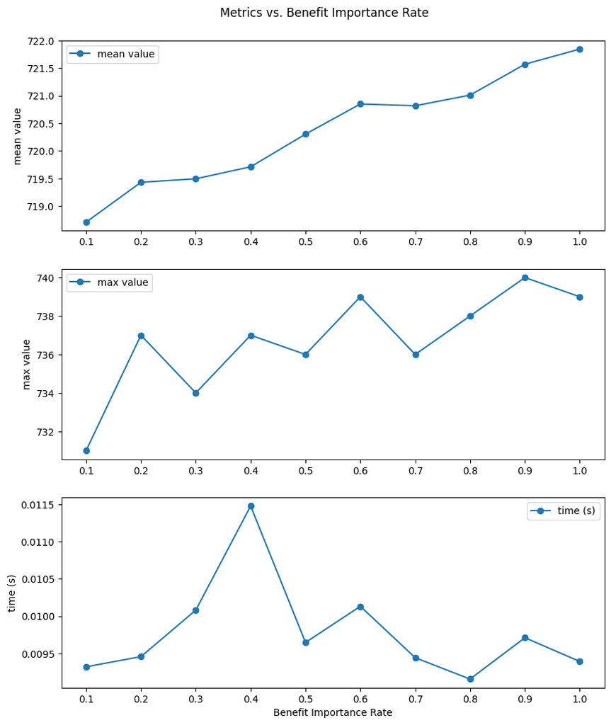

```python
metrics = [mean_values, max_values, mean_times]
names = ['mean value', 'max value', 'time (s)']
fig, axs = plt.subplots(len(metrics), 1, figsize=(10, 12))

for i, (metric, name) in enumerate(zip(metrics, names)):
    axs[i].plot(benefit_rates, metric, marker='o', label=name)
    axs[i].set_ylabel(name)
    axs[i].legend()

    # Set x-axis ticks for each subplot
    axs[i].set_xticks(benefit_rates)

plt.xlabel('Benefit Importance Rate')
plt.suptitle('Metrics vs. Benefit Importance Rate', y=0.92)
plt.show()
```

## Using Partitions to define constraint rates

### Global Vision

In previous part, we defined for each constraint a rate equals to the remain value of (1-benefit rate)/3, so we had add the same importance for each constraint.

But we can changed these rates by looking on the total number of each constraint.

For example, if on the roll we have 100 defects 'a' and 25 of 'b' and 'c', we will more consider importance rate of 'a'.

```python
main_roll.getNumbersDefects()
```

```
{'a': 164, 'b': 159, 'c': 177}
```

```python
def auto_constraint_rates(self, benefit_rate):
    remain = 1 - benefit_rate
    n_defects = self.getNumbersDefects()
    a = n_defects['a']
    b = n_defects['b']
    c = n_defects['c']
    total = a + b + c
    if total != 0:
        a_rate = (remain*a)/total
        b_rate = (remain*b)/total
        c_rate = (remain*c)/total
        return [benefit_rate, a_rate, b_rate, c_rate]
    return [benefit_rate, 0, 0, 0]
Roll.auto_constraint_rates = auto_constraint_rates
```

```python
benefit_rate = 0.4
importance_rates = main_roll.auto_constraint_rates(benefit_rate)
importance_rates
```

```
[0.4, 0.19679999999999997, 0.19079999999999997, 0.2124]
```

```python
scores = getScore(importance_rates)
scores
```

```
[0.6538363636363637, 0.9646363636363636, 0.001, 0.6164]
```

We don't excepted a big difference with the first run of this algorithm, because we just have a global vision of the main roll and the defects are equally distributed, so there are not a big difference between each constraint rate.

```python
max_iter = 1000

values = []
times = []
for i in range(1, max_iter+1):
        main_roll.reset()
        display(HTML(f'<h2>Current Iteration: {i + 1}</h2>'))
        start = time.time()
        main_roll.random_scoring_roll_rec_(scores)
        end = time.time()
        times.append(end-start)
        values.append(main_roll.value)
        clear_output(wait=True)

analysis_random_scoring_roll_rec = pd.DataFrame({
    'iteration' : [i for i in range(1, max_iter+1)],
    'score' : values,
    'time (s)' : times})
```

Current Iteration: 1001

```python
analysis_random_scoring_roll_rec.describe()
```

|  | iteration | score | time (s) |
| --- | --- | --- | --- |
| count | 1000.000000 | 1000.000000 | 1000.000000 |
| mean | 500.500000 | 719.715000 | 0.009247 |
| std | 288.819436 | 5.204312 | 0.001755 |
| min | 1.000000 | 705.000000 | 0.006925 |
| 25% | 250.750000 | 716.000000 | 0.008002 |
| 50% | 500.500000 | 720.000000 | 0.008999 |
| 75% | 750.250000 | 723.000000 | 0.009997 |
| max | 1000.000000 | 735.000000 | 0.024000 |

### Using partitions of main roll

```python
p = main_roll.partition(14, 26)
p.display()
print('count defects : ',p.getNumbersDefects())
```

```
Total Value :  0
```

|  | 0 | 1 | 2 | 3 | 4 | 5 | 6 | 7 | 8 | 9 | 10 | 11 | 12 |
| --- | --- | --- | --- | --- | --- | --- | --- | --- | --- | --- | --- | --- | --- |
| 0 | {'a': 1, 'b': 0, 'c': 0} | {'a': 0, 'b': 0, 'c': 0} | {'a': 1, 'b': 0, 'c': 1} | {'a': 0, 'b': 0, 'c': 0} | {'a': 0, 'b': 0, 'c': 0} | {'a': 0, 'b': 1, 'c': 0} | {'a': 0, 'b': 0, 'c': 0} | {'a': 0, 'b': 1, 'c': 0} | {'a': 1, 'b': 1, 'c': 0} | {'a': 2, 'b': 0, 'c': 0} | {'a': 0, 'b': 0, 'c': 0} | {'a': 1, 'b': 0, 'c': 0} | {'a': 1, 'b': 0, 'c': 1} |
| 1 | _ | _ | _ | _ | _ | _ | _ | _ | _ | _ | _ | _ | _ |

```
count defects :  {'a': 7, 'b': 3, 'c': 2}
```

```python
benefit_rate = 0.4
importance_rates = p.auto_constraint_rates(benefit_rate)
print('importance_rates : ', importance_rates)
scores = getScore(importance_rates)
print('scores : ', scores)
```

```
importance_rates :  [0.4, 0.35000000000000003, 0.15, 0.09999999999999999]
scores :  [0.6938030303030304, 0.9646363636363636, 0.001, 0.5968333333333333]
```

So, using partitions will be more accurate.

### Algorithm with partitions and adapation of constraint rates

```python
main_roll.reset()
# generate n_parts partitions with different sizes, min size musts be greater than the minimum lenght of existing biscuits to avoid empty position.
n_parts = 20
min_size = 8
divisions = main_roll.divide_roll_randomly(n_parts, min_size)
partitions = []
for div in divisions:
    part = {'partition' : main_roll.partition(div[0],div[1]-1), 'start' : div[0]}
    partitions.append(part)
for part in partitions:
    print('partition : {} with size : {}'.format(part,part['partition'].size))
```

```
partition : {'partition': <roll.Roll object at 0x000001D84E205F60>, 'start': 0} with size : 8
partition : {'partition': <roll.Roll object at 0x000001D84E0532B0>, 'start': 8} with size : 27
partition : {'partition': <roll.Roll object at 0x000001D84E051B70>, 'start': 35} with size : 52
partition : {'partition': <roll.Roll object at 0x000001D84E052C20>, 'start': 87} with size : 43
partition : {'partition': <roll.Roll object at 0x000001D84E2B2800>, 'start': 130} with size : 33
partition : {'partition': <roll.Roll object at 0x000001D84E2B1A20>, 'start': 163} with size : 8
partition : {'partition': <roll.Roll object at 0x000001D84E2B27A0>, 'start': 171} with size : 10
partition : {'partition': <roll.Roll object at 0x000001D84E2B1B70>, 'start': 181} with size : 34
partition : {'partition': <roll.Roll object at 0x000001D84E2B1CC0>, 'start': 215} with size : 8
partition : {'partition': <roll.Roll object at 0x000001D84E2B2590>, 'start': 223} with size : 17
partition : {'partition': <roll.Roll object at 0x000001D84E2B2C20>, 'start': 240} with size : 15
partition : {'partition': <roll.Roll object at 0x000001D84E2B1C60>, 'start': 255} with size : 30
partition : {'partition': <roll.Roll object at 0x000001D84E2B1F00>, 'start': 285} with size : 8
partition : {'partition': <roll.Roll object at 0x000001D84E2B1E70>, 'start': 293} with size : 8
partition : {'partition': <roll.Roll object at 0x000001D84E2B1CF0>, 'start': 301} with size : 8
partition : {'partition': <roll.Roll object at 0x000001D84E2B2C80>, 'start': 309} with size : 8
partition : {'partition': <roll.Roll object at 0x000001D84E2B2E90>, 'start': 317} with size : 8
partition : {'partition': <roll.Roll object at 0x000001D84E2B2E00>, 'start': 325} with size : 8
partition : {'partition': <roll.Roll object at 0x000001D84E2B28F0>, 'start': 333} with size : 45
partition : {'partition': <roll.Roll object at 0x000001D84E2B25F0>, 'start': 378} with size : 122
```

```python
#for each partitions apply the algorithm and update mail roll
benefit_rate = 0.4
main_roll.reset()
for part in partitions:
    part['partition'].reset()
    #compute each probabilities for each partition
    importance_rates = part['partition'].auto_constraint_rates(benefit_rate)
    scores = getScore(importance_rates)
    part['partition'].random_scoring_roll_rec_(scores)
    #update the main roll
    main_roll.updateFromPartition(part['partition'], part['start'])
main_roll.value
```

```
701
```

### Main Function

```python
def random_partitions_probabilities(self, n_parts, min_size, benefit_rate):
    #create the partitions
    divisions = self.divide_roll_randomly(n_parts, min_size)
    partitions = []
    for div in divisions:
        part = {'partition' : self.partition(div[0],div[1]-1), 'start' : div[0]}
        partitions.append(part)
    #for each partitions apply the algorithm and update the roll
    for part in partitions:
        part['partition'].reset()
        #compute each probabilities for each partition
        importance_rates = part['partition'].auto_constraint_rates(benefit_rate)
        scores = getScore(importance_rates)
        part['partition'].random_scoring_roll_rec_(scores)
        #update the roll
        self.updateFromPartition(part['partition'], part['start'])

Roll.random_partitions_probabilities = random_partitions_probabilities
```

```python
n_parts = 30
min_size = 8
benefit_rate = 0.4
```

```python
max_iter = 1000

values = []
times = []

for i in range(1, max_iter+1):
        main_roll.reset()
        display(HTML(f'<h2>Current Iteration: {i + 1}</h2>'))
        start = time.time()
        main_roll.random_partitions_probabilities(n_parts, min_size, benefit_rate)
        end = time.time()
        times.append(end-start)
        values.append(main_roll.value)
        clear_output(wait=True)

analysis_random_partitions_probabilities = pd.DataFrame({
    'iteration' : [i for i in range(1, max_iter+1)],
    'score' : values,
    'time (s)' : times})
```

Current Iteration: 1001

```python
analysis_random_partitions_probabilities.describe()
```

|  | iteration | score | time (s) |
| --- | --- | --- | --- |
| count | 1000.000000 | 1000.000000 | 1000.000000 |
| mean | 500.500000 | 683.208000 | 0.058290 |
| std | 288.819436 | 9.299528 | 0.007265 |
| min | 1.000000 | 653.000000 | 0.051000 |
| 25% | 250.750000 | 677.000000 | 0.054002 |
| 50% | 500.500000 | 683.500000 | 0.055129 |
| 75% | 750.250000 | 690.000000 | 0.059013 |
| max | 1000.000000 | 715.000000 | 0.113004 |

### Mean of this algorithm : 683

### Reminder: Mean value of previous algorithm : 720

### So bad algorithm, let's find the best parameters to run it (benefit_rate, number of partitions, min lenght of each partition)

### Grid Search of parameters

```python
n_parts = [1,4,10,20,30,40]
min_sizes = [2, 8, 9, 10, 11, 12, 20, 25]
benefit_rates = np.arange(0.1,1.1, 0.1)
```

```python
max_iter = 50
mean_values = []
max_values = []
mean_times = []
parameters = []
total_runs = len(n_parts)*len(min_sizes)*len(benefit_rates)*max_iter
k = 0
for n_part in n_parts:
    for min_size in min_sizes:
        if int(main_roll.size / n_part) > min_size:
            for benefit_rate in benefit_rates:
                values = []
                times = []
                for i in range(1, max_iter+1):
                        main_roll.reset()
                        display(HTML(f'<h2>Current Iteration: {k + 1}/{total_runs}</h2>'))
                        start = time.time()
                        main_roll.random_partitions_probabilities(n_part, min_size, benefit_rate)
                        end = time.time()
                        times.append(end-start)
                        values.append(main_roll.value)
                        clear_output(wait=True)
                        k += 1

                mean_values.append(np.array(values).mean())
                max_values.append(np.array(values).max())
                mean_times.append(np.array(times).mean())
                parameter = {'n_part' : n_part, 'min_size' : min_size, 'benefit_rate' : benefit_rate}
                parameters.append(parameter)
```

Current Iteration: 21000/24000

```python
df_grid_search = pd.DataFrame({
    'n_part' : [parameter['n_part'] for parameter in parameters],
    'min_size' : [parameter['min_size'] for parameter in parameters],
    'benefit_rate' : [parameter['benefit_rate'] for parameter in parameters],
    'mean_value' : mean_values,
    'max_value' : max_values,
    'mean_time'  : mean_times})
df_grid_search.head()
```

|  | n_part | min_size | benefit_rate | mean_value | max_value | mean_time |
| --- | --- | --- | --- | --- | --- | --- |
| 0 | 1 | 2 | 0.1 | 719.50 | 728 | 0.010921 |
| 1 | 1 | 2 | 0.2 | 718.92 | 736 | 0.011981 |
| 2 | 1 | 2 | 0.3 | 719.78 | 731 | 0.012480 |
| 3 | 1 | 2 | 0.4 | 720.22 | 732 | 0.011978 |
| 4 | 1 | 2 | 0.5 | 720.08 | 731 | 0.011642 |

```python
df_grid_search.describe()
```

|  | n_part | min_size | benefit_rate | mean_value | max_value | mean_time |
| --- | --- | --- | --- | --- | --- | --- |
| count | 420.000000 | 420.000000 | 420.000000 | 420.000000 | 420.000000 | 420.000000 |
| mean | 15.238095 | 10.833333 | 0.550000 | 695.277905 | 711.459524 | 0.036497 |
| std | 13.274789 | 5.954949 | 0.287571 | 26.162143 | 23.963393 | 0.022138 |
| min | 1.000000 | 2.000000 | 0.100000 | 602.600000 | 614.000000 | 0.010900 |
| 25% | 4.000000 | 8.000000 | 0.300000 | 679.765000 | 700.750000 | 0.017264 |
| 50% | 10.000000 | 10.000000 | 0.550000 | 704.380000 | 720.000000 | 0.028183 |
| 75% | 30.000000 | 12.000000 | 0.800000 | 715.640000 | 729.000000 | 0.056083 |
| max | 40.000000 | 25.000000 | 1.000000 | 723.440000 | 740.000000 | 0.103161 |

```python
df_grid_search.sort_values(by='mean_value', ascending=False).head(5)
```

|  | n_part | min_size | benefit_rate | mean_value | max_value | mean_time |
| --- | --- | --- | --- | --- | --- | --- |
| 68 | 1 | 20 | 0.9 | 723.44 | 740 | 0.013656 |
| 18 | 1 | 8 | 0.9 | 722.46 | 735 | 0.012239 |
| 39 | 1 | 10 | 1.0 | 722.28 | 735 | 0.011679 |
| 9 | 1 | 2 | 1.0 | 722.18 | 734 | 0.011141 |
| 46 | 1 | 11 | 0.7 | 722.18 | 730 | 0.012800 |

```python
df_grid_search.sort_values(by='max_value', ascending=False).head(5)
```

|  | n_part | min_size | benefit_rate | mean_value | max_value | mean_time |
| --- | --- | --- | --- | --- | --- | --- |
| 68 | 1 | 20 | 0.9 | 723.44 | 740 | 0.013656 |
| 1 | 1 | 2 | 0.2 | 718.92 | 736 | 0.011981 |
| 103 | 4 | 9 | 0.4 | 716.12 | 736 | 0.017741 |
| 38 | 1 | 10 | 0.9 | 722.18 | 736 | 0.011959 |
| 17 | 1 | 8 | 0.8 | 722.06 | 736 | 0.012378 |

```python
df_grid_search.sort_values(by='mean_time').head(5)
```

|  | n_part | min_size | benefit_rate | mean_value | max_value | mean_time |
| --- | --- | --- | --- | --- | --- | --- |
| 10 | 1 | 8 | 0.1 | 719.20 | 729 | 0.010900 |
| 0 | 1 | 2 | 0.1 | 719.50 | 728 | 0.010921 |
| 53 | 1 | 12 | 0.4 | 721.00 | 733 | 0.011059 |
| 9 | 1 | 2 | 1.0 | 722.18 | 734 | 0.011141 |
| 54 | 1 | 12 | 0.5 | 720.10 | 734 | 0.011159 |

We can see that the best resuts its when we don't use partition on the main roll.

```python
df_grid_search = df_grid_search[df_grid_search['n_part'] != 1]
df_grid_search.sort_values(by='mean_value', ascending=False).head(5)
```

|  | n_part | min_size | benefit_rate | mean_value | max_value | mean_time |
| --- | --- | --- | --- | --- | --- | --- |
| 147 | 4 | 20 | 0.8 | 718.60 | 735 | 0.018921 |
| 148 | 4 | 20 | 0.9 | 718.10 | 727 | 0.016419 |
| 109 | 4 | 9 | 1.0 | 717.76 | 732 | 0.017960 |
| 88 | 4 | 2 | 0.9 | 717.64 | 729 | 0.018801 |
| 117 | 4 | 10 | 0.8 | 717.30 | 727 | 0.017679 |

```python
df_grid_search.sort_values(by='mean_time').head(5)
```

|  | n_part | min_size | benefit_rate | mean_value | max_value | mean_time |
| --- | --- | --- | --- | --- | --- | --- |
| 154 | 4 | 25 | 0.5 | 714.26 | 728 | 0.016358 |
| 148 | 4 | 20 | 0.9 | 718.10 | 727 | 0.016419 |
| 116 | 4 | 10 | 0.7 | 714.46 | 729 | 0.016439 |
| 132 | 4 | 12 | 0.3 | 714.58 | 727 | 0.016459 |
| 155 | 4 | 25 | 0.6 | 714.64 | 731 | 0.016538 |

```python
df_grid_search.sort_values(by='max_value', ascending=False).head(5)
```

|  | n_part | min_size | benefit_rate | mean_value | max_value | mean_time |
| --- | --- | --- | --- | --- | --- | --- |
| 103 | 4 | 9 | 0.4 | 716.12 | 736 | 0.017741 |
| 147 | 4 | 20 | 0.8 | 718.60 | 735 | 0.018921 |
| 119 | 4 | 10 | 1.0 | 716.70 | 735 | 0.016741 |
| 146 | 4 | 20 | 0.7 | 714.70 | 734 | 0.019480 |
| 95 | 4 | 8 | 0.6 | 715.00 | 734 | 0.017380 |

## Conclusion

So actually the best way to place randomly biscuit on the roll with just one iteration:

- Using random_probabilities_roll_rec with scores defined by the user or defined by the constraints with auto_constraint_rates, but last function doesn't have really impact because of the distribution of the defects.
- The choice of the benefit rate depends of the uses of random_probabilities_roll_rec, choose an higher benefit rate to have a good result, but also consider constraints to gained times.

# Artificial Bee Algorithm

- code in 'abc_algo.py'
- The main idea is to create several food sources which each are a roll init with random_probabilities_roll_rec and a random benefit rate.

```python
from abc_algo import *
```

## Quick view of the algorithm

```python
colony_size = 5 #number of variables to creates
max_iter = 20
limit = 4 #max trial value to reach
```

```python
main_roll.reset()
Partition = main_roll.partition(320,404)
abc = ABC(Partition, colony_size, max_iter,limit)
optimal_roll, optimal_value = abc.optimize(True) #display each iteration of the algorithm to have a better understanding
```

```
iteration 0 :
```

|  | foodsource | value | fitness | benefit rate | trial |
| --- | --- | --- | --- | --- | --- |
| 0 | 0 | 129 | 0.007692 | 0.635945 | 0 |
| 1 | 1 | 126 | 0.007874 | 0.610331 | 0 |
| 2 | 2 | 125 | 0.007937 | 0.223895 | 0 |
| 3 | 3 | 124 | 0.008000 | 0.257327 | 0 |
| 4 | 4 | 125 | 0.007937 | 0.262722 | 0 |

```
current best solution :  None


iteration 1 :
```

|  | foodsource | value | fitness | benefit rate | trial |
| --- | --- | --- | --- | --- | --- |
| 0 | 0 | 123 | 0.008065 | 0.868330 | 0 |
| 1 | 1 | 126 | 0.007874 | 0.610331 | 1 |
| 2 | 2 | 125 | 0.007937 | 0.223895 | 1 |
| 3 | 3 | 124 | 0.008000 | 0.257327 | 1 |
| 4 | 4 | 127 | 0.007812 | 0.262722 | 1 |

```
current best solution :  129


iteration 2 :
```

|  | foodsource | value | fitness | benefit rate | trial |
| --- | --- | --- | --- | --- | --- |
| 0 | 0 | 127 | 0.007812 | 0.868330 | 1 |
| 1 | 1 | 130 | 0.007634 | 0.610331 | 0 |
| 2 | 2 | 128 | 0.007752 | 0.223895 | 1 |
| 3 | 3 | 124 | 0.008000 | 0.257327 | 3 |
| 4 | 4 | 127 | 0.007812 | 0.262722 | 3 |

```
current best solution :  130


iteration 3 :
```

|  | foodsource | value | fitness | benefit rate | trial |
| --- | --- | --- | --- | --- | --- |
| 0 | 0 | 127 | 0.007812 | 0.868330 | 3 |
| 1 | 1 | 130 | 0.007634 | 0.610331 | 3 |
| 2 | 2 | 128 | 0.007752 | 0.223895 | 3 |
| 3 | 3 | 125 | 0.007937 | 0.279636 | 0 |
| 4 | 4 | 128 | 0.007752 | 0.508327 | 0 |

```
current best solution :  130


iteration 4 :
```

|  | foodsource | value | fitness | benefit rate | trial |
| --- | --- | --- | --- | --- | --- |
| 0 | 0 | 130 | 0.007634 | 0.868330 | 1 |
| 1 | 1 | 125 | 0.007937 | 0.561737 | 0 |
| 2 | 2 | 122 | 0.008130 | 0.150470 | 0 |
| 3 | 3 | 127 | 0.007812 | 0.279636 | 2 |
| 4 | 4 | 128 | 0.007752 | 0.508327 | 1 |

```
current best solution :  130


iteration 5 :
```

|  | foodsource | value | fitness | benefit rate | trial |
| --- | --- | --- | --- | --- | --- |
| 0 | 0 | 130 | 0.007634 | 0.868330 | 3 |
| 1 | 1 | 127 | 0.007812 | 0.561737 | 2 |
| 2 | 2 | 124 | 0.008000 | 0.150470 | 0 |
| 3 | 3 | 125 | 0.007937 | 0.861358 | 0 |
| 4 | 4 | 128 | 0.007752 | 0.508327 | 3 |

```
current best solution :  130


iteration 6 :
```

|  | foodsource | value | fitness | benefit rate | trial |
| --- | --- | --- | --- | --- | --- |
| 0 | 0 | 119 | 0.008333 | 0.578767 | 0 |
| 1 | 1 | 122 | 0.008130 | 0.583312 | 0 |
| 2 | 2 | 124 | 0.008000 | 0.077403 | 0 |
| 3 | 3 | 125 | 0.007937 | 0.861358 | 1 |
| 4 | 4 | 126 | 0.007874 | 0.060822 | 0 |

```
current best solution :  130


iteration 7 :
```

|  | foodsource | value | fitness | benefit rate | trial |
| --- | --- | --- | --- | --- | --- |
| 0 | 0 | 125 | 0.007937 | 0.578767 | 0 |
| 1 | 1 | 125 | 0.007937 | 0.583312 | 1 |
| 2 | 2 | 125 | 0.007937 | 0.077403 | 1 |
| 3 | 3 | 124 | 0.008000 | 0.219255 | 0 |
| 4 | 4 | 127 | 0.007812 | 0.060822 | 0 |

```
current best solution :  130


iteration 8 :
```

|  | foodsource | value | fitness | benefit rate | trial |
| --- | --- | --- | --- | --- | --- |
| 0 | 0 | 125 | 0.007937 | 0.578767 | 2 |
| 1 | 1 | 125 | 0.007937 | 0.583312 | 3 |
| 2 | 2 | 128 | 0.007752 | 0.077403 | 0 |
| 3 | 3 | 126 | 0.007874 | 0.219255 | 1 |
| 4 | 4 | 127 | 0.007812 | 0.060822 | 2 |

```
current best solution :  130


iteration 9 :
```

|  | foodsource | value | fitness | benefit rate | trial |
| --- | --- | --- | --- | --- | --- |
| 0 | 0 | 127 | 0.007812 | 0.578767 | 0 |
| 1 | 1 | 127 | 0.007812 | 0.583312 | 0 |
| 2 | 2 | 128 | 0.007752 | 0.077403 | 1 |
| 3 | 3 | 126 | 0.007874 | 0.219255 | 3 |
| 4 | 4 | 124 | 0.008000 | 0.559676 | 0 |

```
current best solution :  130


iteration 10 :
```

|  | foodsource | value | fitness | benefit rate | trial |
| --- | --- | --- | --- | --- | --- |
| 0 | 0 | 127 | 0.007812 | 0.578767 | 1 |
| 1 | 1 | 127 | 0.007812 | 0.583312 | 3 |
| 2 | 2 | 128 | 0.007752 | 0.077403 | 3 |
| 3 | 3 | 121 | 0.008197 | 0.295092 | 0 |
| 4 | 4 | 125 | 0.007937 | 0.559676 | 1 |

```
current best solution :  130


iteration 11 :
```

|  | foodsource | value | fitness | benefit rate | trial |
| --- | --- | --- | --- | --- | --- |
| 0 | 0 | 127 | 0.007812 | 0.578767 | 2 |
| 1 | 1 | 128 | 0.007752 | 0.583312 | 1 |
| 2 | 2 | 127 | 0.007812 | 0.074885 | 0 |
| 3 | 3 | 125 | 0.007937 | 0.295092 | 0 |
| 4 | 4 | 122 | 0.008130 | 0.045385 | 0 |

```
current best solution :  130


iteration 12 :
```

|  | foodsource | value | fitness | benefit rate | trial |
| --- | --- | --- | --- | --- | --- |
| 0 | 0 | 122 | 0.008130 | 0.862732 | 0 |
| 1 | 1 | 128 | 0.007752 | 0.583312 | 3 |
| 2 | 2 | 127 | 0.007812 | 0.074885 | 2 |
| 3 | 3 | 125 | 0.007937 | 0.295092 | 1 |
| 4 | 4 | 127 | 0.007812 | 0.045385 | 1 |

```
current best solution :  130


iteration 13 :
```

|  | foodsource | value | fitness | benefit rate | trial |
| --- | --- | --- | --- | --- | --- |
| 0 | 0 | 122 | 0.008130 | 0.862732 | 2 |
| 1 | 1 | 121 | 0.008197 | 0.336856 | 0 |
| 2 | 2 | 121 | 0.008197 | 0.581930 | 0 |
| 3 | 3 | 126 | 0.007874 | 0.295092 | 2 |
| 4 | 4 | 127 | 0.007812 | 0.045385 | 3 |

```
current best solution :  130


iteration 14 :
```

|  | foodsource | value | fitness | benefit rate | trial |
| --- | --- | --- | --- | --- | --- |
| 0 | 0 | 120 | 0.008264 | 0.191352 | 0 |
| 1 | 1 | 124 | 0.008000 | 0.336856 | 2 |
| 2 | 2 | 128 | 0.007752 | 0.581930 | 0 |
| 3 | 3 | 118 | 0.008403 | 0.398623 | 0 |
| 4 | 4 | 124 | 0.008000 | 0.958199 | 0 |

```
current best solution :  130


iteration 15 :
```

|  | foodsource | value | fitness | benefit rate | trial |
| --- | --- | --- | --- | --- | --- |
| 0 | 0 | 125 | 0.007937 | 0.191352 | 0 |
| 1 | 1 | 127 | 0.007812 | 0.336856 | 0 |
| 2 | 2 | 128 | 0.007752 | 0.581930 | 3 |
| 3 | 3 | 124 | 0.008000 | 0.398623 | 1 |
| 4 | 4 | 125 | 0.007937 | 0.958199 | 0 |

```
current best solution :  130


iteration 16 :
```

|  | foodsource | value | fitness | benefit rate | trial |
| --- | --- | --- | --- | --- | --- |
| 0 | 0 | 125 | 0.007937 | 0.191352 | 1 |
| 1 | 1 | 127 | 0.007812 | 0.336856 | 2 |
| 2 | 2 | 124 | 0.008000 | 0.311482 | 0 |
| 3 | 3 | 124 | 0.008000 | 0.398623 | 2 |
| 4 | 4 | 125 | 0.007937 | 0.958199 | 3 |

```
current best solution :  130


iteration 17 :
```

|  | foodsource | value | fitness | benefit rate | trial |
| --- | --- | --- | --- | --- | --- |
| 0 | 0 | 126 | 0.007874 | 0.191352 | 1 |
| 1 | 1 | 127 | 0.007812 | 0.336856 | 3 |
| 2 | 2 | 124 | 0.008000 | 0.311482 | 2 |
| 3 | 3 | 124 | 0.008000 | 0.398623 | 3 |
| 4 | 4 | 125 | 0.007937 | 0.926244 | 0 |

```
current best solution :  130


iteration 18 :
```

|  | foodsource | value | fitness | benefit rate | trial |
| --- | --- | --- | --- | --- | --- |
| 0 | 0 | 126 | 0.007874 | 0.191352 | 3 |
| 1 | 1 | 127 | 0.007812 | 0.684378 | 0 |
| 2 | 2 | 124 | 0.008000 | 0.311482 | 3 |
| 3 | 3 | 121 | 0.008197 | 0.984448 | 0 |
| 4 | 4 | 130 | 0.007634 | 0.926244 | 1 |

```
current best solution :  130


iteration 19 :
```

|  | foodsource | value | fitness | benefit rate | trial |
| --- | --- | --- | --- | --- | --- |
| 0 | 0 | 125 | 0.007937 | 0.577166 | 0 |
| 1 | 1 | 127 | 0.007812 | 0.684378 | 2 |
| 2 | 2 | 118 | 0.008403 | 0.788787 | 0 |
| 3 | 3 | 125 | 0.007937 | 0.984448 | 1 |
| 4 | 4 | 130 | 0.007634 | 0.926244 | 3 |

```
current best solution :  130


iteration 20 :
```

|  | foodsource | value | fitness | benefit rate | trial |
| --- | --- | --- | --- | --- | --- |
| 0 | 0 | 127 | 0.007812 | 0.577166 | 1 |
| 1 | 1 | 118 | 0.008403 | 0.309375 | 0 |
| 2 | 2 | 125 | 0.007937 | 0.788787 | 0 |
| 3 | 3 | 128 | 0.007752 | 0.984448 | 0 |
| 4 | 4 | 132 | 0.007519 | 0.926244 | 0 |

```
current best solution :  132
```

```python
print('final result :', optimal_value)
```

```
final result : 132
```

## First test on the main_roll

```python
colony_size = 5 #number of variables to creates
max_iter = 100
limit = 20 #max trial value to reach
```

```python
main_roll.reset()
abc = ABC(main_roll, colony_size, max_iter,limit)
optimal_roll, optimal_value = abc.optimize()
```

```python
optimal_roll.display()
```

```
Total Value :  742
```

|  | 0 | 1 | 2 | 3 | 4 | 5 | 6 | 7 | 8 | 9 | 10 | 11 | 12 | 13 | 14 | 15 | 16 | 17 | 18 | 19 |
| --- | --- | --- | --- | --- | --- | --- | --- | --- | --- | --- | --- | --- | --- | --- | --- | --- | --- | --- | --- | --- |
| 0 | {'a': 2, 'b': 0, 'c': 0} | {'a': 1, 'b': 0, 'c': 0} | {'a': 1, 'b': 1, 'c': 0} | {'a': 1, 'b': 1, 'c': 0} | {'a': 0, 'b': 0, 'c': 0} | {'a': 0, 'b': 0, 'c': 0} | {'a': 0, 'b': 0, 'c': 0} | {'a': 0, 'b': 0, 'c': 0} | {'a': 0, 'b': 0, 'c': 1} | {'a': 0, 'b': 0, 'c': 2} | {'a': 0, 'b': 1, 'c': 1} | {'a': 0, 'b': 0, 'c': 0} | {'a': 1, 'b': 0, 'c': 0} | {'a': 0, 'b': 0, 'c': 0} | {'a': 1, 'b': 0, 'c': 0} | {'a': 0, 'b': 0, 'c': 0} | {'a': 1, 'b': 0, 'c': 1} | {'a': 0, 'b': 0, 'c': 0} | {'a': 0, 'b': 0, 'c': 0} | {'a': 0, 'b': 1, 'c': 0} |
| 1 | [1 | 1 | 1 | 1 | 1 | 1 | 1 | 1] | [1 | 1 | 1 | 1 | 1 | 1 | 1 | 1] | [1 | 1 | 1 | 1 |

|  | 20 | 21 | 22 | 23 | 24 | 25 | 26 | 27 | 28 | 29 | 30 | 31 | 32 | 33 | 34 | 35 | 36 | 37 | 38 | 39 |
| --- | --- | --- | --- | --- | --- | --- | --- | --- | --- | --- | --- | --- | --- | --- | --- | --- | --- | --- | --- | --- |
| 0 | {'a': 0, 'b': 0, 'c': 0} | {'a': 0, 'b': 1, 'c': 0} | {'a': 1, 'b': 1, 'c': 0} | {'a': 2, 'b': 0, 'c': 0} | {'a': 0, 'b': 0, 'c': 0} | {'a': 1, 'b': 0, 'c': 0} | {'a': 1, 'b': 0, 'c': 1} | {'a': 0, 'b': 0, 'c': 0} | {'a': 0, 'b': 0, 'c': 0} | {'a': 1, 'b': 0, 'c': 0} | {'a': 0, 'b': 1, 'c': 0} | {'a': 0, 'b': 0, 'c': 0} | {'a': 1, 'b': 0, 'c': 0} | {'a': 0, 'b': 1, 'c': 0} | {'a': 0, 'b': 1, 'c': 0} | {'a': 0, 'b': 1, 'c': 1} | {'a': 1, 'b': 1, 'c': 0} | {'a': 0, 'b': 1, 'c': 0} | {'a': 1, 'b': 0, 'c': 0} | {'a': 0, 'b': 0, 'c': 2} |
| 1 | 1 | 1 | 1 | 1] | [0 | 0 | 0 | 0] | [1 | 1 | 1 | 1 | 1 | 1 | 1 | 1] | [0 | 0 | 0 | 0] |

|  | 40 | 41 | 42 | 43 | 44 | 45 | 46 | 47 | 48 | 49 | 50 | 51 | 52 | 53 | 54 | 55 | 56 | 57 | 58 | 59 |
| --- | --- | --- | --- | --- | --- | --- | --- | --- | --- | --- | --- | --- | --- | --- | --- | --- | --- | --- | --- | --- |
| 0 | {'a': 0, 'b': 0, 'c': 2} | {'a': 0, 'b': 0, 'c': 1} | {'a': 0, 'b': 0, 'c': 0} | {'a': 0, 'b': 0, 'c': 0} | {'a': 1, 'b': 1, 'c': 0} | {'a': 0, 'b': 0, 'c': 0} | {'a': 1, 'b': 1, 'c': 0} | {'a': 0, 'b': 0, 'c': 1} | {'a': 1, 'b': 1, 'c': 0} | {'a': 0, 'b': 0, 'c': 1} | {'a': 0, 'b': 0, 'c': 1} | {'a': 1, 'b': 1, 'c': 2} | {'a': 0, 'b': 0, 'c': 0} | {'a': 1, 'b': 0, 'c': 0} | {'a': 0, 'b': 1, 'c': 0} | {'a': 1, 'b': 0, 'c': 1} | {'a': 0, 'b': 0, 'c': 0} | {'a': 0, 'b': 0, 'c': 1} | {'a': 1, 'b': 0, 'c': 0} | {'a': 1, 'b': 1, 'c': 2} |
| 1 | [0 | 0 | 0 | 0] | [0 | 0 | 0 | 0] | [2 | 2] | [0 | 0 | 0 | 0] | [1 | 1 | 1 | 1 | 1 | 1 |

|  | 60 | 61 | 62 | 63 | 64 | 65 | 66 | 67 | 68 | 69 | 70 | 71 | 72 | 73 | 74 | 75 | 76 | 77 | 78 | 79 |
| --- | --- | --- | --- | --- | --- | --- | --- | --- | --- | --- | --- | --- | --- | --- | --- | --- | --- | --- | --- | --- |
| 0 | {'a': 0, 'b': 0, 'c': 0} | {'a': 0, 'b': 0, 'c': 0} | {'a': 0, 'b': 0, 'c': 0} | {'a': 0, 'b': 0, 'c': 0} | {'a': 0, 'b': 0, 'c': 1} | {'a': 0, 'b': 0, 'c': 1} | {'a': 0, 'b': 0, 'c': 0} | {'a': 0, 'b': 0, 'c': 0} | {'a': 0, 'b': 1, 'c': 1} | {'a': 1, 'b': 0, 'c': 0} | {'a': 0, 'b': 0, 'c': 0} | {'a': 0, 'b': 0, 'c': 0} | {'a': 0, 'b': 2, 'c': 1} | {'a': 1, 'b': 0, 'c': 0} | {'a': 0, 'b': 0, 'c': 2} | {'a': 0, 'b': 0, 'c': 0} | {'a': 1, 'b': 0, 'c': 0} | {'a': 2, 'b': 0, 'c': 0} | {'a': 0, 'b': 0, 'c': 0} | {'a': 0, 'b': 0, 'c': 0} |
| 1 | 1 | 1] | [3 | 3 | 3 | 3 | 3] | [3 | 3 | 3 | 3 | 3] | [0 | 0 | 0 | 0] | [1 | 1 | 1 | 1 |

|  | 80 | 81 | 82 | 83 | 84 | 85 | 86 | 87 | 88 | 89 | 90 | 91 | 92 | 93 | 94 | 95 | 96 | 97 | 98 | 99 |
| --- | --- | --- | --- | --- | --- | --- | --- | --- | --- | --- | --- | --- | --- | --- | --- | --- | --- | --- | --- | --- |
| 0 | {'a': 0, 'b': 0, 'c': 0} | {'a': 0, 'b': 0, 'c': 0} | {'a': 0, 'b': 2, 'c': 1} | {'a': 1, 'b': 1, 'c': 1} | {'a': 0, 'b': 0, 'c': 1} | {'a': 2, 'b': 0, 'c': 0} | {'a': 0, 'b': 0, 'c': 0} | {'a': 0, 'b': 0, 'c': 0} | {'a': 0, 'b': 0, 'c': 0} | {'a': 0, 'b': 0, 'c': 1} | {'a': 0, 'b': 0, 'c': 0} | {'a': 0, 'b': 0, 'c': 1} | {'a': 1, 'b': 0, 'c': 0} | {'a': 2, 'b': 0, 'c': 0} | {'a': 0, 'b': 0, 'c': 1} | {'a': 1, 'b': 0, 'c': 1} | {'a': 0, 'b': 1, 'c': 0} | {'a': 0, 'b': 0, 'c': 3} | {'a': 0, 'b': 0, 'c': 2} | {'a': 0, 'b': 0, 'c': 0} |
| 1 | 1 | 1 | 1 | 1] | [3 | 3 | 3 | 3 | 3] | [1 | 1 | 1 | 1 | 1 | 1 | 1 | 1] | _ | [0 | 0 |

|  | 100 | 101 | 102 | 103 | 104 | 105 | 106 | 107 | 108 | 109 | 110 | 111 | 112 | 113 | 114 | 115 | 116 | 117 | 118 | 119 |
| --- | --- | --- | --- | --- | --- | --- | --- | --- | --- | --- | --- | --- | --- | --- | --- | --- | --- | --- | --- | --- |
| 0 | {'a': 0, 'b': 0, 'c': 0} | {'a': 0, 'b': 0, 'c': 0} | {'a': 0, 'b': 0, 'c': 1} | {'a': 1, 'b': 0, 'c': 0} | {'a': 0, 'b': 0, 'c': 0} | {'a': 0, 'b': 0, 'c': 0} | {'a': 0, 'b': 0, 'c': 0} | {'a': 1, 'b': 1, 'c': 1} | {'a': 1, 'b': 0, 'c': 0} | {'a': 0, 'b': 0, 'c': 0} | {'a': 0, 'b': 0, 'c': 2} | {'a': 0, 'b': 0, 'c': 0} | {'a': 1, 'b': 0, 'c': 0} | {'a': 0, 'b': 0, 'c': 2} | {'a': 0, 'b': 0, 'c': 0} | {'a': 0, 'b': 0, 'c': 1} | {'a': 1, 'b': 1, 'c': 1} | {'a': 2, 'b': 1, 'c': 0} | {'a': 2, 'b': 0, 'c': 0} | {'a': 1, 'b': 0, 'c': 0} |
| 1 | 0 | 0] | [1 | 1 | 1 | 1 | 1 | 1 | 1 | 1] | _ | [0 | 0 | 0 | 0] | _ | _ | _ | [0 | 0 |

|  | 120 | 121 | 122 | 123 | 124 | 125 | 126 | 127 | 128 | 129 | 130 | 131 | 132 | 133 | 134 | 135 | 136 | 137 | 138 | 139 |
| --- | --- | --- | --- | --- | --- | --- | --- | --- | --- | --- | --- | --- | --- | --- | --- | --- | --- | --- | --- | --- |
| 0 | {'a': 0, 'b': 0, 'c': 1} | {'a': 0, 'b': 0, 'c': 1} | {'a': 0, 'b': 1, 'c': 0} | {'a': 0, 'b': 1, 'c': 1} | {'a': 1, 'b': 0, 'c': 0} | {'a': 3, 'b': 0, 'c': 1} | {'a': 0, 'b': 0, 'c': 0} | {'a': 0, 'b': 1, 'c': 0} | {'a': 0, 'b': 0, 'c': 1} | {'a': 0, 'b': 1, 'c': 1} | {'a': 0, 'b': 0, 'c': 0} | {'a': 0, 'b': 0, 'c': 0} | {'a': 0, 'b': 0, 'c': 0} | {'a': 0, 'b': 0, 'c': 0} | {'a': 0, 'b': 0, 'c': 0} | {'a': 0, 'b': 0, 'c': 0} | {'a': 0, 'b': 0, 'c': 1} | {'a': 0, 'b': 0, 'c': 1} | {'a': 0, 'b': 0, 'c': 0} | {'a': 0, 'b': 1, 'c': 1} |
| 1 | 0 | 0] | [0 | 0 | 0 | 0] | [0 | 0 | 0 | 0] | [3 | 3 | 3 | 3 | 3] | [0 | 0 | 0 | 0] | [0 |

|  | 140 | 141 | 142 | 143 | 144 | 145 | 146 | 147 | 148 | 149 | 150 | 151 | 152 | 153 | 154 | 155 | 156 | 157 | 158 | 159 |
| --- | --- | --- | --- | --- | --- | --- | --- | --- | --- | --- | --- | --- | --- | --- | --- | --- | --- | --- | --- | --- |
| 0 | {'a': 1, 'b': 0, 'c': 0} | {'a': 0, 'b': 1, 'c': 1} | {'a': 0, 'b': 0, 'c': 1} | {'a': 2, 'b': 0, 'c': 1} | {'a': 1, 'b': 0, 'c': 0} | {'a': 0, 'b': 0, 'c': 1} | {'a': 0, 'b': 1, 'c': 1} | {'a': 0, 'b': 0, 'c': 0} | {'a': 0, 'b': 1, 'c': 0} | {'a': 0, 'b': 0, 'c': 1} | {'a': 0, 'b': 0, 'c': 1} | {'a': 0, 'b': 0, 'c': 0} | {'a': 0, 'b': 0, 'c': 0} | {'a': 0, 'b': 1, 'c': 0} | {'a': 1, 'b': 1, 'c': 1} | {'a': 0, 'b': 0, 'c': 0} | {'a': 1, 'b': 1, 'c': 0} | {'a': 0, 'b': 3, 'c': 0} | {'a': 1, 'b': 0, 'c': 0} | {'a': 1, 'b': 0, 'c': 1} |
| 1 | 0 | 0 | 0] | [0 | 0 | 0 | 0] | [3 | 3 | 3 | 3 | 3] | [3 | 3 | 3 | 3 | 3] | _ | [0 | 0 |

|  | 160 | 161 | 162 | 163 | 164 | 165 | 166 | 167 | 168 | 169 | 170 | 171 | 172 | 173 | 174 | 175 | 176 | 177 | 178 | 179 |
| --- | --- | --- | --- | --- | --- | --- | --- | --- | --- | --- | --- | --- | --- | --- | --- | --- | --- | --- | --- | --- |
| 0 | {'a': 0, 'b': 0, 'c': 0} | {'a': 0, 'b': 1, 'c': 0} | {'a': 0, 'b': 0, 'c': 0} | {'a': 3, 'b': 1, 'c': 1} | {'a': 0, 'b': 0, 'c': 0} | {'a': 0, 'b': 0, 'c': 1} | {'a': 1, 'b': 3, 'c': 0} | {'a': 0, 'b': 0, 'c': 0} | {'a': 0, 'b': 2, 'c': 0} | {'a': 1, 'b': 0, 'c': 0} | {'a': 0, 'b': 0, 'c': 0} | {'a': 1, 'b': 1, 'c': 1} | {'a': 1, 'b': 0, 'c': 1} | {'a': 0, 'b': 1, 'c': 0} | {'a': 0, 'b': 0, 'c': 1} | {'a': 0, 'b': 0, 'c': 0} | {'a': 0, 'b': 1, 'c': 0} | {'a': 0, 'b': 0, 'c': 0} | {'a': 0, 'b': 0, 'c': 2} | {'a': 0, 'b': 2, 'c': 1} |
| 1 | 0 | 0] | [0 | 0 | 0 | 0] | _ | [1 | 1 | 1 | 1 | 1 | 1 | 1 | 1] | [0 | 0 | 0 | 0] | [3 |

|  | 180 | 181 | 182 | 183 | 184 | 185 | 186 | 187 | 188 | 189 | 190 | 191 | 192 | 193 | 194 | 195 | 196 | 197 | 198 | 199 |
| --- | --- | --- | --- | --- | --- | --- | --- | --- | --- | --- | --- | --- | --- | --- | --- | --- | --- | --- | --- | --- |
| 0 | {'a': 0, 'b': 0, 'c': 0} | {'a': 0, 'b': 0, 'c': 0} | {'a': 0, 'b': 0, 'c': 0} | {'a': 0, 'b': 0, 'c': 1} | {'a': 0, 'b': 3, 'c': 3} | {'a': 0, 'b': 1, 'c': 0} | {'a': 0, 'b': 1, 'c': 0} | {'a': 0, 'b': 1, 'c': 0} | {'a': 3, 'b': 0, 'c': 0} | {'a': 1, 'b': 0, 'c': 0} | {'a': 1, 'b': 1, 'c': 0} | {'a': 0, 'b': 1, 'c': 1} | {'a': 0, 'b': 1, 'c': 0} | {'a': 0, 'b': 0, 'c': 0} | {'a': 0, 'b': 0, 'c': 1} | {'a': 0, 'b': 0, 'c': 0} | {'a': 0, 'b': 0, 'c': 1} | {'a': 0, 'b': 0, 'c': 0} | {'a': 0, 'b': 0, 'c': 1} | {'a': 0, 'b': 0, 'c': 0} |
| 1 | 3 | 3 | 3 | 3] | _ | [2 | 2] | [1 | 1 | 1 | 1 | 1 | 1 | 1 | 1] | [0 | 0 | 0 | 0] | [1 |

|  | 200 | 201 | 202 | 203 | 204 | 205 | 206 | 207 | 208 | 209 | 210 | 211 | 212 | 213 | 214 | 215 | 216 | 217 | 218 | 219 |
| --- | --- | --- | --- | --- | --- | --- | --- | --- | --- | --- | --- | --- | --- | --- | --- | --- | --- | --- | --- | --- |
| 0 | {'a': 0, 'b': 1, 'c': 0} | {'a': 0, 'b': 0, 'c': 1} | {'a': 0, 'b': 0, 'c': 0} | {'a': 1, 'b': 0, 'c': 1} | {'a': 0, 'b': 0, 'c': 0} | {'a': 2, 'b': 0, 'c': 0} | {'a': 0, 'b': 0, 'c': 1} | {'a': 0, 'b': 0, 'c': 0} | {'a': 0, 'b': 0, 'c': 0} | {'a': 0, 'b': 1, 'c': 1} | {'a': 0, 'b': 0, 'c': 1} | {'a': 0, 'b': 0, 'c': 0} | {'a': 1, 'b': 0, 'c': 0} | {'a': 0, 'b': 1, 'c': 0} | {'a': 1, 'b': 1, 'c': 1} | {'a': 0, 'b': 0, 'c': 0} | {'a': 1, 'b': 1, 'c': 1} | {'a': 0, 'b': 0, 'c': 0} | {'a': 1, 'b': 0, 'c': 0} | {'a': 0, 'b': 0, 'c': 0} |
| 1 | 1 | 1 | 1 | 1 | 1 | 1 | 1] | [1 | 1 | 1 | 1 | 1 | 1 | 1 | 1] | [0 | 0 | 0 | 0] | [0 |

|  | 220 | 221 | 222 | 223 | 224 | 225 | 226 | 227 | 228 | 229 | 230 | 231 | 232 | 233 | 234 | 235 | 236 | 237 | 238 | 239 |
| --- | --- | --- | --- | --- | --- | --- | --- | --- | --- | --- | --- | --- | --- | --- | --- | --- | --- | --- | --- | --- |
| 0 | {'a': 0, 'b': 0, 'c': 0} | {'a': 0, 'b': 1, 'c': 0} | {'a': 0, 'b': 0, 'c': 0} | {'a': 1, 'b': 0, 'c': 0} | {'a': 0, 'b': 0, 'c': 0} | {'a': 0, 'b': 0, 'c': 0} | {'a': 0, 'b': 0, 'c': 0} | {'a': 1, 'b': 1, 'c': 0} | {'a': 0, 'b': 0, 'c': 1} | {'a': 0, 'b': 0, 'c': 0} | {'a': 1, 'b': 0, 'c': 0} | {'a': 0, 'b': 0, 'c': 1} | {'a': 0, 'b': 0, 'c': 0} | {'a': 0, 'b': 0, 'c': 0} | {'a': 0, 'b': 1, 'c': 1} | {'a': 0, 'b': 1, 'c': 0} | {'a': 0, 'b': 0, 'c': 0} | {'a': 0, 'b': 0, 'c': 0} | {'a': 0, 'b': 0, 'c': 0} | {'a': 0, 'b': 0, 'c': 0} |
| 1 | 0 | 0 | 0] | [3 | 3 | 3 | 3 | 3] | [1 | 1 | 1 | 1 | 1 | 1 | 1 | 1] | [1 | 1 | 1 | 1 |

|  | 240 | 241 | 242 | 243 | 244 | 245 | 246 | 247 | 248 | 249 | 250 | 251 | 252 | 253 | 254 | 255 | 256 | 257 | 258 | 259 |
| --- | --- | --- | --- | --- | --- | --- | --- | --- | --- | --- | --- | --- | --- | --- | --- | --- | --- | --- | --- | --- |
| 0 | {'a': 0, 'b': 0, 'c': 1} | {'a': 0, 'b': 3, 'c': 1} | {'a': 3, 'b': 1, 'c': 0} | {'a': 0, 'b': 0, 'c': 0} | {'a': 0, 'b': 0, 'c': 1} | {'a': 0, 'b': 1, 'c': 0} | {'a': 1, 'b': 0, 'c': 1} | {'a': 0, 'b': 0, 'c': 1} | {'a': 0, 'b': 1, 'c': 1} | {'a': 0, 'b': 0, 'c': 0} | {'a': 0, 'b': 0, 'c': 0} | {'a': 1, 'b': 1, 'c': 0} | {'a': 0, 'b': 0, 'c': 0} | {'a': 1, 'b': 0, 'c': 1} | {'a': 0, 'b': 0, 'c': 0} | {'a': 0, 'b': 0, 'c': 1} | {'a': 0, 'b': 0, 'c': 0} | {'a': 0, 'b': 1, 'c': 1} | {'a': 0, 'b': 1, 'c': 0} | {'a': 0, 'b': 1, 'c': 0} |
| 1 | 1 | 1 | 1 | 1] | [0 | 0 | 0 | 0] | [1 | 1 | 1 | 1 | 1 | 1 | 1 | 1] | [3 | 3 | 3 | 3 |

|  | 260 | 261 | 262 | 263 | 264 | 265 | 266 | 267 | 268 | 269 | 270 | 271 | 272 | 273 | 274 | 275 | 276 | 277 | 278 | 279 |
| --- | --- | --- | --- | --- | --- | --- | --- | --- | --- | --- | --- | --- | --- | --- | --- | --- | --- | --- | --- | --- |
| 0 | {'a': 0, 'b': 0, 'c': 1} | {'a': 0, 'b': 0, 'c': 0} | {'a': 0, 'b': 0, 'c': 0} | {'a': 0, 'b': 0, 'c': 0} | {'a': 0, 'b': 0, 'c': 1} | {'a': 0, 'b': 0, 'c': 1} | {'a': 0, 'b': 0, 'c': 0} | {'a': 0, 'b': 1, 'c': 0} | {'a': 0, 'b': 0, 'c': 0} | {'a': 0, 'b': 1, 'c': 0} | {'a': 1, 'b': 1, 'c': 0} | {'a': 0, 'b': 0, 'c': 0} | {'a': 0, 'b': 1, 'c': 0} | {'a': 0, 'b': 0, 'c': 1} | {'a': 0, 'b': 0, 'c': 0} | {'a': 2, 'b': 2, 'c': 0} | {'a': 1, 'b': 0, 'c': 0} | {'a': 1, 'b': 0, 'c': 1} | {'a': 0, 'b': 0, 'c': 0} | {'a': 1, 'b': 0, 'c': 1} |
| 1 | 3] | [0 | 0 | 0 | 0] | [1 | 1 | 1 | 1 | 1 | 1 | 1 | 1] | [0 | 0 | 0 | 0] | [1 | 1 | 1 |

|  | 280 | 281 | 282 | 283 | 284 | 285 | 286 | 287 | 288 | 289 | 290 | 291 | 292 | 293 | 294 | 295 | 296 | 297 | 298 | 299 |
| --- | --- | --- | --- | --- | --- | --- | --- | --- | --- | --- | --- | --- | --- | --- | --- | --- | --- | --- | --- | --- |
| 0 | {'a': 2, 'b': 0, 'c': 0} | {'a': 0, 'b': 1, 'c': 0} | {'a': 0, 'b': 0, 'c': 1} | {'a': 0, 'b': 0, 'c': 1} | {'a': 1, 'b': 1, 'c': 0} | {'a': 0, 'b': 1, 'c': 0} | {'a': 0, 'b': 0, 'c': 0} | {'a': 0, 'b': 0, 'c': 0} | {'a': 1, 'b': 0, 'c': 0} | {'a': 1, 'b': 1, 'c': 0} | {'a': 0, 'b': 0, 'c': 0} | {'a': 0, 'b': 1, 'c': 0} | {'a': 0, 'b': 1, 'c': 1} | {'a': 0, 'b': 1, 'c': 1} | {'a': 1, 'b': 2, 'c': 0} | {'a': 0, 'b': 0, 'c': 0} | {'a': 0, 'b': 1, 'c': 0} | {'a': 0, 'b': 0, 'c': 0} | {'a': 0, 'b': 0, 'c': 0} | {'a': 0, 'b': 0, 'c': 1} |
| 1 | 1 | 1 | 1 | 1 | 1] | [1 | 1 | 1 | 1 | 1 | 1 | 1 | 1] | [1 | 1 | 1 | 1 | 1 | 1 | 1 |

|  | 300 | 301 | 302 | 303 | 304 | 305 | 306 | 307 | 308 | 309 | 310 | 311 | 312 | 313 | 314 | 315 | 316 | 317 | 318 | 319 |
| --- | --- | --- | --- | --- | --- | --- | --- | --- | --- | --- | --- | --- | --- | --- | --- | --- | --- | --- | --- | --- |
| 0 | {'a': 0, 'b': 0, 'c': 1} | {'a': 1, 'b': 1, 'c': 1} | {'a': 1, 'b': 1, 'c': 0} | {'a': 0, 'b': 0, 'c': 0} | {'a': 1, 'b': 1, 'c': 1} | {'a': 0, 'b': 0, 'c': 0} | {'a': 0, 'b': 0, 'c': 1} | {'a': 0, 'b': 0, 'c': 0} | {'a': 0, 'b': 0, 'c': 1} | {'a': 0, 'b': 0, 'c': 0} | {'a': 0, 'b': 1, 'c': 0} | {'a': 0, 'b': 0, 'c': 1} | {'a': 0, 'b': 0, 'c': 1} | {'a': 1, 'b': 0, 'c': 0} | {'a': 2, 'b': 0, 'c': 0} | {'a': 0, 'b': 1, 'c': 0} | {'a': 0, 'b': 0, 'c': 1} | {'a': 0, 'b': 0, 'c': 1} | {'a': 0, 'b': 0, 'c': 1} | {'a': 0, 'b': 0, 'c': 0} |
| 1 | 1] | [1 | 1 | 1 | 1 | 1 | 1 | 1 | 1] | [1 | 1 | 1 | 1 | 1 | 1 | 1 | 1] | [0 | 0 | 0 |

|  | 320 | 321 | 322 | 323 | 324 | 325 | 326 | 327 | 328 | 329 | 330 | 331 | 332 | 333 | 334 | 335 | 336 | 337 | 338 | 339 |
| --- | --- | --- | --- | --- | --- | --- | --- | --- | --- | --- | --- | --- | --- | --- | --- | --- | --- | --- | --- | --- |
| 0 | {'a': 0, 'b': 0, 'c': 0} | {'a': 0, 'b': 1, 'c': 0} | {'a': 0, 'b': 0, 'c': 0} | {'a': 0, 'b': 0, 'c': 0} | {'a': 0, 'b': 1, 'c': 0} | {'a': 0, 'b': 0, 'c': 0} | {'a': 0, 'b': 0, 'c': 0} | {'a': 0, 'b': 0, 'c': 0} | {'a': 0, 'b': 0, 'c': 1} | {'a': 1, 'b': 0, 'c': 0} | {'a': 1, 'b': 0, 'c': 0} | {'a': 0, 'b': 0, 'c': 0} | {'a': 1, 'b': 2, 'c': 0} | {'a': 0, 'b': 0, 'c': 0} | {'a': 1, 'b': 1, 'c': 0} | {'a': 0, 'b': 1, 'c': 0} | {'a': 0, 'b': 0, 'c': 0} | {'a': 0, 'b': 0, 'c': 0} | {'a': 0, 'b': 1, 'c': 0} | {'a': 0, 'b': 0, 'c': 0} |
| 1 | 0] | [1 | 1 | 1 | 1 | 1 | 1 | 1 | 1] | [0 | 0 | 0 | 0] | [0 | 0 | 0 | 0] | [3 | 3 | 3 |

|  | 340 | 341 | 342 | 343 | 344 | 345 | 346 | 347 | 348 | 349 | 350 | 351 | 352 | 353 | 354 | 355 | 356 | 357 | 358 | 359 |
| --- | --- | --- | --- | --- | --- | --- | --- | --- | --- | --- | --- | --- | --- | --- | --- | --- | --- | --- | --- | --- |
| 0 | {'a': 1, 'b': 0, 'c': 0} | {'a': 0, 'b': 0, 'c': 0} | {'a': 0, 'b': 0, 'c': 2} | {'a': 0, 'b': 0, 'c': 0} | {'a': 0, 'b': 1, 'c': 0} | {'a': 0, 'b': 0, 'c': 1} | {'a': 0, 'b': 0, 'c': 0} | {'a': 0, 'b': 1, 'c': 1} | {'a': 1, 'b': 0, 'c': 0} | {'a': 0, 'b': 0, 'c': 0} | {'a': 0, 'b': 0, 'c': 1} | {'a': 0, 'b': 1, 'c': 1} | {'a': 0, 'b': 1, 'c': 0} | {'a': 0, 'b': 1, 'c': 0} | {'a': 0, 'b': 0, 'c': 1} | {'a': 0, 'b': 1, 'c': 2} | {'a': 1, 'b': 0, 'c': 0} | {'a': 0, 'b': 1, 'c': 1} | {'a': 0, 'b': 1, 'c': 0} | {'a': 0, 'b': 0, 'c': 0} |
| 1 | 3 | 3] | [0 | 0 | 0 | 0] | [1 | 1 | 1 | 1 | 1 | 1 | 1 | 1] | [1 | 1 | 1 | 1 | 1 | 1 |

|  | 360 | 361 | 362 | 363 | 364 | 365 | 366 | 367 | 368 | 369 | 370 | 371 | 372 | 373 | 374 | 375 | 376 | 377 | 378 | 379 |
| --- | --- | --- | --- | --- | --- | --- | --- | --- | --- | --- | --- | --- | --- | --- | --- | --- | --- | --- | --- | --- |
| 0 | {'a': 0, 'b': 1, 'c': 0} | {'a': 0, 'b': 0, 'c': 0} | {'a': 1, 'b': 0, 'c': 1} | {'a': 0, 'b': 1, 'c': 0} | {'a': 1, 'b': 0, 'c': 0} | {'a': 1, 'b': 0, 'c': 0} | {'a': 0, 'b': 0, 'c': 0} | {'a': 1, 'b': 0, 'c': 1} | {'a': 2, 'b': 0, 'c': 0} | {'a': 1, 'b': 0, 'c': 0} | {'a': 0, 'b': 0, 'c': 1} | {'a': 1, 'b': 1, 'c': 0} | {'a': 0, 'b': 0, 'c': 1} | {'a': 1, 'b': 0, 'c': 1} | {'a': 0, 'b': 0, 'c': 1} | {'a': 0, 'b': 0, 'c': 1} | {'a': 0, 'b': 0, 'c': 1} | {'a': 0, 'b': 1, 'c': 0} | {'a': 0, 'b': 0, 'c': 0} | {'a': 0, 'b': 1, 'c': 0} |
| 1 | 1 | 1] | [0 | 0 | 0 | 0] | [0 | 0 | 0 | 0] | [0 | 0 | 0 | 0] | [1 | 1 | 1 | 1 | 1 | 1 |

|  | 380 | 381 | 382 | 383 | 384 | 385 | 386 | 387 | 388 | 389 | 390 | 391 | 392 | 393 | 394 | 395 | 396 | 397 | 398 | 399 |
| --- | --- | --- | --- | --- | --- | --- | --- | --- | --- | --- | --- | --- | --- | --- | --- | --- | --- | --- | --- | --- |
| 0 | {'a': 1, 'b': 0, 'c': 0} | {'a': 0, 'b': 1, 'c': 1} | {'a': 0, 'b': 1, 'c': 0} | {'a': 0, 'b': 1, 'c': 2} | {'a': 0, 'b': 0, 'c': 0} | {'a': 1, 'b': 0, 'c': 0} | {'a': 0, 'b': 2, 'c': 0} | {'a': 0, 'b': 0, 'c': 0} | {'a': 0, 'b': 0, 'c': 0} | {'a': 0, 'b': 0, 'c': 0} | {'a': 0, 'b': 0, 'c': 1} | {'a': 1, 'b': 1, 'c': 0} | {'a': 1, 'b': 0, 'c': 0} | {'a': 0, 'b': 0, 'c': 0} | {'a': 0, 'b': 0, 'c': 0} | {'a': 0, 'b': 1, 'c': 1} | {'a': 0, 'b': 0, 'c': 0} | {'a': 0, 'b': 0, 'c': 0} | {'a': 0, 'b': 1, 'c': 0} | {'a': 0, 'b': 0, 'c': 0} |
| 1 | 1 | 1] | [1 | 1 | 1 | 1 | 1 | 1 | 1 | 1] | [3 | 3 | 3 | 3 | 3] | [0 | 0 | 0 | 0] | [1 |

|  | 400 | 401 | 402 | 403 | 404 | 405 | 406 | 407 | 408 | 409 | 410 | 411 | 412 | 413 | 414 | 415 | 416 | 417 | 418 | 419 |
| --- | --- | --- | --- | --- | --- | --- | --- | --- | --- | --- | --- | --- | --- | --- | --- | --- | --- | --- | --- | --- |
| 0 | {'a': 0, 'b': 0, 'c': 0} | {'a': 0, 'b': 1, 'c': 2} | {'a': 0, 'b': 0, 'c': 1} | {'a': 0, 'b': 1, 'c': 0} | {'a': 0, 'b': 0, 'c': 0} | {'a': 1, 'b': 1, 'c': 0} | {'a': 1, 'b': 0, 'c': 1} | {'a': 0, 'b': 0, 'c': 0} | {'a': 1, 'b': 0, 'c': 1} | {'a': 1, 'b': 0, 'c': 0} | {'a': 0, 'b': 2, 'c': 0} | {'a': 0, 'b': 0, 'c': 0} | {'a': 0, 'b': 1, 'c': 1} | {'a': 0, 'b': 1, 'c': 0} | {'a': 1, 'b': 0, 'c': 0} | {'a': 0, 'b': 0, 'c': 1} | {'a': 1, 'b': 0, 'c': 0} | {'a': 0, 'b': 0, 'c': 0} | {'a': 0, 'b': 1, 'c': 0} | {'a': 0, 'b': 0, 'c': 0} |
| 1 | 1 | 1 | 1 | 1 | 1 | 1 | 1] | [3 | 3 | 3 | 3 | 3] | [3 | 3 | 3 | 3 | 3] | [3 | 3 | 3 |

|  | 420 | 421 | 422 | 423 | 424 | 425 | 426 | 427 | 428 | 429 | 430 | 431 | 432 | 433 | 434 | 435 | 436 | 437 | 438 | 439 |
| --- | --- | --- | --- | --- | --- | --- | --- | --- | --- | --- | --- | --- | --- | --- | --- | --- | --- | --- | --- | --- |
| 0 | {'a': 0, 'b': 0, 'c': 0} | {'a': 0, 'b': 2, 'c': 0} | {'a': 0, 'b': 0, 'c': 1} | {'a': 0, 'b': 0, 'c': 0} | {'a': 0, 'b': 0, 'c': 1} | {'a': 0, 'b': 0, 'c': 0} | {'a': 2, 'b': 1, 'c': 0} | {'a': 0, 'b': 0, 'c': 2} | {'a': 0, 'b': 0, 'c': 0} | {'a': 1, 'b': 1, 'c': 0} | {'a': 1, 'b': 0, 'c': 0} | {'a': 1, 'b': 0, 'c': 1} | {'a': 0, 'b': 0, 'c': 0} | {'a': 0, 'b': 0, 'c': 2} | {'a': 0, 'b': 0, 'c': 0} | {'a': 0, 'b': 0, 'c': 1} | {'a': 0, 'b': 1, 'c': 0} | {'a': 1, 'b': 0, 'c': 1} | {'a': 2, 'b': 0, 'c': 0} | {'a': 0, 'b': 1, 'c': 0} |
| 1 | 3 | 3] | [1 | 1 | 1 | 1 | 1 | 1 | 1 | 1] | [0 | 0 | 0 | 0] | [0 | 0 | 0 | 0] | [1 | 1 |

|  | 440 | 441 | 442 | 443 | 444 | 445 | 446 | 447 | 448 | 449 | 450 | 451 | 452 | 453 | 454 | 455 | 456 | 457 | 458 | 459 |
| --- | --- | --- | --- | --- | --- | --- | --- | --- | --- | --- | --- | --- | --- | --- | --- | --- | --- | --- | --- | --- |
| 0 | {'a': 1, 'b': 0, 'c': 0} | {'a': 0, 'b': 0, 'c': 0} | {'a': 0, 'b': 0, 'c': 0} | {'a': 1, 'b': 0, 'c': 0} | {'a': 0, 'b': 1, 'c': 1} | {'a': 1, 'b': 0, 'c': 0} | {'a': 2, 'b': 1, 'c': 0} | {'a': 0, 'b': 0, 'c': 1} | {'a': 0, 'b': 0, 'c': 0} | {'a': 1, 'b': 0, 'c': 0} | {'a': 0, 'b': 0, 'c': 0} | {'a': 0, 'b': 0, 'c': 1} | {'a': 0, 'b': 0, 'c': 0} | {'a': 1, 'b': 0, 'c': 0} | {'a': 0, 'b': 0, 'c': 0} | {'a': 0, 'b': 0, 'c': 0} | {'a': 1, 'b': 1, 'c': 1} | {'a': 1, 'b': 0, 'c': 0} | {'a': 0, 'b': 0, 'c': 0} | {'a': 0, 'b': 0, 'c': 0} |
| 1 | 1 | 1 | 1 | 1 | 1 | 1] | [1 | 1 | 1 | 1 | 1 | 1 | 1 | 1] | [0 | 0 | 0 | 0] | [0 | 0 |

|  | 460 | 461 | 462 | 463 | 464 | 465 | 466 | 467 | 468 | 469 | 470 | 471 | 472 | 473 | 474 | 475 | 476 | 477 | 478 | 479 |
| --- | --- | --- | --- | --- | --- | --- | --- | --- | --- | --- | --- | --- | --- | --- | --- | --- | --- | --- | --- | --- |
| 0 | {'a': 0, 'b': 0, 'c': 1} | {'a': 0, 'b': 0, 'c': 0} | {'a': 1, 'b': 0, 'c': 0} | {'a': 0, 'b': 0, 'c': 0} | {'a': 1, 'b': 0, 'c': 0} | {'a': 0, 'b': 0, 'c': 0} | {'a': 0, 'b': 0, 'c': 0} | {'a': 0, 'b': 0, 'c': 0} | {'a': 0, 'b': 0, 'c': 0} | {'a': 1, 'b': 1, 'c': 1} | {'a': 0, 'b': 0, 'c': 0} | {'a': 0, 'b': 0, 'c': 1} | {'a': 0, 'b': 1, 'c': 0} | {'a': 0, 'b': 0, 'c': 0} | {'a': 0, 'b': 0, 'c': 0} | {'a': 1, 'b': 1, 'c': 0} | {'a': 0, 'b': 0, 'c': 1} | {'a': 1, 'b': 0, 'c': 0} | {'a': 2, 'b': 0, 'c': 0} | {'a': 0, 'b': 0, 'c': 1} |
| 1 | 0 | 0] | [3 | 3 | 3 | 3 | 3] | [0 | 0 | 0 | 0] | [1 | 1 | 1 | 1 | 1 | 1 | 1 | 1] | [1 |

|  | 480 | 481 | 482 | 483 | 484 | 485 | 486 | 487 | 488 | 489 | 490 | 491 | 492 | 493 | 494 | 495 | 496 | 497 | 498 | 499 |
| --- | --- | --- | --- | --- | --- | --- | --- | --- | --- | --- | --- | --- | --- | --- | --- | --- | --- | --- | --- | --- |
| 0 | {'a': 0, 'b': 1, 'c': 1} | {'a': 1, 'b': 0, 'c': 0} | {'a': 1, 'b': 1, 'c': 0} | {'a': 1, 'b': 0, 'c': 2} | {'a': 2, 'b': 2, 'c': 0} | {'a': 0, 'b': 0, 'c': 0} | {'a': 0, 'b': 0, 'c': 0} | {'a': 0, 'b': 0, 'c': 1} | {'a': 1, 'b': 0, 'c': 0} | {'a': 1, 'b': 0, 'c': 0} | {'a': 0, 'b': 0, 'c': 1} | {'a': 0, 'b': 1, 'c': 0} | {'a': 0, 'b': 1, 'c': 0} | {'a': 0, 'b': 1, 'c': 0} | {'a': 0, 'b': 0, 'c': 0} | {'a': 0, 'b': 0, 'c': 0} | {'a': 1, 'b': 1, 'c': 0} | {'a': 1, 'b': 0, 'c': 0} | {'a': 0, 'b': 0, 'c': 1} | {'a': 0, 'b': 0, 'c': 1} |
| 1 | 1 | 1 | 1 | 1 | 1 | 1 | 1] | [0 | 0 | 0 | 0] | [3 | 3 | 3 | 3 | 3] | [0 | 0 | 0 | 0] |

## Analysis

```python
colony_size = 5 #number of variables to creates
max_iter = 100
limit = 20
iter = 100
times = []
values = []
for i in range(1, iter+1):
    display(HTML(f'<h2>Current Iteration: {i}</h2>'))
    start = time.time()
    abc = ABC(main_roll, colony_size, max_iter,limit)
    optimal_roll, optimal_value = abc.optimize()
    end = time.time()
    times.append(end-start)
    values.append(optimal_value)
    clear_output(wait=True)
```

Current Iteration: 100

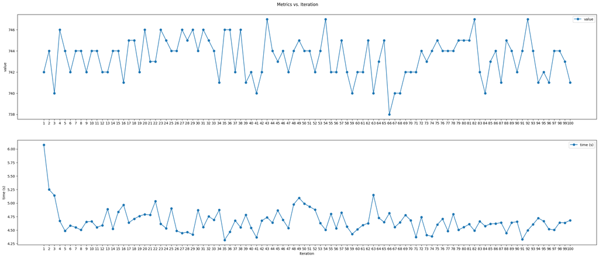

```python
metrics = [values, times]
names = ['value', 'time (s)']
fig, axs = plt.subplots(len(metrics), 1, figsize=(30, 12))
iters = np.arange(1,101)
for i, (metric, name) in enumerate(zip(metrics, names)):
    axs[i].plot(iters, metric, marker='o', label=name)
    axs[i].set_ylabel(name)
    axs[i].legend()

    # Set x-axis ticks for each subplot
    axs[i].set_xticks(iters)

plt.xlabel('Iteration')
plt.suptitle('Metrics vs. Iteration', y=0.92)
plt.show()
```

```python
mean_value = np.array(values).mean()
mean_time = np.array(times).mean()
print('mean_value : ', mean_value)
print('mean_time', mean_time)
```

```
mean_value :  743.38
mean_time 4.672689301967621
```

### Mean of ABC : 743, perhaps it depends of choosen parameters, so it is more like a global idea.

### Algorithm takes 4.7 seconds to run for these parameters.

## Try to reach a maximum value

Increase colony size and max iterations to find a potential limit of this algorithm.

```python
colony_size = 20 #number of variables to creates
max_iter = 250
limit = 30 #max trial value to reach
```

```python
start = time.time()
main_roll.reset()
abc = ABC(main_roll, colony_size, max_iter,limit)
optimal_roll, optimal_value = abc.optimize()
end = time.time()
print('elapsed time : ', end-start)
```

```
elapsed time :  42.83301115036011
```

```python
print('final result :', optimal_value)
```

```
final result : 749
```

Conclusion even if we increase parameters it doesn't allow us to necessary find a better a solution.

Moreover it increases considerably the time to run the algorithm.

So how to reach this limit ?

# Artificial Bee Algorithm, recursive version

- Now we want to apply previous algorithm but recursively
- To made this we start abc on the main roll.
- The idea is to recall abc on smaller roll (partitions of main_roll).
- Give the possibilitie to go back when you reach the smallest partitions or when you don't make improvement.
- When you apply abc on smaller partitions, limit value needs to decrease because you have less possibilities of biscuit's placements.
- minimum limit is set to 5, we had good results with this value.
- To avoid unnecessaries runs of abc algorithms, we added an attribut max_update, so when no improvements are made we decrease max_update, and if it reachs 0 we stop the algorithm.

## The main function

```python
MIN_LENGTH = 2 #length of the smallest biscuit
def abc_rec(roll,k, max_update):
    #allows to not run the algorithm when we don't find anymore improvement
    if max_update == 0:
        return
    if roll.size < MIN_LENGTH: #we now we can't place biscuit on a roll of size 1
        #we go back by choose randomly k
        return abc_rec(roll, random.randint(1, k-1), max_update)

    #more we go deeper, more we created small partitions
    min_length_base = 500//k
    min_length = random.choice([min_length_base + i for i in range(2)]) #max(random.randint(4,16), roll.size//k)
    #choose a partition of current roll to improve with abc
    current_partition_dict = roll.TournamentPartition(min_length)
    current_partition = current_partition_dict['partition']

    #compute the limit, limit decreases when we go deeper in the iteration
    limit = max(5, (max_iter//2)//k)
    abc = ABC(current_partition, colony_size, max_iter,limit)
    optimal_roll, optimal_value = abc.optimize()

    #we made an improvement
    if k == 1 or optimal_value > current_partition.value:
        #we update current roll with the new partition
        roll.updateFromPartition(optimal_roll, current_partition_dict['start'])
        return abc_rec(roll, k+1, max_update)

    #failed to improve the current partition
    max_update -= 1
    #let's give several possibilitie, in this case, either go back or move forward
    return abc_rec(roll, random.choice([k-1,k+1]), max_update)

def run_abc_rec(roll, colony_size = 5, max_iter = 50, max_update=20):
    """ function to manage recursive abc, currently it is not very use full, perhaps it allows us to add more functionnalities later """
    roll.reset()
    abc_rec(roll, 1, max_update)
```

```python
colony_size = 10
max_iter = 100
max_update= 50
start = time.time()
run_abc_rec(main_roll,colony_size, max_iter, max_update)
end = time.time()
print('elapsed time : ', end-start)
```

```
elapsed time :  407.4442865848541
```

```python
main_roll.display()
```

```
Total Value :  753
```

|  | 0 | 1 | 2 | 3 | 4 | 5 | 6 | 7 | 8 | 9 | 10 | 11 | 12 | 13 | 14 | 15 | 16 | 17 | 18 | 19 |
| --- | --- | --- | --- | --- | --- | --- | --- | --- | --- | --- | --- | --- | --- | --- | --- | --- | --- | --- | --- | --- |
| 0 | {'a': 2, 'b': 0, 'c': 0} | {'a': 1, 'b': 0, 'c': 0} | {'a': 1, 'b': 1, 'c': 0} | {'a': 1, 'b': 1, 'c': 0} | {'a': 0, 'b': 0, 'c': 0} | {'a': 0, 'b': 0, 'c': 0} | {'a': 0, 'b': 0, 'c': 0} | {'a': 0, 'b': 0, 'c': 0} | {'a': 0, 'b': 0, 'c': 1} | {'a': 0, 'b': 0, 'c': 2} | {'a': 0, 'b': 1, 'c': 1} | {'a': 0, 'b': 0, 'c': 0} | {'a': 1, 'b': 0, 'c': 0} | {'a': 0, 'b': 0, 'c': 0} | {'a': 1, 'b': 0, 'c': 0} | {'a': 0, 'b': 0, 'c': 0} | {'a': 1, 'b': 0, 'c': 1} | {'a': 0, 'b': 0, 'c': 0} | {'a': 0, 'b': 0, 'c': 0} | {'a': 0, 'b': 1, 'c': 0} |
| 1 | [1 | 1 | 1 | 1 | 1 | 1 | 1 | 1] | [1 | 1 | 1 | 1 | 1 | 1 | 1 | 1] | [0 | 0 | 0 | 0] |

|  | 20 | 21 | 22 | 23 | 24 | 25 | 26 | 27 | 28 | 29 | 30 | 31 | 32 | 33 | 34 | 35 | 36 | 37 | 38 | 39 |
| --- | --- | --- | --- | --- | --- | --- | --- | --- | --- | --- | --- | --- | --- | --- | --- | --- | --- | --- | --- | --- |
| 0 | {'a': 0, 'b': 0, 'c': 0} | {'a': 0, 'b': 1, 'c': 0} | {'a': 1, 'b': 1, 'c': 0} | {'a': 2, 'b': 0, 'c': 0} | {'a': 0, 'b': 0, 'c': 0} | {'a': 1, 'b': 0, 'c': 0} | {'a': 1, 'b': 0, 'c': 1} | {'a': 0, 'b': 0, 'c': 0} | {'a': 0, 'b': 0, 'c': 0} | {'a': 1, 'b': 0, 'c': 0} | {'a': 0, 'b': 1, 'c': 0} | {'a': 0, 'b': 0, 'c': 0} | {'a': 1, 'b': 0, 'c': 0} | {'a': 0, 'b': 1, 'c': 0} | {'a': 0, 'b': 1, 'c': 0} | {'a': 0, 'b': 1, 'c': 1} | {'a': 1, 'b': 1, 'c': 0} | {'a': 0, 'b': 1, 'c': 0} | {'a': 1, 'b': 0, 'c': 0} | {'a': 0, 'b': 0, 'c': 2} |
| 1 | [1 | 1 | 1 | 1 | 1 | 1 | 1 | 1] | [1 | 1 | 1 | 1 | 1 | 1 | 1 | 1] | [0 | 0 | 0 | 0] |

|  | 40 | 41 | 42 | 43 | 44 | 45 | 46 | 47 | 48 | 49 | 50 | 51 | 52 | 53 | 54 | 55 | 56 | 57 | 58 | 59 |
| --- | --- | --- | --- | --- | --- | --- | --- | --- | --- | --- | --- | --- | --- | --- | --- | --- | --- | --- | --- | --- |
| 0 | {'a': 0, 'b': 0, 'c': 2} | {'a': 0, 'b': 0, 'c': 1} | {'a': 0, 'b': 0, 'c': 0} | {'a': 0, 'b': 0, 'c': 0} | {'a': 1, 'b': 1, 'c': 0} | {'a': 0, 'b': 0, 'c': 0} | {'a': 1, 'b': 1, 'c': 0} | {'a': 0, 'b': 0, 'c': 1} | {'a': 1, 'b': 1, 'c': 0} | {'a': 0, 'b': 0, 'c': 1} | {'a': 0, 'b': 0, 'c': 1} | {'a': 1, 'b': 1, 'c': 2} | {'a': 0, 'b': 0, 'c': 0} | {'a': 1, 'b': 0, 'c': 0} | {'a': 0, 'b': 1, 'c': 0} | {'a': 1, 'b': 0, 'c': 1} | {'a': 0, 'b': 0, 'c': 0} | {'a': 0, 'b': 0, 'c': 1} | {'a': 1, 'b': 0, 'c': 0} | {'a': 1, 'b': 1, 'c': 2} |
| 1 | [0 | 0 | 0 | 0] | [0 | 0 | 0 | 0] | [2 | 2] | [0 | 0 | 0 | 0] | [3 | 3 | 3 | 3 | 3] | [0 |

|  | 60 | 61 | 62 | 63 | 64 | 65 | 66 | 67 | 68 | 69 | 70 | 71 | 72 | 73 | 74 | 75 | 76 | 77 | 78 | 79 |
| --- | --- | --- | --- | --- | --- | --- | --- | --- | --- | --- | --- | --- | --- | --- | --- | --- | --- | --- | --- | --- |
| 0 | {'a': 0, 'b': 0, 'c': 0} | {'a': 0, 'b': 0, 'c': 0} | {'a': 0, 'b': 0, 'c': 0} | {'a': 0, 'b': 0, 'c': 0} | {'a': 0, 'b': 0, 'c': 1} | {'a': 0, 'b': 0, 'c': 1} | {'a': 0, 'b': 0, 'c': 0} | {'a': 0, 'b': 0, 'c': 0} | {'a': 0, 'b': 1, 'c': 1} | {'a': 1, 'b': 0, 'c': 0} | {'a': 0, 'b': 0, 'c': 0} | {'a': 0, 'b': 0, 'c': 0} | {'a': 0, 'b': 2, 'c': 1} | {'a': 1, 'b': 0, 'c': 0} | {'a': 0, 'b': 0, 'c': 2} | {'a': 0, 'b': 0, 'c': 0} | {'a': 1, 'b': 0, 'c': 0} | {'a': 2, 'b': 0, 'c': 0} | {'a': 0, 'b': 0, 'c': 0} | {'a': 0, 'b': 0, 'c': 0} |
| 1 | 0 | 0 | 0] | [3 | 3 | 3 | 3 | 3] | [3 | 3 | 3 | 3 | 3] | [0 | 0 | 0 | 0] | [0 | 0 | 0 |

|  | 80 | 81 | 82 | 83 | 84 | 85 | 86 | 87 | 88 | 89 | 90 | 91 | 92 | 93 | 94 | 95 | 96 | 97 | 98 | 99 |
| --- | --- | --- | --- | --- | --- | --- | --- | --- | --- | --- | --- | --- | --- | --- | --- | --- | --- | --- | --- | --- |
| 0 | {'a': 0, 'b': 0, 'c': 0} | {'a': 0, 'b': 0, 'c': 0} | {'a': 0, 'b': 2, 'c': 1} | {'a': 1, 'b': 1, 'c': 1} | {'a': 0, 'b': 0, 'c': 1} | {'a': 2, 'b': 0, 'c': 0} | {'a': 0, 'b': 0, 'c': 0} | {'a': 0, 'b': 0, 'c': 0} | {'a': 0, 'b': 0, 'c': 0} | {'a': 0, 'b': 0, 'c': 1} | {'a': 0, 'b': 0, 'c': 0} | {'a': 0, 'b': 0, 'c': 1} | {'a': 1, 'b': 0, 'c': 0} | {'a': 2, 'b': 0, 'c': 0} | {'a': 0, 'b': 0, 'c': 1} | {'a': 1, 'b': 0, 'c': 1} | {'a': 0, 'b': 1, 'c': 0} | {'a': 0, 'b': 0, 'c': 3} | {'a': 0, 'b': 0, 'c': 2} | {'a': 0, 'b': 0, 'c': 0} |
| 1 | 0] | [1 | 1 | 1 | 1 | 1 | 1 | 1 | 1] | [0 | 0 | 0 | 0] | [0 | 0 | 0 | 0] | _ | [0 | 0 |

|  | 100 | 101 | 102 | 103 | 104 | 105 | 106 | 107 | 108 | 109 | 110 | 111 | 112 | 113 | 114 | 115 | 116 | 117 | 118 | 119 |
| --- | --- | --- | --- | --- | --- | --- | --- | --- | --- | --- | --- | --- | --- | --- | --- | --- | --- | --- | --- | --- |
| 0 | {'a': 0, 'b': 0, 'c': 0} | {'a': 0, 'b': 0, 'c': 0} | {'a': 0, 'b': 0, 'c': 1} | {'a': 1, 'b': 0, 'c': 0} | {'a': 0, 'b': 0, 'c': 0} | {'a': 0, 'b': 0, 'c': 0} | {'a': 0, 'b': 0, 'c': 0} | {'a': 1, 'b': 1, 'c': 1} | {'a': 1, 'b': 0, 'c': 0} | {'a': 0, 'b': 0, 'c': 0} | {'a': 0, 'b': 0, 'c': 2} | {'a': 0, 'b': 0, 'c': 0} | {'a': 1, 'b': 0, 'c': 0} | {'a': 0, 'b': 0, 'c': 2} | {'a': 0, 'b': 0, 'c': 0} | {'a': 0, 'b': 0, 'c': 1} | {'a': 1, 'b': 1, 'c': 1} | {'a': 2, 'b': 1, 'c': 0} | {'a': 2, 'b': 0, 'c': 0} | {'a': 1, 'b': 0, 'c': 0} |
| 1 | 0 | 0] | [0 | 0 | 0 | 0] | [2 | 2] | [3 | 3 | 3 | 3 | 3] | _ | [0 | 0 | 0 | 0] | [0 | 0 |

|  | 120 | 121 | 122 | 123 | 124 | 125 | 126 | 127 | 128 | 129 | 130 | 131 | 132 | 133 | 134 | 135 | 136 | 137 | 138 | 139 |
| --- | --- | --- | --- | --- | --- | --- | --- | --- | --- | --- | --- | --- | --- | --- | --- | --- | --- | --- | --- | --- |
| 0 | {'a': 0, 'b': 0, 'c': 1} | {'a': 0, 'b': 0, 'c': 1} | {'a': 0, 'b': 1, 'c': 0} | {'a': 0, 'b': 1, 'c': 1} | {'a': 1, 'b': 0, 'c': 0} | {'a': 3, 'b': 0, 'c': 1} | {'a': 0, 'b': 0, 'c': 0} | {'a': 0, 'b': 1, 'c': 0} | {'a': 0, 'b': 0, 'c': 1} | {'a': 0, 'b': 1, 'c': 1} | {'a': 0, 'b': 0, 'c': 0} | {'a': 0, 'b': 0, 'c': 0} | {'a': 0, 'b': 0, 'c': 0} | {'a': 0, 'b': 0, 'c': 0} | {'a': 0, 'b': 0, 'c': 0} | {'a': 0, 'b': 0, 'c': 0} | {'a': 0, 'b': 0, 'c': 1} | {'a': 0, 'b': 0, 'c': 1} | {'a': 0, 'b': 0, 'c': 0} | {'a': 0, 'b': 1, 'c': 1} |
| 1 | 0 | 0] | [1 | 1 | 1 | 1 | 1 | 1 | 1 | 1] | [3 | 3 | 3 | 3 | 3] | [0 | 0 | 0 | 0] | [0 |

|  | 140 | 141 | 142 | 143 | 144 | 145 | 146 | 147 | 148 | 149 | 150 | 151 | 152 | 153 | 154 | 155 | 156 | 157 | 158 | 159 |
| --- | --- | --- | --- | --- | --- | --- | --- | --- | --- | --- | --- | --- | --- | --- | --- | --- | --- | --- | --- | --- |
| 0 | {'a': 1, 'b': 0, 'c': 0} | {'a': 0, 'b': 1, 'c': 1} | {'a': 0, 'b': 0, 'c': 1} | {'a': 2, 'b': 0, 'c': 1} | {'a': 1, 'b': 0, 'c': 0} | {'a': 0, 'b': 0, 'c': 1} | {'a': 0, 'b': 1, 'c': 1} | {'a': 0, 'b': 0, 'c': 0} | {'a': 0, 'b': 1, 'c': 0} | {'a': 0, 'b': 0, 'c': 1} | {'a': 0, 'b': 0, 'c': 1} | {'a': 0, 'b': 0, 'c': 0} | {'a': 0, 'b': 0, 'c': 0} | {'a': 0, 'b': 1, 'c': 0} | {'a': 1, 'b': 1, 'c': 1} | {'a': 0, 'b': 0, 'c': 0} | {'a': 1, 'b': 1, 'c': 0} | {'a': 0, 'b': 3, 'c': 0} | {'a': 1, 'b': 0, 'c': 0} | {'a': 1, 'b': 0, 'c': 1} |
| 1 | 0 | 0 | 0] | [0 | 0 | 0 | 0] | [3 | 3 | 3 | 3 | 3] | [3 | 3 | 3 | 3 | 3] | _ | [0 | 0 |

|  | 160 | 161 | 162 | 163 | 164 | 165 | 166 | 167 | 168 | 169 | 170 | 171 | 172 | 173 | 174 | 175 | 176 | 177 | 178 | 179 |
| --- | --- | --- | --- | --- | --- | --- | --- | --- | --- | --- | --- | --- | --- | --- | --- | --- | --- | --- | --- | --- |
| 0 | {'a': 0, 'b': 0, 'c': 0} | {'a': 0, 'b': 1, 'c': 0} | {'a': 0, 'b': 0, 'c': 0} | {'a': 3, 'b': 1, 'c': 1} | {'a': 0, 'b': 0, 'c': 0} | {'a': 0, 'b': 0, 'c': 1} | {'a': 1, 'b': 3, 'c': 0} | {'a': 0, 'b': 0, 'c': 0} | {'a': 0, 'b': 2, 'c': 0} | {'a': 1, 'b': 0, 'c': 0} | {'a': 0, 'b': 0, 'c': 0} | {'a': 1, 'b': 1, 'c': 1} | {'a': 1, 'b': 0, 'c': 1} | {'a': 0, 'b': 1, 'c': 0} | {'a': 0, 'b': 0, 'c': 1} | {'a': 0, 'b': 0, 'c': 0} | {'a': 0, 'b': 1, 'c': 0} | {'a': 0, 'b': 0, 'c': 0} | {'a': 0, 'b': 0, 'c': 2} | {'a': 0, 'b': 2, 'c': 1} |
| 1 | 0 | 0] | [0 | 0 | 0 | 0] | _ | [1 | 1 | 1 | 1 | 1 | 1 | 1 | 1] | [0 | 0 | 0 | 0] | [3 |

|  | 180 | 181 | 182 | 183 | 184 | 185 | 186 | 187 | 188 | 189 | 190 | 191 | 192 | 193 | 194 | 195 | 196 | 197 | 198 | 199 |
| --- | --- | --- | --- | --- | --- | --- | --- | --- | --- | --- | --- | --- | --- | --- | --- | --- | --- | --- | --- | --- |
| 0 | {'a': 0, 'b': 0, 'c': 0} | {'a': 0, 'b': 0, 'c': 0} | {'a': 0, 'b': 0, 'c': 0} | {'a': 0, 'b': 0, 'c': 1} | {'a': 0, 'b': 3, 'c': 3} | {'a': 0, 'b': 1, 'c': 0} | {'a': 0, 'b': 1, 'c': 0} | {'a': 0, 'b': 1, 'c': 0} | {'a': 3, 'b': 0, 'c': 0} | {'a': 1, 'b': 0, 'c': 0} | {'a': 1, 'b': 1, 'c': 0} | {'a': 0, 'b': 1, 'c': 1} | {'a': 0, 'b': 1, 'c': 0} | {'a': 0, 'b': 0, 'c': 0} | {'a': 0, 'b': 0, 'c': 1} | {'a': 0, 'b': 0, 'c': 0} | {'a': 0, 'b': 0, 'c': 1} | {'a': 0, 'b': 0, 'c': 0} | {'a': 0, 'b': 0, 'c': 1} | {'a': 0, 'b': 0, 'c': 0} |
| 1 | 3 | 3 | 3 | 3] | _ | [2 | 2] | [1 | 1 | 1 | 1 | 1 | 1 | 1 | 1] | [3 | 3 | 3 | 3 | 3] |

|  | 200 | 201 | 202 | 203 | 204 | 205 | 206 | 207 | 208 | 209 | 210 | 211 | 212 | 213 | 214 | 215 | 216 | 217 | 218 | 219 |
| --- | --- | --- | --- | --- | --- | --- | --- | --- | --- | --- | --- | --- | --- | --- | --- | --- | --- | --- | --- | --- |
| 0 | {'a': 0, 'b': 1, 'c': 0} | {'a': 0, 'b': 0, 'c': 1} | {'a': 0, 'b': 0, 'c': 0} | {'a': 1, 'b': 0, 'c': 1} | {'a': 0, 'b': 0, 'c': 0} | {'a': 2, 'b': 0, 'c': 0} | {'a': 0, 'b': 0, 'c': 1} | {'a': 0, 'b': 0, 'c': 0} | {'a': 0, 'b': 0, 'c': 0} | {'a': 0, 'b': 1, 'c': 1} | {'a': 0, 'b': 0, 'c': 1} | {'a': 0, 'b': 0, 'c': 0} | {'a': 1, 'b': 0, 'c': 0} | {'a': 0, 'b': 1, 'c': 0} | {'a': 1, 'b': 1, 'c': 1} | {'a': 0, 'b': 0, 'c': 0} | {'a': 1, 'b': 1, 'c': 1} | {'a': 0, 'b': 0, 'c': 0} | {'a': 1, 'b': 0, 'c': 0} | {'a': 0, 'b': 0, 'c': 0} |
| 1 | [3 | 3 | 3 | 3 | 3] | [0 | 0 | 0 | 0] | [3 | 3 | 3 | 3 | 3] | [0 | 0 | 0 | 0] | [3 | 3 |

|  | 220 | 221 | 222 | 223 | 224 | 225 | 226 | 227 | 228 | 229 | 230 | 231 | 232 | 233 | 234 | 235 | 236 | 237 | 238 | 239 |
| --- | --- | --- | --- | --- | --- | --- | --- | --- | --- | --- | --- | --- | --- | --- | --- | --- | --- | --- | --- | --- |
| 0 | {'a': 0, 'b': 0, 'c': 0} | {'a': 0, 'b': 1, 'c': 0} | {'a': 0, 'b': 0, 'c': 0} | {'a': 1, 'b': 0, 'c': 0} | {'a': 0, 'b': 0, 'c': 0} | {'a': 0, 'b': 0, 'c': 0} | {'a': 0, 'b': 0, 'c': 0} | {'a': 1, 'b': 1, 'c': 0} | {'a': 0, 'b': 0, 'c': 1} | {'a': 0, 'b': 0, 'c': 0} | {'a': 1, 'b': 0, 'c': 0} | {'a': 0, 'b': 0, 'c': 1} | {'a': 0, 'b': 0, 'c': 0} | {'a': 0, 'b': 0, 'c': 0} | {'a': 0, 'b': 1, 'c': 1} | {'a': 0, 'b': 1, 'c': 0} | {'a': 0, 'b': 0, 'c': 0} | {'a': 0, 'b': 0, 'c': 0} | {'a': 0, 'b': 0, 'c': 0} | {'a': 0, 'b': 0, 'c': 0} |
| 1 | 3 | 3 | 3] | [3 | 3 | 3 | 3 | 3] | [3 | 3 | 3 | 3 | 3] | [0 | 0 | 0 | 0] | [3 | 3 | 3 |

|  | 240 | 241 | 242 | 243 | 244 | 245 | 246 | 247 | 248 | 249 | 250 | 251 | 252 | 253 | 254 | 255 | 256 | 257 | 258 | 259 |
| --- | --- | --- | --- | --- | --- | --- | --- | --- | --- | --- | --- | --- | --- | --- | --- | --- | --- | --- | --- | --- |
| 0 | {'a': 0, 'b': 0, 'c': 1} | {'a': 0, 'b': 3, 'c': 1} | {'a': 3, 'b': 1, 'c': 0} | {'a': 0, 'b': 0, 'c': 0} | {'a': 0, 'b': 0, 'c': 1} | {'a': 0, 'b': 1, 'c': 0} | {'a': 1, 'b': 0, 'c': 1} | {'a': 0, 'b': 0, 'c': 1} | {'a': 0, 'b': 1, 'c': 1} | {'a': 0, 'b': 0, 'c': 0} | {'a': 0, 'b': 0, 'c': 0} | {'a': 1, 'b': 1, 'c': 0} | {'a': 0, 'b': 0, 'c': 0} | {'a': 1, 'b': 0, 'c': 1} | {'a': 0, 'b': 0, 'c': 0} | {'a': 0, 'b': 0, 'c': 1} | {'a': 0, 'b': 0, 'c': 0} | {'a': 0, 'b': 1, 'c': 1} | {'a': 0, 'b': 1, 'c': 0} | {'a': 0, 'b': 1, 'c': 0} |
| 1 | 3 | 3] | [1 | 1 | 1 | 1 | 1 | 1 | 1 | 1] | [3 | 3 | 3 | 3 | 3] | [0 | 0 | 0 | 0] | [3 |

|  | 260 | 261 | 262 | 263 | 264 | 265 | 266 | 267 | 268 | 269 | 270 | 271 | 272 | 273 | 274 | 275 | 276 | 277 | 278 | 279 |
| --- | --- | --- | --- | --- | --- | --- | --- | --- | --- | --- | --- | --- | --- | --- | --- | --- | --- | --- | --- | --- |
| 0 | {'a': 0, 'b': 0, 'c': 1} | {'a': 0, 'b': 0, 'c': 0} | {'a': 0, 'b': 0, 'c': 0} | {'a': 0, 'b': 0, 'c': 0} | {'a': 0, 'b': 0, 'c': 1} | {'a': 0, 'b': 0, 'c': 1} | {'a': 0, 'b': 0, 'c': 0} | {'a': 0, 'b': 1, 'c': 0} | {'a': 0, 'b': 0, 'c': 0} | {'a': 0, 'b': 1, 'c': 0} | {'a': 1, 'b': 1, 'c': 0} | {'a': 0, 'b': 0, 'c': 0} | {'a': 0, 'b': 1, 'c': 0} | {'a': 0, 'b': 0, 'c': 1} | {'a': 0, 'b': 0, 'c': 0} | {'a': 2, 'b': 2, 'c': 0} | {'a': 1, 'b': 0, 'c': 0} | {'a': 1, 'b': 0, 'c': 1} | {'a': 0, 'b': 0, 'c': 0} | {'a': 1, 'b': 0, 'c': 1} |
| 1 | 3 | 3 | 3 | 3] | [0 | 0 | 0 | 0] | [0 | 0 | 0 | 0] | [1 | 1 | 1 | 1 | 1 | 1 | 1 | 1] |

|  | 280 | 281 | 282 | 283 | 284 | 285 | 286 | 287 | 288 | 289 | 290 | 291 | 292 | 293 | 294 | 295 | 296 | 297 | 298 | 299 |
| --- | --- | --- | --- | --- | --- | --- | --- | --- | --- | --- | --- | --- | --- | --- | --- | --- | --- | --- | --- | --- |
| 0 | {'a': 2, 'b': 0, 'c': 0} | {'a': 0, 'b': 1, 'c': 0} | {'a': 0, 'b': 0, 'c': 1} | {'a': 0, 'b': 0, 'c': 1} | {'a': 1, 'b': 1, 'c': 0} | {'a': 0, 'b': 1, 'c': 0} | {'a': 0, 'b': 0, 'c': 0} | {'a': 0, 'b': 0, 'c': 0} | {'a': 1, 'b': 0, 'c': 0} | {'a': 1, 'b': 1, 'c': 0} | {'a': 0, 'b': 0, 'c': 0} | {'a': 0, 'b': 1, 'c': 0} | {'a': 0, 'b': 1, 'c': 1} | {'a': 0, 'b': 1, 'c': 1} | {'a': 1, 'b': 2, 'c': 0} | {'a': 0, 'b': 0, 'c': 0} | {'a': 0, 'b': 1, 'c': 0} | {'a': 0, 'b': 0, 'c': 0} | {'a': 0, 'b': 0, 'c': 0} | {'a': 0, 'b': 0, 'c': 1} |
| 1 | [1 | 1 | 1 | 1 | 1 | 1 | 1 | 1] | [3 | 3 | 3 | 3 | 3] | [1 | 1 | 1 | 1 | 1 | 1 | 1 |

|  | 300 | 301 | 302 | 303 | 304 | 305 | 306 | 307 | 308 | 309 | 310 | 311 | 312 | 313 | 314 | 315 | 316 | 317 | 318 | 319 |
| --- | --- | --- | --- | --- | --- | --- | --- | --- | --- | --- | --- | --- | --- | --- | --- | --- | --- | --- | --- | --- |
| 0 | {'a': 0, 'b': 0, 'c': 1} | {'a': 1, 'b': 1, 'c': 1} | {'a': 1, 'b': 1, 'c': 0} | {'a': 0, 'b': 0, 'c': 0} | {'a': 1, 'b': 1, 'c': 1} | {'a': 0, 'b': 0, 'c': 0} | {'a': 0, 'b': 0, 'c': 1} | {'a': 0, 'b': 0, 'c': 0} | {'a': 0, 'b': 0, 'c': 1} | {'a': 0, 'b': 0, 'c': 0} | {'a': 0, 'b': 1, 'c': 0} | {'a': 0, 'b': 0, 'c': 1} | {'a': 0, 'b': 0, 'c': 1} | {'a': 1, 'b': 0, 'c': 0} | {'a': 2, 'b': 0, 'c': 0} | {'a': 0, 'b': 1, 'c': 0} | {'a': 0, 'b': 0, 'c': 1} | {'a': 0, 'b': 0, 'c': 1} | {'a': 0, 'b': 0, 'c': 1} | {'a': 0, 'b': 0, 'c': 0} |
| 1 | 1] | [1 | 1 | 1 | 1 | 1 | 1 | 1 | 1] | [3 | 3 | 3 | 3 | 3] | [1 | 1 | 1 | 1 | 1 | 1 |

|  | 320 | 321 | 322 | 323 | 324 | 325 | 326 | 327 | 328 | 329 | 330 | 331 | 332 | 333 | 334 | 335 | 336 | 337 | 338 | 339 |
| --- | --- | --- | --- | --- | --- | --- | --- | --- | --- | --- | --- | --- | --- | --- | --- | --- | --- | --- | --- | --- |
| 0 | {'a': 0, 'b': 0, 'c': 0} | {'a': 0, 'b': 1, 'c': 0} | {'a': 0, 'b': 0, 'c': 0} | {'a': 0, 'b': 0, 'c': 0} | {'a': 0, 'b': 1, 'c': 0} | {'a': 0, 'b': 0, 'c': 0} | {'a': 0, 'b': 0, 'c': 0} | {'a': 0, 'b': 0, 'c': 0} | {'a': 0, 'b': 0, 'c': 1} | {'a': 1, 'b': 0, 'c': 0} | {'a': 1, 'b': 0, 'c': 0} | {'a': 0, 'b': 0, 'c': 0} | {'a': 1, 'b': 2, 'c': 0} | {'a': 0, 'b': 0, 'c': 0} | {'a': 1, 'b': 1, 'c': 0} | {'a': 0, 'b': 1, 'c': 0} | {'a': 0, 'b': 0, 'c': 0} | {'a': 0, 'b': 0, 'c': 0} | {'a': 0, 'b': 1, 'c': 0} | {'a': 0, 'b': 0, 'c': 0} |
| 1 | 1 | 1] | [0 | 0 | 0 | 0] | [0 | 0 | 0 | 0] | [0 | 0 | 0 | 0] | [0 | 0 | 0 | 0] | [3 | 3 |

|  | 340 | 341 | 342 | 343 | 344 | 345 | 346 | 347 | 348 | 349 | 350 | 351 | 352 | 353 | 354 | 355 | 356 | 357 | 358 | 359 |
| --- | --- | --- | --- | --- | --- | --- | --- | --- | --- | --- | --- | --- | --- | --- | --- | --- | --- | --- | --- | --- |
| 0 | {'a': 1, 'b': 0, 'c': 0} | {'a': 0, 'b': 0, 'c': 0} | {'a': 0, 'b': 0, 'c': 2} | {'a': 0, 'b': 0, 'c': 0} | {'a': 0, 'b': 1, 'c': 0} | {'a': 0, 'b': 0, 'c': 1} | {'a': 0, 'b': 0, 'c': 0} | {'a': 0, 'b': 1, 'c': 1} | {'a': 1, 'b': 0, 'c': 0} | {'a': 0, 'b': 0, 'c': 0} | {'a': 0, 'b': 0, 'c': 1} | {'a': 0, 'b': 1, 'c': 1} | {'a': 0, 'b': 1, 'c': 0} | {'a': 0, 'b': 1, 'c': 0} | {'a': 0, 'b': 0, 'c': 1} | {'a': 0, 'b': 1, 'c': 2} | {'a': 1, 'b': 0, 'c': 0} | {'a': 0, 'b': 1, 'c': 1} | {'a': 0, 'b': 1, 'c': 0} | {'a': 0, 'b': 0, 'c': 0} |
| 1 | 3 | 3 | 3] | [3 | 3 | 3 | 3 | 3] | [3 | 3 | 3 | 3 | 3] | [0 | 0 | 0 | 0] | [3 | 3 | 3 |

|  | 360 | 361 | 362 | 363 | 364 | 365 | 366 | 367 | 368 | 369 | 370 | 371 | 372 | 373 | 374 | 375 | 376 | 377 | 378 | 379 |
| --- | --- | --- | --- | --- | --- | --- | --- | --- | --- | --- | --- | --- | --- | --- | --- | --- | --- | --- | --- | --- |
| 0 | {'a': 0, 'b': 1, 'c': 0} | {'a': 0, 'b': 0, 'c': 0} | {'a': 1, 'b': 0, 'c': 1} | {'a': 0, 'b': 1, 'c': 0} | {'a': 1, 'b': 0, 'c': 0} | {'a': 1, 'b': 0, 'c': 0} | {'a': 0, 'b': 0, 'c': 0} | {'a': 1, 'b': 0, 'c': 1} | {'a': 2, 'b': 0, 'c': 0} | {'a': 1, 'b': 0, 'c': 0} | {'a': 0, 'b': 0, 'c': 1} | {'a': 1, 'b': 1, 'c': 0} | {'a': 0, 'b': 0, 'c': 1} | {'a': 1, 'b': 0, 'c': 1} | {'a': 0, 'b': 0, 'c': 1} | {'a': 0, 'b': 0, 'c': 1} | {'a': 0, 'b': 0, 'c': 1} | {'a': 0, 'b': 1, 'c': 0} | {'a': 0, 'b': 0, 'c': 0} | {'a': 0, 'b': 1, 'c': 0} |
| 1 | 3 | 3] | [0 | 0 | 0 | 0] | [0 | 0 | 0 | 0] | [0 | 0 | 0 | 0] | [1 | 1 | 1 | 1 | 1 | 1 |

|  | 380 | 381 | 382 | 383 | 384 | 385 | 386 | 387 | 388 | 389 | 390 | 391 | 392 | 393 | 394 | 395 | 396 | 397 | 398 | 399 |
| --- | --- | --- | --- | --- | --- | --- | --- | --- | --- | --- | --- | --- | --- | --- | --- | --- | --- | --- | --- | --- |
| 0 | {'a': 1, 'b': 0, 'c': 0} | {'a': 0, 'b': 1, 'c': 1} | {'a': 0, 'b': 1, 'c': 0} | {'a': 0, 'b': 1, 'c': 2} | {'a': 0, 'b': 0, 'c': 0} | {'a': 1, 'b': 0, 'c': 0} | {'a': 0, 'b': 2, 'c': 0} | {'a': 0, 'b': 0, 'c': 0} | {'a': 0, 'b': 0, 'c': 0} | {'a': 0, 'b': 0, 'c': 0} | {'a': 0, 'b': 0, 'c': 1} | {'a': 1, 'b': 1, 'c': 0} | {'a': 1, 'b': 0, 'c': 0} | {'a': 0, 'b': 0, 'c': 0} | {'a': 0, 'b': 0, 'c': 0} | {'a': 0, 'b': 1, 'c': 1} | {'a': 0, 'b': 0, 'c': 0} | {'a': 0, 'b': 0, 'c': 0} | {'a': 0, 'b': 1, 'c': 0} | {'a': 0, 'b': 0, 'c': 0} |
| 1 | 1 | 1] | [0 | 0 | 0 | 0] | [3 | 3 | 3 | 3 | 3] | [3 | 3 | 3 | 3 | 3] | [1 | 1 | 1 | 1 |

|  | 400 | 401 | 402 | 403 | 404 | 405 | 406 | 407 | 408 | 409 | 410 | 411 | 412 | 413 | 414 | 415 | 416 | 417 | 418 | 419 |
| --- | --- | --- | --- | --- | --- | --- | --- | --- | --- | --- | --- | --- | --- | --- | --- | --- | --- | --- | --- | --- |
| 0 | {'a': 0, 'b': 0, 'c': 0} | {'a': 0, 'b': 1, 'c': 2} | {'a': 0, 'b': 0, 'c': 1} | {'a': 0, 'b': 1, 'c': 0} | {'a': 0, 'b': 0, 'c': 0} | {'a': 1, 'b': 1, 'c': 0} | {'a': 1, 'b': 0, 'c': 1} | {'a': 0, 'b': 0, 'c': 0} | {'a': 1, 'b': 0, 'c': 1} | {'a': 1, 'b': 0, 'c': 0} | {'a': 0, 'b': 2, 'c': 0} | {'a': 0, 'b': 0, 'c': 0} | {'a': 0, 'b': 1, 'c': 1} | {'a': 0, 'b': 1, 'c': 0} | {'a': 1, 'b': 0, 'c': 0} | {'a': 0, 'b': 0, 'c': 1} | {'a': 1, 'b': 0, 'c': 0} | {'a': 0, 'b': 0, 'c': 0} | {'a': 0, 'b': 1, 'c': 0} | {'a': 0, 'b': 0, 'c': 0} |
| 1 | 1 | 1 | 1 | 1] | [1 | 1 | 1 | 1 | 1 | 1 | 1 | 1] | [3 | 3 | 3 | 3 | 3] | [3 | 3 | 3 |

|  | 420 | 421 | 422 | 423 | 424 | 425 | 426 | 427 | 428 | 429 | 430 | 431 | 432 | 433 | 434 | 435 | 436 | 437 | 438 | 439 |
| --- | --- | --- | --- | --- | --- | --- | --- | --- | --- | --- | --- | --- | --- | --- | --- | --- | --- | --- | --- | --- |
| 0 | {'a': 0, 'b': 0, 'c': 0} | {'a': 0, 'b': 2, 'c': 0} | {'a': 0, 'b': 0, 'c': 1} | {'a': 0, 'b': 0, 'c': 0} | {'a': 0, 'b': 0, 'c': 1} | {'a': 0, 'b': 0, 'c': 0} | {'a': 2, 'b': 1, 'c': 0} | {'a': 0, 'b': 0, 'c': 2} | {'a': 0, 'b': 0, 'c': 0} | {'a': 1, 'b': 1, 'c': 0} | {'a': 1, 'b': 0, 'c': 0} | {'a': 1, 'b': 0, 'c': 1} | {'a': 0, 'b': 0, 'c': 0} | {'a': 0, 'b': 0, 'c': 2} | {'a': 0, 'b': 0, 'c': 0} | {'a': 0, 'b': 0, 'c': 1} | {'a': 0, 'b': 1, 'c': 0} | {'a': 1, 'b': 0, 'c': 1} | {'a': 2, 'b': 0, 'c': 0} | {'a': 0, 'b': 1, 'c': 0} |
| 1 | 3 | 3] | [3 | 3 | 3 | 3 | 3] | [0 | 0 | 0 | 0] | [0 | 0 | 0 | 0] | [0 | 0 | 0 | 0] | [1 |

|  | 440 | 441 | 442 | 443 | 444 | 445 | 446 | 447 | 448 | 449 | 450 | 451 | 452 | 453 | 454 | 455 | 456 | 457 | 458 | 459 |
| --- | --- | --- | --- | --- | --- | --- | --- | --- | --- | --- | --- | --- | --- | --- | --- | --- | --- | --- | --- | --- |
| 0 | {'a': 1, 'b': 0, 'c': 0} | {'a': 0, 'b': 0, 'c': 0} | {'a': 0, 'b': 0, 'c': 0} | {'a': 1, 'b': 0, 'c': 0} | {'a': 0, 'b': 1, 'c': 1} | {'a': 1, 'b': 0, 'c': 0} | {'a': 2, 'b': 1, 'c': 0} | {'a': 0, 'b': 0, 'c': 1} | {'a': 0, 'b': 0, 'c': 0} | {'a': 1, 'b': 0, 'c': 0} | {'a': 0, 'b': 0, 'c': 0} | {'a': 0, 'b': 0, 'c': 1} | {'a': 0, 'b': 0, 'c': 0} | {'a': 1, 'b': 0, 'c': 0} | {'a': 0, 'b': 0, 'c': 0} | {'a': 0, 'b': 0, 'c': 0} | {'a': 1, 'b': 1, 'c': 1} | {'a': 1, 'b': 0, 'c': 0} | {'a': 0, 'b': 0, 'c': 0} | {'a': 0, 'b': 0, 'c': 0} |
| 1 | 1 | 1 | 1 | 1 | 1 | 1 | 1] | [3 | 3 | 3 | 3 | 3] | [3 | 3 | 3 | 3 | 3] | [3 | 3 | 3 |

|  | 460 | 461 | 462 | 463 | 464 | 465 | 466 | 467 | 468 | 469 | 470 | 471 | 472 | 473 | 474 | 475 | 476 | 477 | 478 | 479 |
| --- | --- | --- | --- | --- | --- | --- | --- | --- | --- | --- | --- | --- | --- | --- | --- | --- | --- | --- | --- | --- |
| 0 | {'a': 0, 'b': 0, 'c': 1} | {'a': 0, 'b': 0, 'c': 0} | {'a': 1, 'b': 0, 'c': 0} | {'a': 0, 'b': 0, 'c': 0} | {'a': 1, 'b': 0, 'c': 0} | {'a': 0, 'b': 0, 'c': 0} | {'a': 0, 'b': 0, 'c': 0} | {'a': 0, 'b': 0, 'c': 0} | {'a': 0, 'b': 0, 'c': 0} | {'a': 1, 'b': 1, 'c': 1} | {'a': 0, 'b': 0, 'c': 0} | {'a': 0, 'b': 0, 'c': 1} | {'a': 0, 'b': 1, 'c': 0} | {'a': 0, 'b': 0, 'c': 0} | {'a': 0, 'b': 0, 'c': 0} | {'a': 1, 'b': 1, 'c': 0} | {'a': 0, 'b': 0, 'c': 1} | {'a': 1, 'b': 0, 'c': 0} | {'a': 2, 'b': 0, 'c': 0} | {'a': 0, 'b': 0, 'c': 1} |
| 1 | 3 | 3] | [3 | 3 | 3 | 3 | 3] | [3 | 3 | 3 | 3 | 3] | [1 | 1 | 1 | 1 | 1 | 1 | 1 | 1] |

|  | 480 | 481 | 482 | 483 | 484 | 485 | 486 | 487 | 488 | 489 | 490 | 491 | 492 | 493 | 494 | 495 | 496 | 497 | 498 | 499 |
| --- | --- | --- | --- | --- | --- | --- | --- | --- | --- | --- | --- | --- | --- | --- | --- | --- | --- | --- | --- | --- |
| 0 | {'a': 0, 'b': 1, 'c': 1} | {'a': 1, 'b': 0, 'c': 0} | {'a': 1, 'b': 1, 'c': 0} | {'a': 1, 'b': 0, 'c': 2} | {'a': 2, 'b': 2, 'c': 0} | {'a': 0, 'b': 0, 'c': 0} | {'a': 0, 'b': 0, 'c': 0} | {'a': 0, 'b': 0, 'c': 1} | {'a': 1, 'b': 0, 'c': 0} | {'a': 1, 'b': 0, 'c': 0} | {'a': 0, 'b': 0, 'c': 1} | {'a': 0, 'b': 1, 'c': 0} | {'a': 0, 'b': 1, 'c': 0} | {'a': 0, 'b': 1, 'c': 0} | {'a': 0, 'b': 0, 'c': 0} | {'a': 0, 'b': 0, 'c': 0} | {'a': 1, 'b': 1, 'c': 0} | {'a': 1, 'b': 0, 'c': 0} | {'a': 0, 'b': 0, 'c': 1} | {'a': 0, 'b': 0, 'c': 1} |
| 1 | [1 | 1 | 1 | 1 | 1 | 1 | 1 | 1] | [1 | 1 | 1 | 1 | 1 | 1 | 1 | 1] | [0 | 0 | 0 | 0] |

### Conclusion, with this method we can reach a great value.

### Perhaps, complexitie time increases a lot !